# Analysis using 3 datasets

2026-06-03

# Does Imipenem-cilastatin less develop/worsen AKI than other carbapenems?

**__**

- Patients in MIMIC3, MIMIC4, AUMC
- Those treated with imipenem/cilastatin (I/C group) vs non-cilastatin carbapenems (NCC group)
- Primary outcome is development or progression of AKI (compare AKI stage at treatment start and after treatment start)
- Using propensity score overlap weighting to adjust patients backgrounds.
- Using random mixed effect meta-analysis to combine the results of each dataset.

__

## Results (background and outcomes)

_

### **1. Backgrounds and outcome development of the patients (before matching)**

Patient characteristics and outcome development in 7 days.

“O,” are the outcomes. **Primary outcome is “AKI development or progression”**

```r
library(cobalt) #install.packages("cobalt")
library(pROC)
library(MatchIt) #install.packages("MatchIt")
library(tidyverse)
SELECTS <- c("dataset", "age_cat", "age_group", "sex", "bmi","drug_type", "Imipenem.Cilastatin", "Imipenem.Cilastatin.Relebactam", "time_switch_group", "dep_type",  "time_ICUadmit_to_abx", "pre_blood_culture", "treat_van","vasopressor", "ventilation", "sofa","qsofa", "sirs", "sep3", "base_crea", "near_crea","base_KDIGO", "obs_period", "base_KDIGO_dial", "base_KDIGO_dial", "outcome_KDIGO", "outcome_new_dial", "outcome_KDIGO_inc", "death_in_7d", "outcome_KDIGO_inc_or_death",  "outcome_max_crea_ratio", "outcome_max_crea_diff", "death_in_hosp", "drug") #"ph_htn", "ph_dm", "ph_chf", "ph_ckd", "Meropenem", "Doripenem", "Ertapenem", "los_icu",

comb_DF <- rbind(
  read.csv("MDF_mimic3.csv") %>% mutate(dataset="MIMIC3", cardiac_surgery=T) %>% dplyr::select(SELECTS, hadm_id) %>% rename("ID"=hadm_id),
  read.csv("MDF_aumc.csv") %>% mutate(dataset="AUMC", ph_htn=NA, ph_dm=NA, ph_chf=NA, ph_ckd=NA) %>% dplyr::select(SELECTS, icustay_id) %>% rename("ID"=icustay_id)
  ) %>%
  rbind(
  read.csv("MDF_miiv.csv") %>% mutate(dataset="miiv") %>% dplyr::select(SELECTS, hadm_id) %>% rename("ID"=hadm_id)
  )

comb_DF$base_KDIGO_dial <- ifelse(is.na(comb_DF$base_KDIGO_dial), F,
                                  ifelse(comb_DF$base_KDIGO_dial>0.5, T, F))
comb_DF$dep_type2 <- ifelse(is.na(comb_DF$dep_type), "Non-surgery", ifelse(comb_DF$dep_type=="surg", "Surgery", "Non-surgery"))
comb_DF$drug_type <- ifelse(comb_DF$drug_type=="IMI", "I/C", "NCC")
comb_DF$sep3 <- ifelse(is.na(comb_DF$sep3), F, ifelse(comb_DF$sep3==T, T, F))
comb_DF$drug01 <- ifelse(comb_DF$drug_type=="I/C", 1 , 0) #convert to 0/1 for matching
comb_DF$drug10 <- ifelse(comb_DF$drug_type=="I/C", 0 , 1)
comb_DF$drug_switch <- ifelse(comb_DF$time_switch_group<168, T, F)
comb_DF$outcome_HDD_in7d <- ifelse(comb_DF$outcome_new_dial==T, T,
                                   ifelse(comb_DF$death_in_7d==T, T, F))
comb_DF$drug_name <- ifelse(grepl("relebactam", comb_DF$drug), "Imipenem/cilastatin/relebactam",
                      ifelse(grepl("rtapenem", comb_DF$drug), "Ertapenem",
                       ifelse(grepl("Doripenem", comb_DF$drug), "Doripenem",
                        ifelse(grepl("mipenem", comb_DF$drug), "Imipenem/cilastatin",
                         ifelse(grepl("eropenem", comb_DF$drug), "Meropenem", F))))) %>% factor(levels = c("Imipenem/cilastatin", "Imipenem/cilastatin/relebactam","Meropenem", "Doripenem", "Ertapenem"))

library(gtsummary) #install.packages("tableone")
VARS <-c("dataset","age_group", "sex", "bmi",  "dep_type2", "drug_name","sofa", "qsofa", "sirs",  "pre_blood_culture", "treat_van","vasopressor", "ventilation","base_crea", "near_crea","base_KDIGO", "obs_period", "drug_switch","base_KDIGO_dial", "outcome_KDIGO_inc", "death_in_7d", "outcome_KDIGO_inc_or_death", "outcome_new_dial", "outcome_HDD_in7d") #"ph_htn", "ph_dm", "ph_chf", "ph_ckd", "sep3","los_icu", "death_in_hosp", "outcome_max_crea_ratio", "outcome_max_crea_diff"
```

```r
###Ppatietns with base_KDIGO 3 excluded.
comb_DF2 <- comb_DF %>% filter(base_KDIGO<2.9)
CONTIN <- c("qsofa", "sirs", "obs_period")
l_list <- list(dep_type2~"ICU type", treat_van~"pre vancomycin use", vasopressor~"pre vasopressor use", ventilation~"pre ventilation", base_crea~"Baseline sCr", near_crea~"sCr at treatment start", base_KDIGO~"AKI stage at treatment start", obs_period~"observation time", drug_switch~"Cencsored with drug change", base_KDIGO_dial~"RRT at treatment start", outcome_KDIGO_inc~"O, AKI develop/progress", death_in_7d~"O, Death", outcome_KDIGO_inc_or_death~"O, AKI d/p or death", outcome_new_dial~"O, RRT-intervention", outcome_HDD_in7d~"O, Death or RRT-intervention")
#MIMIC3 pts, base_KDIGO<2.9
tbl_summary(comb_DF2 %>% subset(dataset=="MIMIC3"), by=drug_type, include = VARS, type = list(CONTIN ~ "continuous"), digits = list(all_categorical()~ 1, all_continuous() ~ 1), label = l_list) %>% add_p(pvalue_fun = label_style_pvalue(digits = 2)) %>% modify_spanning_header(update = all_stat_cols() ~ "**MIMIC-III, base_KDIGO<3**")
```

| **Characteristic** | **MIMIC-III, base_KDIGO<3** **I/C** N = 77<sup>1</sup> | **MIMIC-III, base_KDIGO<3** **NCC** N = 332<sup>1</sup> | **p-value**<sup>2</sup> |  |
| --- | --- | --- | --- | --- |
| dataset |  |  |  |  |
| MIMIC3 | 77.0 (100.0%) | 332.0 (100.0%) |  |  |
| age_group |  |  | 0.77 |  |
| 18-39 | 4.0 (5.2%) | 29.0 (8.7%) |  |  |
| 40-49 | 8.0 (10.4%) | 32.0 (9.6%) |  |  |
| 50-59 | 13.0 (16.9%) | 59.0 (17.8%) |  |  |
| 60-69 | 17.0 (22.1%) | 67.0 (20.2%) |  |  |
| 70-79 | 18.0 (23.4%) | 90.0 (27.1%) |  |  |
| 80+ | 17.0 (22.1%) | 55.0 (16.6%) |  |  |
| sex |  |  | 0.39 |  |
| Female | 38.0 (49.4%) | 146.0 (44.0%) |  |  |
| Male | 39.0 (50.6%) | 186.0 (56.0%) |  |  |
| bmi | 27.5 (24.7, 30.6) | 27.7 (23.5, 33.0) | 0.86 |  |
| Unknown | 36 | 176 |  |  |
| ICU type |  |  | 0.10 |  |
| Non-surgery | 45.0 (58.4%) | 227.0 (68.4%) |  |  |
| Surgery | 32.0 (41.6%) | 105.0 (31.6%) |  |  |
| drug_name |  |  | <0.001 |  |
| Imipenem/cilastatin | 77.0 (100.0%) | 0.0 (0.0%) |  |  |
| Imipenem/cilastatin/relebactam | 0.0 (0.0%) | 0.0 (0.0%) |  |  |
| Meropenem | 0.0 (0.0%) | 332.0 (100.0%) |  |  |
| Doripenem | 0.0 (0.0%) | 0.0 (0.0%) |  |  |
| Ertapenem | 0.0 (0.0%) | 0.0 (0.0%) |  |  |
| sofa | 5.0 (3.0, 8.0) | 4.0 (3.0, 7.0) | 0.87 |  |
| qsofa | 1.0 (0.0, 1.0) | 1.0 (0.0, 1.0) | 0.52 |  |
| Unknown | 0 | 8 |  |  |
| sirs | 2.0 (1.0, 3.0) | 2.0 (1.0, 3.0) | 0.86 |  |
| pre_blood_culture | 60.0 (77.9%) | 284.0 (85.5%) | 0.10 |  |
| pre vancomycin use | 23.0 (29.9%) | 141.0 (42.5%) | 0.042 |  |
| pre vasopressor use | 30.0 (39.0%) | 154.0 (46.4%) | 0.24 |  |
| pre ventilation | 52.0 (67.5%) | 229.0 (69.0%) | 0.81 |  |
| Baseline sCr | 0.9 (0.6, 1.4) | 0.9 (0.6, 1.4) | 0.43 |  |
| sCr at treatment start | 1.1 (0.8, 1.7) | 1.0 (0.7, 1.7) | 0.50 |  |
| AKI stage at treatment start |  |  | 0.91 |  |
| 0 | 58.0 (75.3%) | 240.0 (72.3%) |  |  |
| 1 | 17.0 (22.1%) | 80.0 (24.1%) |  |  |
| 2 | 2.0 (2.6%) | 12.0 (3.6%) |  |  |
| observation time | 168.0 (168.0, 168.0) | 168.0 (168.0, 168.0) | 0.34 |  |
| Cencsored with drug change | 3.0 (3.9%) | 1.0 (0.3%) | 0.022 |  |
| RRT at treatment start | 0.0 (0.0%) | 0.0 (0.0%) |  |  |
| O, AKI develop/progress | 19.0 (24.7%) | 131.0 (39.5%) | 0.015 |  |
| O, Death | 10.0 (13.0%) | 55.0 (16.6%) | 0.44 |  |
| O, AKI d/p or death | 24.0 (31.2%) | 149.0 (44.9%) | 0.028 |  |
| O, RRT-intervention | 2.0 (2.6%) | 17.0 (5.1%) | 0.55 |  |
| O, Death or RRT-intervention | 11.0 (14.3%) | 68.0 (20.5%) | 0.21 |  |

<sup>1</sup> n (%); Median (Q1, Q3)  
<sup>2</sup> NA; Pearson’s Chi-squared test; Wilcoxon rank sum test; Fisher’s exact test

```r
#MIMIC4 pts, base_KDIGO<2.9
tbl_summary(comb_DF2 %>% subset(dataset=="miiv"), by=drug_type, include = VARS, type = list(CONTIN~ "continuous"), digits = list(all_categorical()~ 1, all_continuous() ~ 1), label = l_list) %>% add_p(pvalue_fun = label_style_pvalue(digits = 2)) %>% modify_spanning_header(update = all_stat_cols() ~ "**MIMIC-IV, base_KDIGO<3**")
```

| **Characteristic** | **MIMIC-IV, base_KDIGO<3** **I/C** N = 88<sup>1</sup> | **MIMIC-IV, base_KDIGO<3** **NCC** N = 2,743<sup>1</sup> | **p-value**<sup>2</sup> |  |
| --- | --- | --- | --- | --- |
| dataset |  |  |  |  |
| miiv | 88.0 (100.0%) | 2,743.0 (100.0%) |  |  |
| age_group |  |  | 0.56 |  |
| 18-39 | 8.0 (9.1%) | 276.0 (10.1%) |  |  |
| 40-49 | 10.0 (11.4%) | 282.0 (10.3%) |  |  |
| 50-59 | 11.0 (12.5%) | 565.0 (20.6%) |  |  |
| 60-69 | 25.0 (28.4%) | 713.0 (26.0%) |  |  |
| 70-79 | 19.0 (21.6%) | 520.0 (19.0%) |  |  |
| 80+ | 15.0 (17.0%) | 387.0 (14.1%) |  |  |
| sex |  |  | 0.75 |  |
| Female | 38.0 (43.2%) | 1,232.0 (44.9%) |  |  |
| Male | 50.0 (56.8%) | 1,511.0 (55.1%) |  |  |
| bmi | 27.7 (25.1, 32.6) | 27.6 (23.7, 33.6) | 0.63 |  |
| Unknown | 44 | 1,000 |  |  |
| ICU type |  |  | 0.16 |  |
| Non-surgery | 73.0 (83.0%) | 2,099.0 (76.5%) |  |  |
| Surgery | 15.0 (17.0%) | 644.0 (23.5%) |  |  |
| drug_name |  |  | <0.001 |  |
| Imipenem/cilastatin | 87.0 (98.9%) | 0.0 (0.0%) |  |  |
| Imipenem/cilastatin/relebactam | 1.0 (1.1%) | 0.0 (0.0%) |  |  |
| Meropenem | 0.0 (0.0%) | 2,726.0 (99.4%) |  |  |
| Doripenem | 0.0 (0.0%) | 5.0 (0.2%) |  |  |
| Ertapenem | 0.0 (0.0%) | 12.0 (0.4%) |  |  |
| sofa | 4.5 (3.0, 8.0) | 5.0 (3.0, 8.0) | 0.16 |  |
| qsofa | 1.0 (0.0, 1.0) | 1.0 (0.0, 1.0) | 0.68 |  |
| Unknown | 0 | 8 |  |  |
| sirs | 2.0 (1.0, 3.0) | 2.0 (1.0, 3.0) | 0.78 |  |
| pre_blood_culture | 68.0 (77.3%) | 2,154.0 (78.5%) | 0.78 |  |
| pre vancomycin use | 54.0 (61.4%) | 1,833.0 (66.8%) | 0.28 |  |
| pre vasopressor use | 8.0 (9.1%) | 233.0 (8.5%) | 0.84 |  |
| pre ventilation | 12.0 (13.6%) | 227.0 (8.3%) | 0.075 |  |
| Baseline sCr | 1.0 (0.6, 1.5) | 1.0 (0.6, 1.5) | 0.96 |  |
| sCr at treatment start | 1.1 (0.7, 2.0) | 1.1 (0.7, 1.8) | 0.72 |  |
| AKI stage at treatment start |  |  | 0.66 |  |
| 0 | 67.0 (76.1%) | 1,966.0 (71.7%) |  |  |
| 1 | 16.0 (18.2%) | 587.0 (21.4%) |  |  |
| 2 | 5.0 (5.7%) | 190.0 (6.9%) |  |  |
| observation time | 168.0 (109.5, 168.0) | 168.0 (151.2, 168.0) | 0.12 |  |
| Unknown | 9 | 242 |  |  |
| Cencsored with drug change | 4.0 (4.5%) | 0.0 (0.0%) | <0.001 |  |
| RRT at treatment start | 0.0 (0.0%) | 0.0 (0.0%) |  |  |
| O, AKI develop/progress | 32.0 (36.4%) | 894.0 (32.6%) | 0.46 |  |
| O, Death | 14.0 (15.9%) | 386.0 (14.1%) | 0.63 |  |
| O, AKI d/p or death | 34.0 (38.6%) | 1,056.0 (38.5%) | 0.98 |  |
| O, RRT-intervention | 3.0 (3.4%) | 206.0 (7.5%) | 0.15 |  |
| O, Death or RRT-intervention | 15.0 (17.0%) | 525.0 (19.1%) | 0.62 |  |

<sup>1</sup> n (%); Median (Q1, Q3)  
<sup>2</sup> NA; Pearson’s Chi-squared test; Wilcoxon rank sum test; Fisher’s exact test

```r
#AUMC pts, base_KDIGO<2.9
tbl_summary(comb_DF2 %>% subset(dataset=="AUMC"), by=drug_type, include = VARS, type = list(CONTIN ~ "continuous"), digits = list(all_categorical()~ 1, all_continuous() ~ 1), label = l_list) %>% modify_spanning_header(update = all_stat_cols() ~ "**AUMC, base_KDIGO<2.9**") %>% add_p(pvalue_fun = label_style_pvalue(digits = 2))
```

| **Characteristic** | **AUMC, base_KDIGO<2.9** **I/C** N = 480<sup>1</sup> | **AUMC, base_KDIGO<2.9** **NCC** N = 212<sup>1</sup> | **p-value**<sup>2</sup> |  |
| --- | --- | --- | --- | --- |
| dataset |  |  |  |  |
| AUMC | 480.0 (100.0%) | 212.0 (100.0%) |  |  |
| age_group |  |  | 0.58 |  |
| 18-39 | 51.0 (10.6%) | 30.0 (14.2%) |  |  |
| 40-49 | 51.0 (10.6%) | 22.0 (10.4%) |  |  |
| 50-59 | 104.0 (21.7%) | 38.0 (17.9%) |  |  |
| 60-69 | 152.0 (31.7%) | 61.0 (28.8%) |  |  |
| 70-79 | 101.0 (21.0%) | 52.0 (24.5%) |  |  |
| 80+ | 21.0 (4.4%) | 9.0 (4.2%) |  |  |
| sex |  |  | 0.24 |  |
| Female | 161.0 (33.5%) | 81.0 (38.2%) |  |  |
| Male | 319.0 (66.5%) | 131.0 (61.8%) |  |  |
| bmi | 24.5 (21.9, 27.8) | 24.5 (21.9, 27.8) | 0.61 |  |
| Unknown | 28 | 5 |  |  |
| ICU type |  |  | 0.56 |  |
| Non-surgery | 292.0 (60.8%) | 124.0 (58.5%) |  |  |
| Surgery | 188.0 (39.2%) | 88.0 (41.5%) |  |  |
| drug_name |  |  | <0.001 |  |
| Imipenem/cilastatin | 480.0 (100.0%) | 0.0 (0.0%) |  |  |
| Imipenem/cilastatin/relebactam | 0.0 (0.0%) | 0.0 (0.0%) |  |  |
| Meropenem | 0.0 (0.0%) | 212.0 (100.0%) |  |  |
| Doripenem | 0.0 (0.0%) | 0.0 (0.0%) |  |  |
| Ertapenem | 0.0 (0.0%) | 0.0 (0.0%) |  |  |
| sofa | 7.0 (5.0, 10.0) | 7.0 (4.0, 9.0) | 0.36 |  |
| Unknown | 67 | 37 |  |  |
| qsofa | 1.0 (0.0, 1.0) | 1.0 (0.0, 1.0) | 0.98 |  |
| Unknown | 1 | 0 |  |  |
| sirs | 2.0 (1.0, 3.0) | 2.0 (1.0, 3.0) | 0.75 |  |
| pre_blood_culture | 67.0 (14.0%) | 32.0 (15.1%) | 0.69 |  |
| pre vancomycin use | 240.0 (50.0%) | 107.0 (50.5%) | 0.91 |  |
| pre vasopressor use | 303.0 (63.1%) | 135.0 (63.7%) | 0.89 |  |
| pre ventilation | 321.0 (66.9%) | 126.0 (59.4%) | 0.059 |  |
| Baseline sCr | 0.9 (0.6, 1.3) | 0.7 (0.6, 1.1) | <0.001 |  |
| sCr at treatment start | 1.1 (0.8, 1.6) | 0.9 (0.6, 1.5) | 0.001 |  |
| AKI stage at treatment start |  |  | 0.45 |  |
| 0 | 351.0 (73.1%) | 156.0 (73.6%) |  |  |
| 1 | 105.0 (21.9%) | 41.0 (19.3%) |  |  |
| 2 | 24.0 (5.0%) | 15.0 (7.1%) |  |  |
| observation time | 168.0 (64.6, 168.0) | 165.6 (62.1, 168.0) | 0.71 |  |
| Cencsored with drug change | 15.0 (3.1%) | 2.0 (0.9%) | 0.087 |  |
| RRT at treatment start | 0.0 (0.0%) | 0.0 (0.0%) |  |  |
| O, AKI develop/progress | 145.0 (30.2%) | 60.0 (28.3%) | 0.61 |  |
| O, Death | 67.0 (14.0%) | 28.0 (13.2%) | 0.79 |  |
| O, AKI d/p or death | 171.0 (35.6%) | 74.0 (34.9%) | 0.86 |  |
| O, RRT-intervention | 50.0 (10.4%) | 23.0 (10.8%) | 0.86 |  |
| O, Death or RRT-intervention | 100.0 (20.8%) | 41.0 (19.3%) | 0.65 |  |

<sup>1</sup> n (%); Median (Q1, Q3)  
<sup>2</sup> NA; Pearson’s Chi-squared test; Wilcoxon rank sum test; Fisher’s exact test

__

### 2. Matching by normal matching (Not used -> Hidden)

Next, backgrounds are adjusted using (normal) propensity score matching. Since normal matching cannot adjust the backgrounds enough in some datasets, **results with such normal matching were not used for the manuscript.**

#### 2a. Backgourns and outcome with (normal) propensity score matching (Hidden)

#### 2b. Visualize the quality of matching (Hidden. ROC were around 0.6, SMD were 0.15 at max)

#### 2c. check creatinine change before and after matching (Hidden)

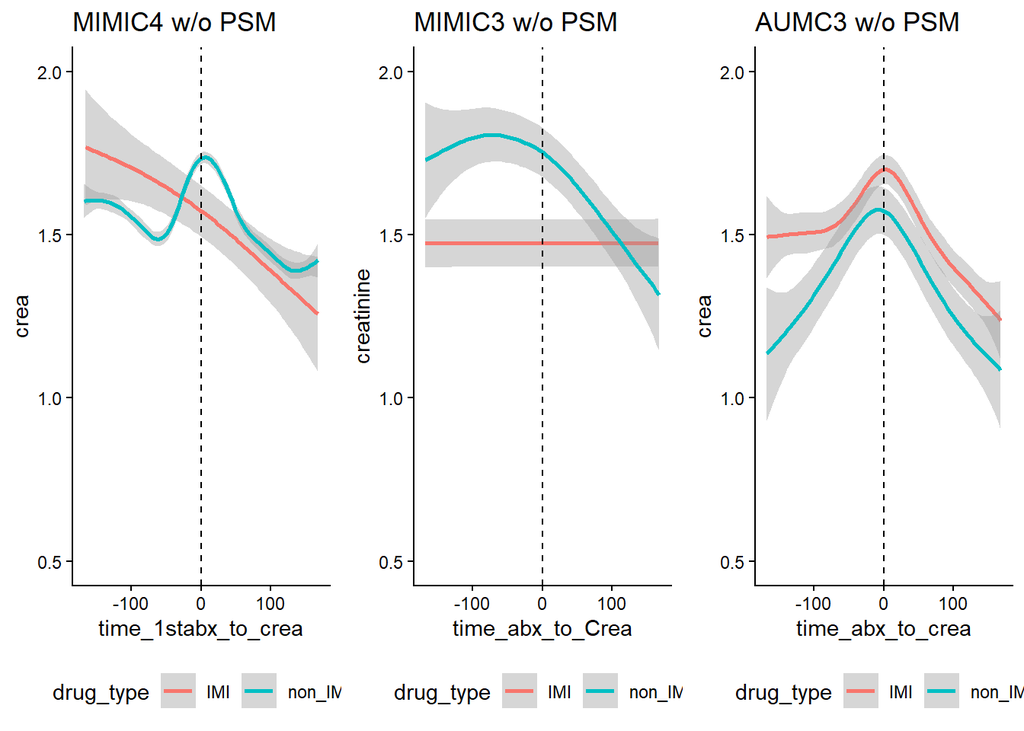

```r
#creatinine change from 1st-penem (before PSM)
creatinine_c <- readRDS("creatinine_c.rds")
m4_crea4 <- readRDS("m4_crea4.rds")
aumc_crea44 <- read_rds("aumc_crea4.rds") %>% left_join(., read.csv("MDF_aumc.csv") %>% dplyr::select(icustay_id, drug_type) %>% rename("admissionid"=icustay_id), by="admissionid")

c0 <- ggplot(m4_crea4, aes(time_1stabx_to_crea, crea, color=drug_type))+theme_classic()+
  geom_smooth()+xlim(c(-168, 168))+theme(legend.position = "bottom")+coord_cartesian(ylim = c(0.5, 2))+geom_vline(xintercept=0, linetype="dashed")+ggtitle("MIMIC4 w/o PSM")
c1 <- ggplot(creatinine_c, aes(time_abx_to_Crea, creatinine, color=drug_type))+theme_classic()+
  geom_smooth()+xlim(c(-168, 168))+theme(legend.position = "bottom")+coord_cartesian(ylim = c(0.5, 2))+geom_vline(xintercept=0, linetype="dashed")+ggtitle("MIMIC3 w/o PSM")
c2 <- ggplot(aumc_crea44 %>% subset(!is.na(drug_type)),
       aes(time_abx_to_crea, crea, color=drug_type))+ theme_classic()+
  geom_smooth()+xlim(c(-168, 168))+theme(legend.position = "bottom")+coord_cartesian(ylim = c(0.5, 2))+geom_vline(xintercept=0, linetype="dashed")+ggtitle("AUMC3 w/o PSM")
gridExtra::grid.arrange(c0, c1, c2, nrow=1)
```

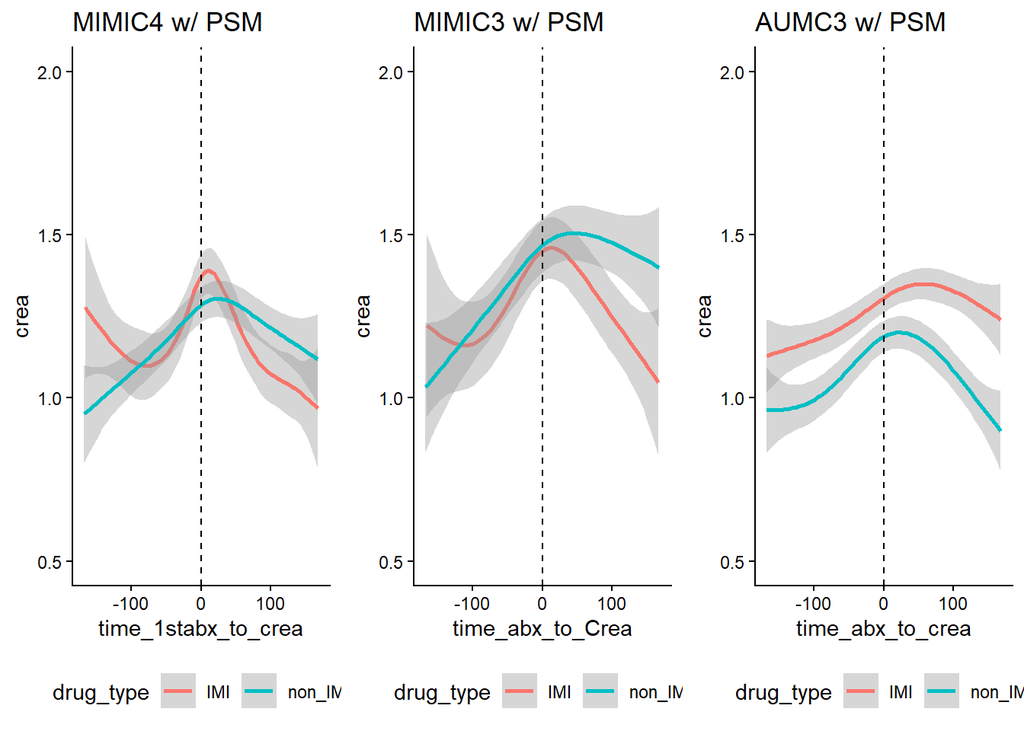

```r
#creatinine change from 1st-penem (after PSM)
c3 <- ggplot(m4_crea4 %>% subset(hadm_id %in% matched_MIMIC4_DF$ID), aes(time_1stabx_to_crea, crea, color=drug_type))+theme_classic()+
  geom_smooth()+xlim(c(-168, 168))+theme(legend.position = "bottom")+coord_cartesian(ylim = c(0.5, 2))+geom_vline(xintercept=0, linetype="dashed")+ggtitle("MIMIC4 w/ PSM")

c4 <- ggplot(creatinine_c %>% subset(hadm_id %in% matched_MIMIC3_DF$ID) %>% rename("crea"=creatinine), aes(time_abx_to_Crea, crea, color=drug_type))+theme_classic()+geom_smooth()+xlim(c(-168, 168))+theme(legend.position = "bottom")+coord_cartesian(ylim = c(0.5, 2))+geom_vline(xintercept=0, linetype="dashed")+ggtitle("MIMIC3 w/ PSM")

c5 <- ggplot(aumc_crea44 %>% subset(admissionid %in% matched_AUMC_DF$ID) %>% subset(!is.na(drug_type)),
       aes(time_abx_to_crea, crea, color=drug_type))+theme_classic()+
  geom_smooth()+xlim(c(-168, 168))+theme(legend.position = "bottom")+coord_cartesian(ylim = c(0.5, 2))+geom_vline(xintercept=0, linetype="dashed")+ggtitle("AUMC3 w/ PSM")
gridExtra::grid.arrange(c3, c4, c5, nrow=1)
```

####check some eGFR change for notes

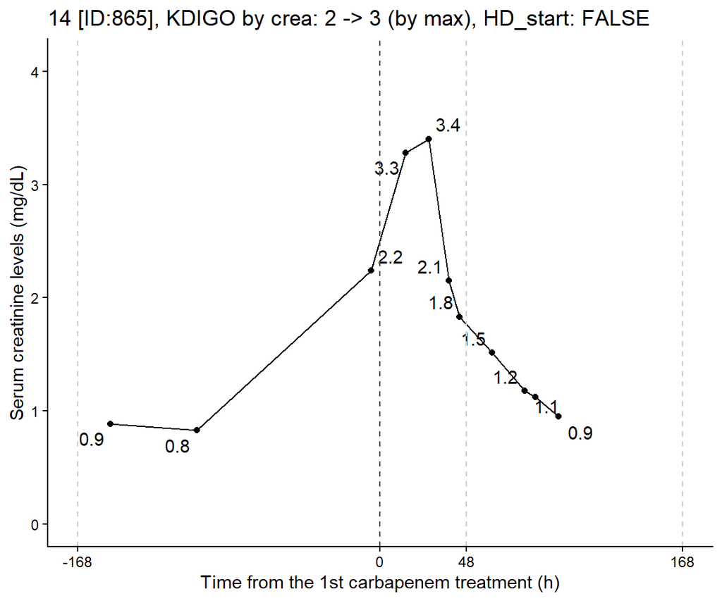

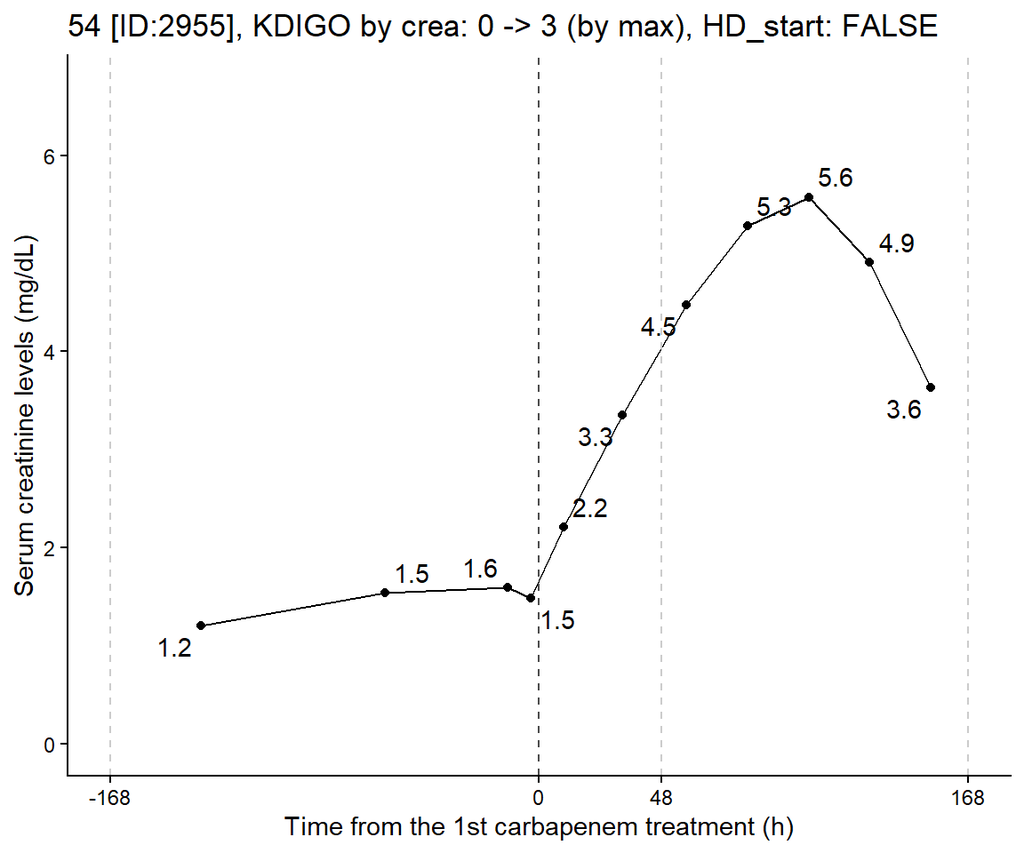

```r
library(ggrepel)
for (i in c(14,54)) {
data_n6 <- aumc_crea44 %>% group_by(admissionid) %>% summarise("count"=n()) %>% filter(count>5)
data <- aumc_crea44 %>% subset(admissionid %in% data_n6$admissionid) %>% subset(admissionid %in% matched_AUMC_DF$ID)
data_one_subject <- data %>% subset(admissionid == data$admissionid %>% unique() %>% .[i])
ID <- data_one_subject$admissionid %>% unique()
g<-ggplot(data_one_subject, aes(time_abx_to_crea, crea))+
  theme_classic()+
  geom_point()+geom_line()+
  geom_text_repel(aes(label = round(crea, digits=1)))+
  xlim(c(-180, 180))+scale_x_continuous(breaks=c(-168,0,48,168))+
  labs(x="Time from the 1st carbapenem treatment (h)", y="Serum creatinine levels (mg/dL)")+
  theme(legend.position = "none", axis.text.x =  element_text("ccc"))+
  coord_cartesian(ylim = c(0, max(data_one_subject$crea)*1.2))+
    geom_vline(xintercept=0, linetype="dashed", color="gray30")+
    geom_vline(xintercept=-168, linetype="dashed", color="gray80")+
      geom_vline(xintercept=48, linetype="dashed", color="gray80")+
      geom_vline(xintercept=168, linetype="dashed", color="gray80")+
  ggtitle(paste0(i," [ID:",ID, "], KDIGO by crea: ", data_one_subject$base_KDIGO_crea, " -> ",
                 max(data_one_subject %>% subset(time_abx_to_crea>0) %>% .$outcome_KDIGO_crea, na.rm = T), " (by max), HD_start: ", comb_DF2 %>% subset(ID %in% 3034) %>% .$outcome_new_dial %>% unique()))
  print(g)
  data_n6
}
```

```r
#data %>% group_by(admissionid) %>% summarise(n())
#data %>% subset(admissionid == data$admissionid %>% unique() %>% .[51])
```

__

### **3. Overlap weighting**

Propensity score for I/C group was calculated with age, sex, ICU type, SIRS, pre blood culture, pre vancomycin use, pre vasopressor use, baseline sCr, sCr at treatment start and AKI stage at treatment start. Then the overlap weighting was performed on each dataset based on the propensity scores.

__

#### 3a. backgrounds and outcome development after overlap weighting

```r
#OVERLAP_PSM
library(WeightIt) #install.packages("WeightIt")
library(PSweight) #install.packages("PSweight")
library(survey) #install.packages("survey")
comb_DF2ovl <- comb_DF2 %>% as.data.frame()# %>% subset(data=="MIMIC3")

FORMULA_ovl <- drug01 ~ age_cat + sex  + dep_type2 + sirs + pre_blood_culture+ treat_van + vasopressor + base_crea + near_crea + base_KDIGO
FORMULA_ovl2 <- drug01 ~  age_cat + sex + dep_type2 + sirs + pre_blood_culture + treat_van + vasopressor + base_crea + near_crea +  base_KDIGO
#dig2s <- c("outcome_max_crea_ratio", "outcome_max_crea_diff","base_crea", "near_crea")

#Create function to do calculating PS, weighing, and showing table.
OVLP<-function(DF0, FORM, TITLE, TITLE2){
DF<-DF0
bal_ovlp <- PSweight::SumStat(ps.formula = FORM, data = DF, weight="overlap")
ps_man <- glm(formula = FORM, data=DF, family = binomial) %>% .$fitted.values
wgt_man <- DF %>% mutate(ps_for_IMI = ps_man, ovlp_wgt = case_when(drug01 == 1 ~ (1-ps_man), drug01 == 0 ~ ps_man))
saveRDS(bal_ovlp, paste0("bal_ovlp", TITLE, ".rds"))
saveRDS(wgt_man, paste0("wgt_man_", TITLE, ".rds"))

svydesign(~1, data = wgt_man %>% as.data.frame(), weights = wgt_man$ovlp_wgt) %>% tbl_svysummary(include = VARS, by=drug_type, type = list(CONTIN ~ "continuous"), digits = list(all_categorical() ~ 1, all_continuous() ~ 1), label = l_list) %>%
  add_p(pvalue_fun = label_style_pvalue(digits = 2)) %>%
  modify_header(all_stat_cols() ~ "**{level}** N={style_number(n, scale = 1, digits = 1)}") %>%
  modify_spanning_header(update = all_stat_cols() ~ TITLE2)
}
```

```r
#1. overlap-PSM using MIMIC3
OVLP(comb_DF2ovl %>% subset(dataset=="MIMIC3"), FORMULA_ovl2, "Ovlp_MIMIC3", "**Ovlp, MIMIC-III, base_KDIGO<3**")
```

| **Characteristic** | **Ovlp, MIMIC-III, base_KDIGO<3** **I/C** N=60.5<sup>1</sup> | **Ovlp, MIMIC-III, base_KDIGO<3** **NCC** N=60.5<sup>1</sup> | **p-value**<sup>2</sup> |  |
| --- | --- | --- | --- | --- |
| dataset |  |  |  |  |
| MIMIC3 | 60.5 (100.0%) | 60.5 (100.0%) |  |  |
| age_group |  |  | 0.87 |  |
| 18-39 | 3.4 (5.6%) | 4.5 (7.5%) |  |  |
| 40-49 | 6.3 (10.4%) | 5.2 (8.6%) |  |  |
| 50-59 | 10.8 (17.8%) | 9.5 (15.8%) |  |  |
| 60-69 | 13.5 (22.3%) | 12.6 (20.8%) |  |  |
| 70-79 | 13.8 (22.9%) | 17.5 (28.9%) |  |  |
| 80+ | 12.7 (21.0%) | 11.2 (18.5%) |  |  |
| sex |  |  | >0.99 |  |
| Female | 29.2 (48.3%) | 29.2 (48.3%) |  |  |
| Male | 31.3 (51.7%) | 31.3 (51.7%) |  |  |
| bmi | 27.5 (24.7, 29.8) | 27.8 (23.6, 33.3) | >0.99 |  |
| Unknown | 28 | 31 |  |  |
| ICU type |  |  | >0.99 |  |
| Non-surgery | 36.7 (60.7%) | 36.7 (60.7%) |  |  |
| Surgery | 23.8 (39.3%) | 23.8 (39.3%) |  |  |
| drug_name |  |  |  |  |
| Imipenem/cilastatin | 60.5 (100.0%) | 0.0 (0.0%) |  |  |
| Imipenem/cilastatin/relebactam | 0.0 (0.0%) | 0.0 (0.0%) |  |  |
| Meropenem | 0.0 (0.0%) | 60.5 (100.0%) |  |  |
| Doripenem | 0.0 (0.0%) | 0.0 (0.0%) |  |  |
| Ertapenem | 0.0 (0.0%) | 0.0 (0.0%) |  |  |
| sofa | 5.0 (3.0, 8.0) | 4.0 (2.0, 7.0) | 0.34 |  |
| qsofa | 1.0 (0.0, 1.0) | 1.0 (0.0, 1.0) | >0.99 |  |
| Unknown | 0 | 2 |  |  |
| sirs | 2.0 (1.0, 3.0) | 2.0 (1.0, 3.0) | 0.84 |  |
| pre_blood_culture | 48.4 (80.1%) | 48.4 (80.1%) | >0.99 |  |
| pre vancomycin use | 19.5 (32.3%) | 19.5 (32.3%) | >0.99 |  |
| pre vasopressor use | 24.9 (41.2%) | 24.9 (41.2%) | >0.99 |  |
| pre ventilation | 40.9 (67.7%) | 41.1 (67.9%) | 0.97 |  |
| Baseline sCr | 0.9 (0.6, 1.4) | 0.9 (0.6, 1.4) | 0.89 |  |
| sCr at treatment start | 1.1 (0.8, 1.7) | 1.1 (0.7, 1.7) | 0.78 |  |
| AKI stage at treatment start |  |  | >0.99 |  |
| 0 | 45.2 (74.7%) | 45.2 (74.7%) |  |  |
| 1 | 13.7 (22.7%) | 13.7 (22.7%) |  |  |
| 2 | 1.6 (2.6%) | 1.6 (2.6%) |  |  |
| observation time | 168.0 (168.0, 168.0) | 168.0 (168.0, 168.0) | 0.49 |  |
| Cencsored with drug change | 2.4 (3.9%) | 0.2 (0.3%) | 0.005 |  |
| RRT at treatment start | 0.0 (0.0%) | 0.0 (0.0%) |  |  |
| O, AKI develop/progress | 14.9 (24.6%) | 23.7 (39.1%) | 0.019 |  |
| O, Death | 7.6 (12.6%) | 9.1 (15.1%) | 0.58 |  |
| O, AKI d/p or death | 18.7 (31.0%) | 26.9 (44.5%) | 0.034 |  |
| O, RRT-intervention | 1.5 (2.5%) | 2.9 (4.8%) | 0.37 |  |
| O, Death or RRT-intervention | 8.4 (14.0%) | 11.5 (19.1%) | 0.30 |  |

<sup>1</sup> n (%); Median (Q1, Q3)  
<sup>2</sup> NA; Pearson’s X^2: Rao & Scott adjustment; Design-based KruskalWallis test

```r
#2. overlap-PSM using MIMIC4
OVLP(comb_DF2ovl %>% subset(dataset=="miiv"), FORMULA_ovl2, "Ovlp_MIMIC4", "**Ovlp, MIMIC-IV, base_KDIGO<3**")
```

| **Characteristic** | **Ovlp, MIMIC-IV, base_KDIGO<3** **I/C** N=85.1<sup>1</sup> | **Ovlp, MIMIC-IV, base_KDIGO<3** **NCC** N=85.1<sup>1</sup> | **p-value**<sup>2</sup> |  |
| --- | --- | --- | --- | --- |
| dataset |  |  |  |  |
| miiv | 85.1 (100.0%) | 85.1 (100.0%) |  |  |
| age_group |  |  | 0.62 |  |
| 18-39 | 7.8 (9.2%) | 6.8 (8.0%) |  |  |
| 40-49 | 9.7 (11.4%) | 7.7 (9.0%) |  |  |
| 50-59 | 10.7 (12.5%) | 16.7 (19.7%) |  |  |
| 60-69 | 24.2 (28.4%) | 22.3 (26.2%) |  |  |
| 70-79 | 18.3 (21.5%) | 17.4 (20.5%) |  |  |
| 80+ | 14.4 (16.9%) | 14.2 (16.6%) |  |  |
| sex |  |  | >0.99 |  |
| Female | 36.7 (43.2%) | 36.7 (43.2%) |  |  |
| Male | 48.4 (56.8%) | 48.4 (56.8%) |  |  |
| bmi | 28.1 (25.1, 33.6) | 27.4 (23.5, 33.2) | 0.44 |  |
| Unknown | 43 | 32 |  |  |
| ICU type |  |  | >0.99 |  |
| Non-surgery | 70.4 (82.8%) | 70.4 (82.8%) |  |  |
| Surgery | 14.7 (17.2%) | 14.7 (17.2%) |  |  |
| drug_name |  |  | <0.001 |  |
| Imipenem/cilastatin | 84.1 (98.9%) | 0.0 (0.0%) |  |  |
| Imipenem/cilastatin/relebactam | 1.0 (1.1%) | 0.0 (0.0%) |  |  |
| Meropenem | 0.0 (0.0%) | 84.5 (99.3%) |  |  |
| Doripenem | 0.0 (0.0%) | 0.2 (0.2%) |  |  |
| Ertapenem | 0.0 (0.0%) | 0.4 (0.5%) |  |  |
| sofa | 4.0 (3.0, 8.0) | 5.0 (3.0, 8.0) | 0.22 |  |
| qsofa | 1.0 (0.0, 1.0) | 1.0 (0.0, 1.0) | 0.68 |  |
| Unknown | 0 | 0 |  |  |
| sirs | 2.0 (1.0, 3.0) | 2.0 (1.0, 3.0) | 0.95 |  |
| pre_blood_culture | 65.7 (77.3%) | 65.7 (77.3%) | >0.99 |  |
| pre vancomycin use | 52.4 (61.6%) | 52.4 (61.6%) | >0.99 |  |
| pre vasopressor use | 7.7 (9.0%) | 7.7 (9.0%) | >0.99 |  |
| pre ventilation | 11.6 (13.6%) | 7.3 (8.6%) | 0.11 |  |
| Baseline sCr | 1.0 (0.6, 1.5) | 1.0 (0.6, 1.5) | >0.99 |  |
| sCr at treatment start | 1.1 (0.7, 2.0) | 1.1 (0.7, 1.8) | 0.91 |  |
| AKI stage at treatment start |  |  | 0.97 |  |
| 0 | 64.7 (76.0%) | 64.3 (75.6%) |  |  |
| 1 | 15.5 (18.3%) | 16.2 (19.1%) |  |  |
| 2 | 4.9 (5.7%) | 4.5 (5.3%) |  |  |
| observation time | 168.0 (109.5, 168.0) | 168.0 (143.1, 168.0) | 0.28 |  |
| Unknown | 9 | 7 |  |  |
| Cencsored with drug change | 3.9 (4.5%) | 0.0 (0.0%) | 0.040 |  |
| RRT at treatment start | 0.0 (0.0%) | 0.0 (0.0%) |  |  |
| O, AKI develop/progress | 30.8 (36.3%) | 27.0 (31.7%) | 0.37 |  |
| O, Death | 13.5 (15.9%) | 12.4 (14.6%) | 0.74 |  |
| O, AKI d/p or death | 32.8 (38.5%) | 32.3 (37.9%) | 0.91 |  |
| O, RRT-intervention | 2.9 (3.4%) | 5.7 (6.7%) | 0.23 |  |
| O, Death or RRT-intervention | 14.5 (17.0%) | 16.2 (19.0%) | 0.64 |  |

<sup>1</sup> n (%); Median (Q1, Q3)  
<sup>2</sup> NA; Pearson’s X^2: Rao & Scott adjustment; Design-based KruskalWallis test

```r
#3. overlap-PSM using AUMC
OVLP(comb_DF2ovl %>% subset(dataset=="AUMC"), FORMULA_ovl2, "Ovlp_AUMC", "**Ovlp, AUMC, base_KDIGO<3**")
```

| **Characteristic** | **Ovlp, AUMC, base_KDIGO<3** **I/C** N=144.3<sup>1</sup> | **Ovlp, AUMC, base_KDIGO<3** **NCC** N=144.3<sup>1</sup> | **p-value**<sup>2</sup> |  |
| --- | --- | --- | --- | --- |
| dataset |  |  |  |  |
| AUMC | 144.3 (100.0%) | 144.3 (100.0%) |  |  |
| age_group |  |  | 0.56 |  |
| 18-39 | 16.0 (11.1%) | 20.1 (14.0%) |  |  |
| 40-49 | 15.6 (10.8%) | 15.1 (10.4%) |  |  |
| 50-59 | 31.9 (22.1%) | 25.5 (17.7%) |  |  |
| 60-69 | 44.9 (31.1%) | 41.2 (28.6%) |  |  |
| 70-79 | 29.9 (20.7%) | 36.2 (25.1%) |  |  |
| 80+ | 5.9 (4.1%) | 6.2 (4.3%) |  |  |
| sex |  |  | >0.99 |  |
| Female | 52.7 (36.5%) | 52.7 (36.5%) |  |  |
| Male | 91.6 (63.5%) | 91.6 (63.5%) |  |  |
| bmi | 24.5 (21.9, 27.8) | 24.5 (21.9, 27.8) | 0.45 |  |
| Unknown | 8 | 3 |  |  |
| ICU type |  |  | >0.99 |  |
| Non-surgery | 85.5 (59.3%) | 85.5 (59.3%) |  |  |
| Surgery | 58.8 (40.7%) | 58.8 (40.7%) |  |  |
| drug_name |  |  |  |  |
| Imipenem/cilastatin | 144.3 (100.0%) | 0.0 (0.0%) |  |  |
| Imipenem/cilastatin/relebactam | 0.0 (0.0%) | 0.0 (0.0%) |  |  |
| Meropenem | 0.0 (0.0%) | 144.3 (100.0%) |  |  |
| Doripenem | 0.0 (0.0%) | 0.0 (0.0%) |  |  |
| Ertapenem | 0.0 (0.0%) | 0.0 (0.0%) |  |  |
| sofa | 7.0 (5.0, 9.0) | 7.0 (4.0, 9.0) | 0.68 |  |
| Unknown | 20 | 25 |  |  |
| qsofa | 1.0 (0.0, 1.0) | 1.0 (0.0, 1.0) | 0.90 |  |
| Unknown | 0 | 0 |  |  |
| sirs | 2.0 (2.0, 3.0) | 2.0 (1.0, 3.0) | 0.95 |  |
| pre_blood_culture | 21.3 (14.8%) | 21.3 (14.8%) | >0.99 |  |
| pre vancomycin use | 72.0 (49.9%) | 72.0 (49.9%) | >0.99 |  |
| pre vasopressor use | 91.4 (63.3%) | 91.4 (63.3%) | >0.99 |  |
| pre ventilation | 96.3 (66.7%) | 85.8 (59.4%) | 0.068 |  |
| Baseline sCr | 0.8 (0.6, 1.2) | 0.7 (0.6, 1.1) | 0.21 |  |
| sCr at treatment start | 1.0 (0.7, 1.5) | 0.9 (0.6, 1.5) | 0.26 |  |
| AKI stage at treatment start |  |  | 0.90 |  |
| 0 | 105.2 (72.9%) | 106.2 (73.6%) |  |  |
| 1 | 30.6 (21.2%) | 28.7 (19.9%) |  |  |
| 2 | 8.5 (5.9%) | 9.4 (6.5%) |  |  |
| observation time | 168.0 (64.0, 168.0) | 162.0 (61.0, 168.0) | 0.65 |  |
| Cencsored with drug change | 4.5 (3.1%) | 1.4 (1.0%) | 0.10 |  |
| RRT at treatment start | 0.0 (0.0%) | 0.0 (0.0%) |  |  |
| O, AKI develop/progress | 43.8 (30.3%) | 41.7 (28.9%) | 0.72 |  |
| O, Death | 19.6 (13.6%) | 19.0 (13.2%) | 0.90 |  |
| O, AKI d/p or death | 50.9 (35.3%) | 50.9 (35.3%) | >0.99 |  |
| O, RRT-intervention | 14.1 (9.8%) | 16.2 (11.3%) | 0.56 |  |
| O, Death or RRT-intervention | 28.7 (19.9%) | 28.1 (19.5%) | 0.90 |  |

<sup>1</sup> n (%); Median (Q1, Q3)  
<sup>2</sup> NA; Pearson’s X^2: Rao & Scott adjustment; Design-based KruskalWallis test

```r
#check smd using CreateTableOne package
library(tableone)
library(survey)
library(dplyr)
CreateTableOne(strata = "drug_type", data = readRDS("wgt_man_Ovlp_MIMIC3.rds")) %>% print(smd=T)
```

```
##                                             Stratified by drug_type
##                                              I/C
##   n                                                 77
##   dataset = MIMIC3 (%)                              77 (100.0)
##   age_cat (mean (SD))                            66.17 (15.34)
##   age_group (%)
##      18-39                                           4 (  5.2)
##      40-49                                           8 ( 10.4)
##      50-59                                          13 ( 16.9)
##      60-69                                          17 ( 22.1)
##      70-79                                          18 ( 23.4)
##      80+                                            17 ( 22.1)
##   sex = Male (%)                                    39 ( 50.6)
##   bmi (mean (SD))                                29.20 (7.65)
##   drug_type = NCC (%)                                0 (  0.0)
##   Imipenem.Cilastatin (mean (SD))                 1.66 (0.90)
##   Imipenem.Cilastatin.Relebactam (mean (SD))      0.00 (0.00)
##   time_switch_group (mean (SD))                 163.95 (20.38)
##   dep_type = surg (%)                               32 ( 41.6)
##   time_ICUadmit_to_abx (mean (SD))              140.60 (209.49)
##   pre_blood_culture = TRUE (%)                      60 ( 77.9)
##   treat_van = TRUE (%)                              23 ( 29.9)
##   vasopressor = TRUE (%)                            30 ( 39.0)
##   ventilation = TRUE (%)                            52 ( 67.5)
##   sofa (mean (SD))                                5.38 (3.57)
##   qsofa (mean (SD))                               0.71 (0.67)
##   sirs (mean (SD))                                1.90 (1.07)
##   sep3 = TRUE (%)                                   41 ( 53.2)
##   base_crea (mean (SD))                           1.16 (0.77)
##   near_crea (mean (SD))                           1.36 (0.84)
##   base_KDIGO (mean (SD))                          0.27 (0.50)
##   obs_period (mean (SD))                        149.68 (37.93)
##   base_KDIGO_dial = FALSE (%)                       77 (100.0)
##   outcome_KDIGO (mean (SD))                       0.43 (0.85)
##   outcome_new_dial = TRUE (%)                        2 (  2.6)
##   outcome_KDIGO_inc = TRUE (%)                      19 ( 24.7)
##   death_in_7d = TRUE (%)                            10 ( 13.0)
##   outcome_KDIGO_inc_or_death = TRUE (%)             24 ( 31.2)
##   outcome_max_crea_ratio (mean (SD))              1.42 (1.07)
##   outcome_max_crea_diff (mean (SD))               0.37 (0.76)
```

[output cut: 113 more lines]

```
##   drug = Meropenem (%)                          NaN
##   ID (mean (SD))                              0.015
##   dep_type2 = Surgery (%)                     0.207
##   drug01 (mean (SD))                            Inf
##   drug10 (mean (SD))                            Inf
##   drug_switch = TRUE (%)                      0.253
##   outcome_HDD_in7d = TRUE (%)                 0.164
##   drug_name (%)                                 NaN
##      Imipenem/cilastatin
##      Imipenem/cilastatin/relebactam
##      Meropenem
##      Doripenem
##      Ertapenem
##   ps_for_IMI (mean (SD))                      0.448
##   ovlp_wgt (mean (SD))                        8.365
```

__

#### 3b. checking matching/weighting quality

```r
#Checking ROC
roc(readRDS("wgt_man_Ovlp_MIMIC3.rds")$treat, readRDS("wgt_man_Ovlp_MIMIC3.rds")$ps_for_IMI)%>%auc()%>%round(.,digits = 2)%>%paste0("ovlp_AUC (MIMIC-III) = ", .)
```

```
## [1] "ovlp_AUC (MIMIC-III) = 0.87"
```

```r
roc(readRDS("wgt_man_Ovlp_MIMIC4.rds")$treat, readRDS("wgt_man_Ovlp_MIMIC4.rds")$ps_for_IMI)%>%auc()%>%round(.,digits = 2)%>%paste0("ovlp_AUC (MIMIC-IV) = ", .)
```

```
## [1] "ovlp_AUC (MIMIC-IV) = 0.76"
```

```r
roc(readRDS("wgt_man_Ovlp_AUMC.rds")$treat, readRDS("wgt_man_Ovlp_AUMC.rds")$ps_for_IMI) %>%auc()%>%round(., digits = 2)%>%paste0("ovlp_AUC (AUMC) = ", .)
```

```
## [1] "ovlp_AUC (AUMC) = 0.51"
```

```r
#Checking histogram of propensity score
HISTO <- function(DF, TITLE, MARK){
ggplot(DF, aes(ps_for_IMI, group = drug_type, fill=drug_type))+
    geom_histogram(color="black", data = DF %>% subset(drug_type=="I/C"), aes(y=..count..))+
    geom_histogram(color="black", data = DF %>% subset(drug_type!="I/C"), aes(y=-..count..))+
    theme_classic()+
    labs(title =  TITLE, x="Propensity score for I/C group", y="Counts")+
    theme(plot.title = element_text(size = 14, hjust = 0), axis.title.x = element_text(size=10.5))}

tiff("eFigure 1 (histogram).tif", res = 300, width = 8, height = 6, units = "in", compression = "lzw")
gridExtra::grid.arrange(
  HISTO(readRDS("wgt_man_Ovlp_MIMIC3.rds"), "(A) MIMIC-III"),
  HISTO(readRDS("wgt_man_Ovlp_MIMIC4.rds"), "(B) MIMIC-IV"),
  HISTO(readRDS("wgt_man_Ovlp_AUMC.rds"), "(C) AUMC"), nrow=2)
dev.off()
```

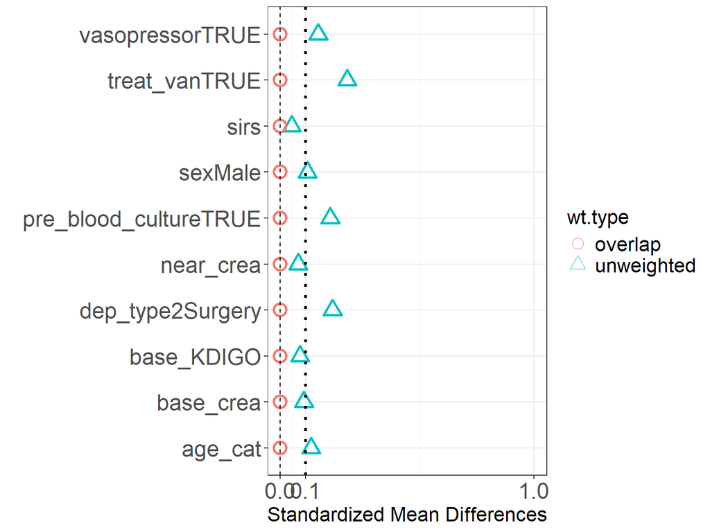

```r
#Checking SMD
plot(readRDS("bal_ovlpOvlp_MIMIC3.rds"), type="balance", threshold=0.1)
```

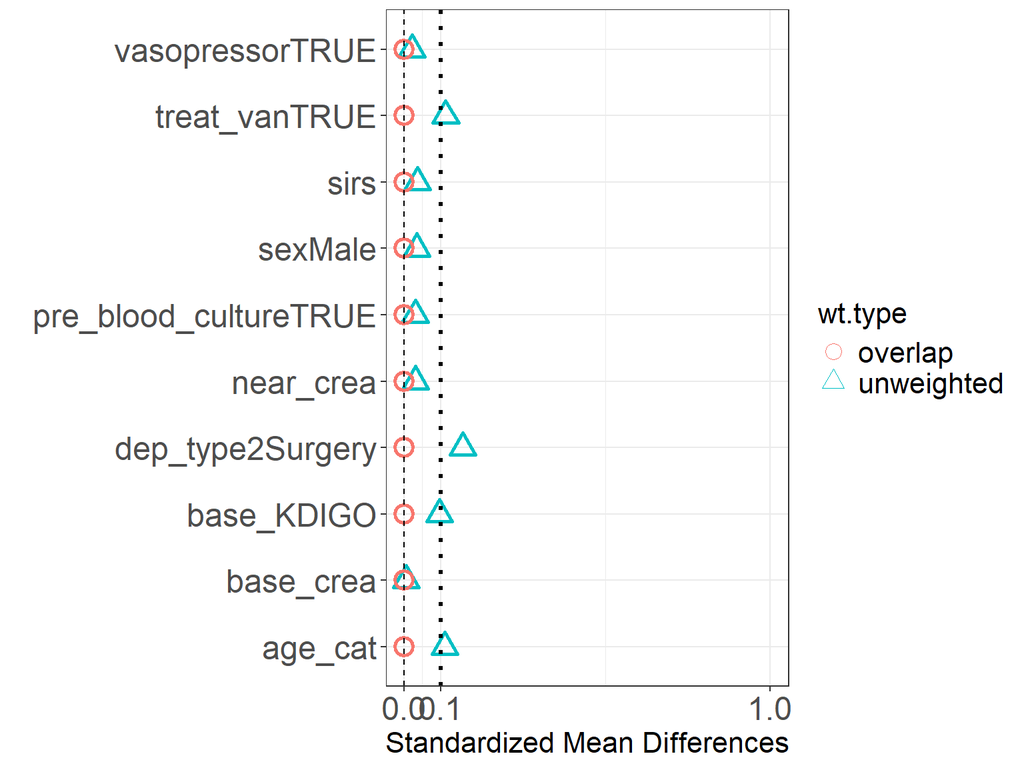

```r
plot(readRDS("bal_ovlpOvlp_MIMIC4.rds"), type="balance")
```

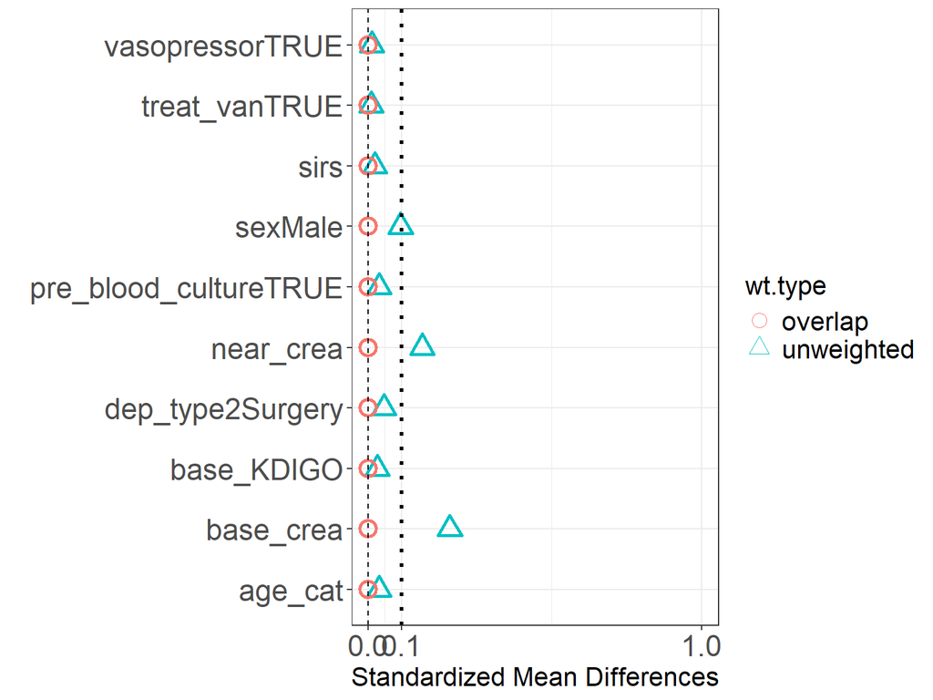

```r
plot(readRDS("bal_ovlpOvlp_AUMC.rds"), type="balance")
```

_

#### 3c. Forest plot of the primary outcomes in each dataset and of overall result

_

```r
#calculating Odds ratio of I/C group in each dataset (not needed)
library(forestplot)
OVLP_OR <- function(DF, FORM, OUTCOME, TITLE){
est_ovlp <- PSweight(ps.formula = FORM, yname = OUTCOME, data = DF, weight = "overlap")
summary1 <- est_ovlp %>% summary(type="OR") %>% .$estimates %>% as.data.frame() %>%
  mutate(
      OR = exp(Estimate),
      LCI = exp(lwr),
      UCI = exp(upr),
      study = TITLE,
      outcome = OUTCOME
  )
svy_design <- svydesign(~1, data = DF %>% as.data.frame(), weights = DF$ovlp_wgt)
fmla <- as.formula(paste("~", OUTCOME))
summary1 <- summary1 %>% mutate("pts"= svytable(fmla, svy_design) %>% as.data.frame() %>% .$Freq %>% sum(),
                                "events"=svytable(fmla, svy_design) %>% as.data.frame() %>% filter(.data[[OUTCOME]]==T) %>% .$Freq %>% sum())
summary1
}
```

```r
#calculating Odds ratio of I/C group in each dataset
FP2 <- function(RDS, FORM){
OR_RES <- rbind(
  OVLP_OR(readRDS(RDS), FORM, "outcome_KDIGO_inc_or_death", "AKI progression or death"),
  OVLP_OR(readRDS(RDS), FORM, "outcome_KDIGO_inc", "AKI progression"),
  OVLP_OR(readRDS(RDS), FORM, "outcome_new_dial", "Hemodialysis"),
  OVLP_OR(readRDS(RDS), FORM, "death_in_7d", "Death"),
  OVLP_OR(readRDS(RDS), FORM, "outcome_HDD_in7d", "Hemodialysis or death")) %>%
  mutate("events_percentage"=events/sum(.$event), "pts_percentage"=pts/sum(.$pts))
saveRDS(OR_RES, paste0("ORRES_",RDS))
}

FP2("wgt_man_Ovlp_MIMIC4.rds", FORMULA_ovl2)
FP2("wgt_man_Ovlp_MIMIC3.rds", FORMULA_ovl2)
FP2("wgt_man_Ovlp_AUMC.rds", FORMULA_ovl2)
```

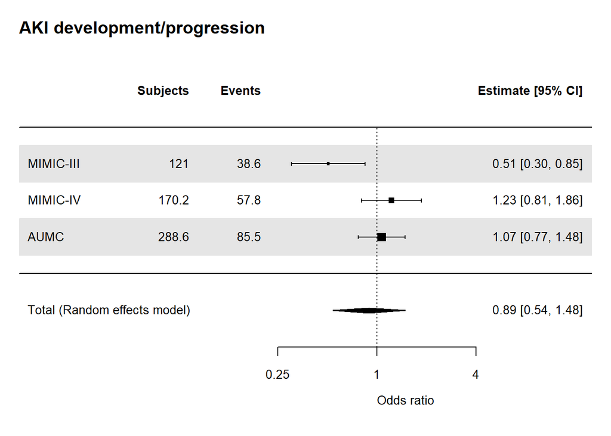

```r
#Pool the results of each dataset with Random Mixed effect meta-analysis
METADF0 <- rbind(
  readRDS("ORRES_wgt_man_Ovlp_MIMIC3.rds") %>% mutate("dataset"="MIMIC-III"),
  readRDS("ORRES_wgt_man_Ovlp_MIMIC4.rds") %>% mutate("dataset"="MIMIC-IV"),
  readRDS("ORRES_wgt_man_Ovlp_AUMC.rds") %>% mutate("dataset"="AUMC"))
METADF_AKID <- METADF0 %>% subset(outcome=="outcome_KDIGO_inc_or_death")
METADF_AKI <- METADF0 %>% subset(outcome=="outcome_KDIGO_inc")
METADF_HD <- METADF0 %>% subset(outcome=="outcome_new_dial")
METADF_D <- METADF0 %>% subset(outcome=="death_in_7d")
METADF_HDD <- METADF0 %>% subset(outcome=="outcome_HDD_in7d")


library(metafor)
METARES_AKID <- rma(yi = Estimate, sei = Std.Error, method = "REML", data = METADF_AKID)
METARES_AKI <-rma(yi = Estimate, sei = Std.Error, method = "REML", data = METADF_AKI)
METARES_HD <-rma(yi = Estimate, sei = Std.Error, method = "REML", data = METADF_HD)
METARES_D <-rma(yi = Estimate, sei = Std.Error, method = "REML", data = METADF_D)
METARES_HDD <-rma(yi = Estimate, sei = Std.Error, method = "REML", data = METADF_HDD)

METAF <- function(METARES, AAA, BBB, CCC, TITLE){
metafor::forest(METARES,  atransf=exp, at=log(AAA), slab = dataset,
       xlim=BBB,
       ilab=cbind(round(pts, digits=1), round(events, digits=1)),
       ilab.lab=c("Subjects","Events"), ilab.pos = 2, ilab.xpos=CCC,
       cex=0.85, header="", xlab="Odds ratio", mlab="Total (Random effects model)", shade=TRUE,
       main=TITLE, adj=0)
}
SCALEA1<-c(0.25, 1, 4)
SCALEB1 <- c(-5,3)
SCALEC1 <- c(-2.5,-1.5)
#
METAF(METARES_AKI, SCALEA1, SCALEB1, SCALEC1, "AKI development/progression")
```

```r
METARES_AKI #details of the overall analysis results
```

```
##
## Random-Effects Model (k = 3; tau^2 estimator: REML)
##
## tau^2 (estimated amount of total heterogeneity): 0.1535 (SE = 0.1999)
## tau (square root of estimated tau^2 value):      0.3918
## I^2 (total heterogeneity / total variability):   77.50%
## H^2 (total variability / sampling variability):  4.44
##
## Test for Heterogeneity:
## Q(df = 2) = 7.6478, p-val = 0.0218
##
## Model Results:
##
## estimate      se     zval    pval    ci.lb   ci.ub
##  -0.1110  0.2579  -0.4305  0.6669  -0.6166  0.3945
##
## ---
## Signif. codes:  0 '***' 0.001 '**' 0.01 '*' 0.05 '.' 0.1 ' ' 1
```

```r
METADF_AKI %>% dplyr::select(dataset, OR, LCI, UCI, 'Pr(>|z|)') %>% remove_rownames()
```

```
##     dataset        OR       LCI       UCI    Pr(>|z|)
## 1 MIMIC-III 0.5070991 0.3034299 0.8474757 0.009554143
## 2  MIMIC-IV 1.2253587 0.8057489 1.8634889 0.342021773
## 3      AUMC 1.0690686 0.7699992 1.4842971 0.689964207
```

```r
tiff("Figure 2 (primary).tif", res = 300, width = 6, height = 4, units = "in", compression = "lzw")
METAF(METARES_AKI, SCALEA1, SCALEB1, SCALEC1, "AKI development/progression")
dev.off()
```

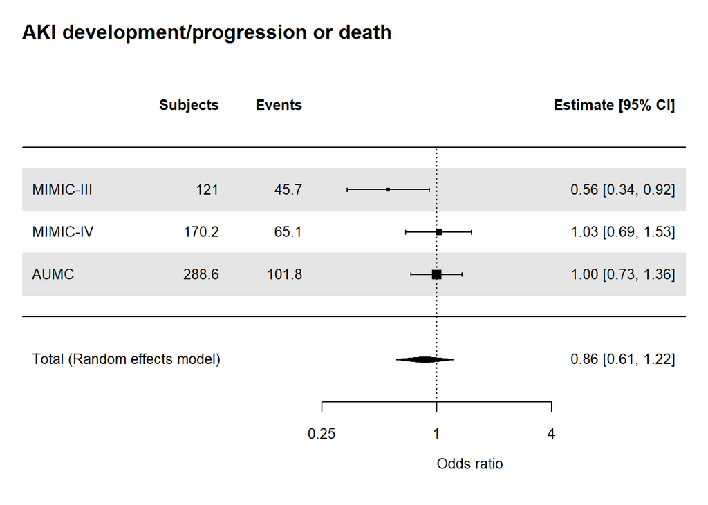

```r
METAF(METARES_AKID, SCALEA1, SCALEB1, SCALEC1, "AKI development/progression or death")
```

```r
tiff("eFigure 3 (sensitivity).tif", res = 300, width = 6, height = 4, units = "in", compression = "lzw")
METAF(METARES_AKID, SCALEA1, SCALEB1, SCALEC1, "AKI development/progression or death")
dev.off()
```

```r
METARES_AKID
```

```
##
## Random-Effects Model (k = 3; tau^2 estimator: REML)
##
## tau^2 (estimated amount of total heterogeneity): 0.0508 (SE = 0.0920)
## tau (square root of estimated tau^2 value):      0.2255
## I^2 (total heterogeneity / total variability):   55.85%
## H^2 (total variability / sampling variability):  2.27
##
## Test for Heterogeneity:
## Q(df = 2) = 4.4071, p-val = 0.1104
##
## Model Results:
##
## estimate      se     zval    pval    ci.lb   ci.ub
##  -0.1463  0.1745  -0.8383  0.4018  -0.4882  0.1957
##
## ---
## Signif. codes:  0 '***' 0.001 '**' 0.01 '*' 0.05 '.' 0.1 ' ' 1
```

```r
METADF_AKID %>% dplyr::select(dataset, OR, LCI, UCI, 'Pr(>|z|)') %>% remove_rownames()
```

```
##     dataset        OR       LCI       UCI   Pr(>|z|)
## 1 MIMIC-III 0.5590126 0.3405750 0.9175514 0.02143129
## 2  MIMIC-IV 1.0254437 0.6891424 1.5258598 0.90138854
## 3      AUMC 0.9992147 0.7349365 1.3585255 0.99600053
```

#### 3d. Forest plot of the secondary outcomes

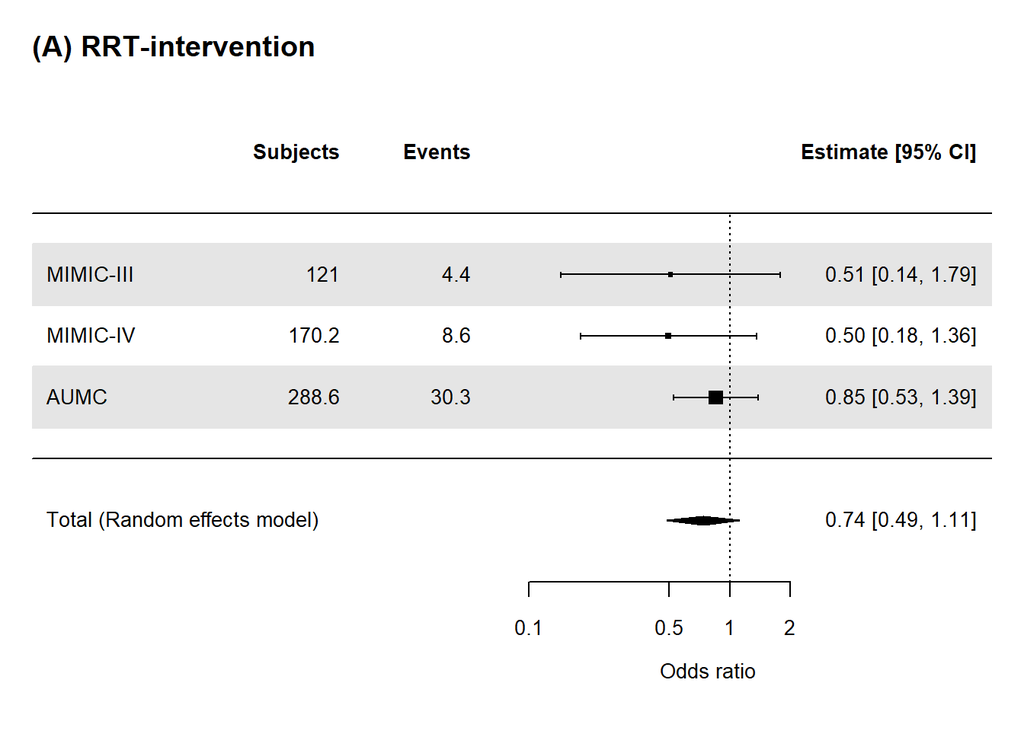

```r
SCALEA2<-c(0.1, 0.5, 1, 2)
SCALEB2 <- c(-8,3)
SCALEC2 <- c(-4.3,-2.8)
METAF(METARES_HD, SCALEA2, SCALEB2, SCALEC2, "(A) RRT-intervention")
```

```r
METARES_HD
```

```
##
## Random-Effects Model (k = 3; tau^2 estimator: REML)
##
## tau^2 (estimated amount of total heterogeneity): 0 (SE = 0.1893)
## tau (square root of estimated tau^2 value):      0
## I^2 (total heterogeneity / total variability):   0.00%
## H^2 (total variability / sampling variability):  1.00
##
## Test for Heterogeneity:
## Q(df = 2) = 1.2781, p-val = 0.5278
##
## Model Results:
##
## estimate      se     zval    pval    ci.lb   ci.ub
##  -0.3053  0.2108  -1.4480  0.1476  -0.7185  0.1079
##
## ---
## Signif. codes:  0 '***' 0.001 '**' 0.01 '*' 0.05 '.' 0.1 ' ' 1
```

```r
METADF_HD %>% dplyr::select(dataset, OR, LCI, UCI, 'Pr(>|z|)') %>% remove_rownames()
```

```
##     dataset        OR       LCI      UCI  Pr(>|z|)
## 1 MIMIC-III 0.5071378 0.1440551 1.785350 0.2903539
## 2  MIMIC-IV 0.4957928 0.1801767 1.364274 0.1743037
## 3      AUMC 0.8532134 0.5252640 1.385918 0.5212803
```

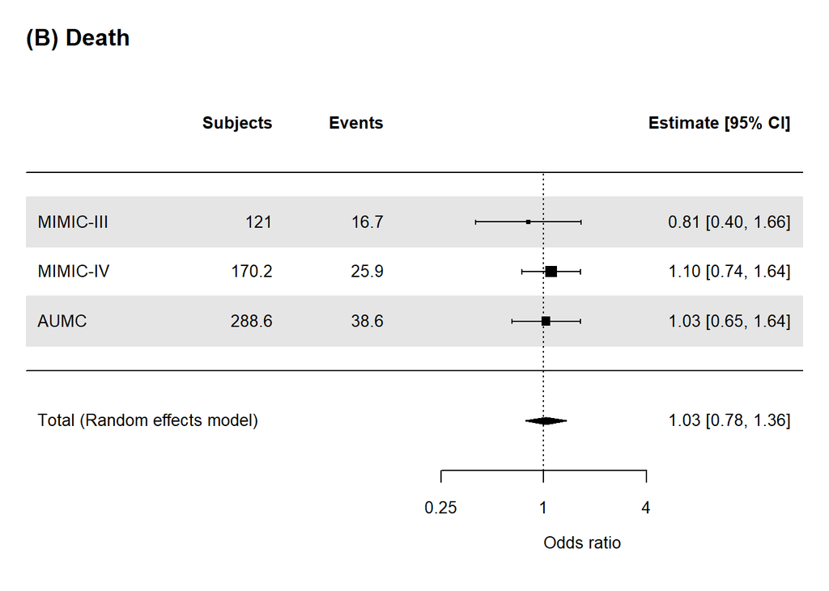

```r
SCALEA3<-c(0.25, 1, 4)
SCALEB3 <- c(-7,3.5)
SCALEC3 <- c(-3.5,-2)
METAF(METARES_D, SCALEA3, SCALEB3, SCALEC3, "(B) Death")
```

```r
METARES_D
```

```
##
## Random-Effects Model (k = 3; tau^2 estimator: REML)
##
## tau^2 (estimated amount of total heterogeneity): 0 (SE = 0.0617)
## tau (square root of estimated tau^2 value):      0
## I^2 (total heterogeneity / total variability):   0.00%
## H^2 (total variability / sampling variability):  1.00
##
## Test for Heterogeneity:
## Q(df = 2) = 0.5444, p-val = 0.7617
##
## Model Results:
##
## estimate      se    zval    pval    ci.lb   ci.ub
##   0.0284  0.1416  0.2005  0.8411  -0.2492  0.3060
##
## ---
## Signif. codes:  0 '***' 0.001 '**' 0.01 '*' 0.05 '.' 0.1 ' ' 1
```

```r
METADF_D %>% dplyr::select(dataset, OR, LCI, UCI, 'Pr(>|z|)') %>% remove_rownames()
```

```
##     dataset        OR       LCI      UCI  Pr(>|z|)
## 1 MIMIC-III 0.8126695 0.3987167 1.656394 0.5680350
## 2  MIMIC-IV 1.1046592 0.7420947 1.644361 0.6238508
## 3      AUMC 1.0322335 0.6504420 1.638126 0.8928979
```

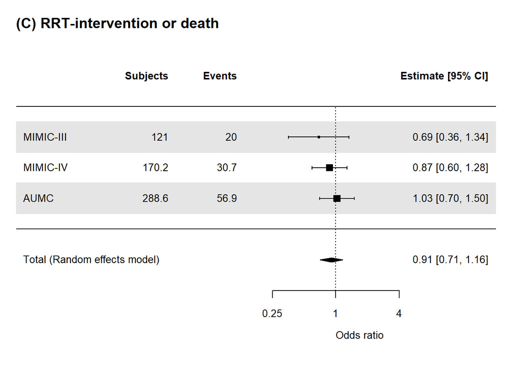

```r
SCALEA3<-c(0.25, 1, 4)
SCALEB3 <- c(-7,3.5)
SCALEC3 <- c(-3.5,-2)
METAF(METARES_HDD, SCALEA3, SCALEB3, SCALEC3, "(C) RRT-intervention or death")
```

```r
METARES_HDD
```

```
##
## Random-Effects Model (k = 3; tau^2 estimator: REML)
##
## tau^2 (estimated amount of total heterogeneity): 0 (SE = 0.0489)
## tau (square root of estimated tau^2 value):      0
## I^2 (total heterogeneity / total variability):   0.00%
## H^2 (total variability / sampling variability):  1.00
##
## Test for Heterogeneity:
## Q(df = 2) = 1.0968, p-val = 0.5779
##
## Model Results:
##
## estimate      se     zval    pval    ci.lb   ci.ub
##  -0.0987  0.1270  -0.7774  0.4369  -0.3477  0.1502
##
## ---
## Signif. codes:  0 '***' 0.001 '**' 0.01 '*' 0.05 '.' 0.1 ' ' 1
```

```r
METADF_HDD %>% dplyr::select(dataset, OR, LCI, UCI, 'Pr(>|z|)') %>% remove_rownames()
```

```
##     dataset        OR       LCI      UCI  Pr(>|z|)
## 1 MIMIC-III 0.6898763 0.3556081 1.338354 0.2722066
## 2  MIMIC-IV 0.8739420 0.5965888 1.280236 0.4891149
## 3      AUMC 1.0255135 0.7027466 1.496525 0.8960547
```

```r
#export
tiff("Figure 3 (secondary).tif",
     width = 5,
     height = 7,     # Tall file to fit 3 plots vertically
     units = "in",
     res = 300,
     compression = "lzw")
par(mfrow = c(3, 1))
METAF(METARES_HD, SCALEA2, SCALEB2, SCALEC2, "(A) RRT-intervention")
METAF(METARES_D, SCALEA3, SCALEB3, SCALEC3, "(B) Death")
METAF(METARES_HDD, SCALEA3, SCALEB3, SCALEC3, "(C) RRT-intervention or death")
dev.off()
```

__

__

### **4. Stratified analysis**

**Stratified by AKI stage at treatment start (stage 0 vs stage 1or2)**

Stratify first, then calculate propensity score and perform overlap weighting.

__

```r
###base_KDIGO=0 before PSOW
#MIMIC3
#tbl_summary(comb_DF2 %>% subset(dataset=="MIMIC3"&base_KDIGO==0), by=drug_type, include = c(VARS, outcome_KDIGO_inc), type = list(qsofa ~ "continuous", sirs~ "continuous")) %>% add_p(pvalue_fun = label_style_pvalue(digits = 2)) %>% modify_spanning_header(update = all_stat_cols() ~ "**MIMIC-III, base_KDIGO=0**")
#MIMIC4
#tbl_summary(comb_DF2 %>% subset(dataset=="miiv"&base_KDIGO==0), by=drug_type, include = c(VARS, outcome_KDIGO_inc), type = list(qsofa ~ "continuous", sirs~ "continuous")) %>% add_p(pvalue_fun = label_style_pvalue(digits = 2)) %>% modify_spanning_header(update = all_stat_cols() ~ "**MIMIC-IV, base_KDIGO=0**")
#AUMC
#tbl_summary(comb_DF2 %>% subset(dataset=="AUMC"&base_KDIGO==0), by=drug_type, include = c(VARS, outcome_KDIGO_inc), type = list(qsofa ~ "continuous", sirs~ "continuous")) %>% modify_spanning_header(update = all_stat_cols() ~ "**AUMC, base_KDIGO=0**") %>% add_p(pvalue_fun = label_style_pvalue(digits = 2))
```

__

#### 4b. Background and outcome among those with AKI at treatment start before matching (Hidden).

```r
###base_KDIGO=1or2 before PSOW
#MIMIC3
#tbl_summary(comb_DF2 %>% subset(dataset=="MIMIC3"&base_KDIGO!=0), by=drug_type, include = c(VARS, outcome_KDIGO_inc), type = list(qsofa ~ "continuous", sirs~ "continuous")) %>% add_p(pvalue_fun = label_style_pvalue(digits = 2)) %>% modify_spanning_header(update = all_stat_cols() ~ "**MIMIC-III, base_KDIGO=1,2**")
#MIMIC4
#tbl_summary(comb_DF2 %>% subset(dataset=="miiv"&base_KDIGO!=0), by=drug_type, include = c(VARS, outcome_KDIGO_inc), type = list(qsofa ~ "continuous", sirs~ "continuous")) %>% add_p(pvalue_fun = label_style_pvalue(digits = 2)) %>% modify_spanning_header(update = all_stat_cols() ~ "**MIMIC-IV, base_KDIGO=1,2**")
#AUMC
#tbl_summary(comb_DF2 %>% subset(dataset=="AUMC"&base_KDIGO!=0), by=drug_type, include = c(VARS, outcome_KDIGO_inc), type = list(qsofa ~ "continuous", sirs~ "continuous")) %>% modify_spanning_header(update = all_stat_cols() ~ "**AUMC, base_KDIGO=1,2**") %>% add_p(pvalue_fun = label_style_pvalue(digits = 2))
```

__

#### 4c. Backgrounds, outcomes, matching quality, and forrest plot among those without AKI at treatment start.

```r
#3. overlap-PSM using MIMIC3, base KDIGO=0
OVLP(comb_DF2ovl %>% subset(dataset=="MIMIC3"&base_KDIGO==0), FORMULA_ovl2, "Ovlp_MIMIC3_base0", "**Ovlp, MIMIC-III, base_KDIGO=0**")
```

| **Characteristic** | **Ovlp, MIMIC-III, base_KDIGO=0** **I/C** N=45.0<sup>1</sup> | **Ovlp, MIMIC-III, base_KDIGO=0** **NCC** N=45.0<sup>1</sup> | **p-value**<sup>2</sup> |  |
| --- | --- | --- | --- | --- |
| dataset |  |  |  |  |
| MIMIC3 | 45.0 (100.0%) | 45.0 (100.0%) |  |  |
| age_group |  |  | 0.68 |  |
| 18-39 | 2.5 (5.6%) | 3.8 (8.4%) |  |  |
| 40-49 | 5.5 (12.2%) | 3.7 (8.2%) |  |  |
| 50-59 | 8.2 (18.2%) | 7.2 (16.0%) |  |  |
| 60-69 | 9.4 (20.8%) | 9.1 (20.2%) |  |  |
| 70-79 | 9.1 (20.2%) | 13.0 (28.8%) |  |  |
| 80+ | 10.3 (23.0%) | 8.3 (18.4%) |  |  |
| sex |  |  | >0.99 |  |
| Female | 20.5 (45.5%) | 20.5 (45.5%) |  |  |
| Male | 24.5 (54.5%) | 24.5 (54.5%) |  |  |
| bmi | 27.6 (24.5, 31.6) | 27.5 (23.4, 31.7) | 0.55 |  |
| Unknown | 20 | 22 |  |  |
| ICU type |  |  | >0.99 |  |
| Non-surgery | 24.1 (53.4%) | 24.1 (53.4%) |  |  |
| Surgery | 21.0 (46.6%) | 21.0 (46.6%) |  |  |
| drug_name |  |  |  |  |
| Imipenem/cilastatin | 45.0 (100.0%) | 0.0 (0.0%) |  |  |
| Imipenem/cilastatin/relebactam | 0.0 (0.0%) | 0.0 (0.0%) |  |  |
| Meropenem | 0.0 (0.0%) | 45.0 (100.0%) |  |  |
| Doripenem | 0.0 (0.0%) | 0.0 (0.0%) |  |  |
| Ertapenem | 0.0 (0.0%) | 0.0 (0.0%) |  |  |
| sofa | 4.0 (3.0, 8.0) | 4.0 (2.0, 7.0) | 0.67 |  |
| qsofa | 1.0 (0.0, 1.0) | 1.0 (0.0, 1.0) | 0.62 |  |
| Unknown | 0 | 1 |  |  |
| sirs | 2.0 (1.0, 3.0) | 2.0 (1.0, 3.0) | 0.94 |  |
| pre_blood_culture | 35.7 (79.2%) | 35.7 (79.2%) | >0.99 |  |
| pre vancomycin use | 14.9 (33.2%) | 14.9 (33.2%) | >0.99 |  |
| pre vasopressor use | 19.0 (42.2%) | 19.0 (42.2%) | >0.99 |  |
| pre ventilation | 30.2 (67.0%) | 30.8 (68.5%) | 0.83 |  |
| Baseline sCr | 1.0 (0.6, 1.4) | 0.9 (0.6, 1.4) | 0.67 |  |
| sCr at treatment start | 1.0 (0.8, 1.4) | 1.0 (0.7, 1.6) | 0.61 |  |
| AKI stage at treatment start |  |  |  |  |
| 0 | 45.0 (100.0%) | 45.0 (100.0%) |  |  |
| observation time | 168.0 (168.0, 168.0) | 168.0 (168.0, 168.0) | 0.72 |  |
| Cencsored with drug change | 1.7 (3.7%) | 0.2 (0.5%) | 0.051 |  |
| RRT at treatment start | 0.0 (0.0%) | 0.0 (0.0%) |  |  |
| O, AKI develop/progress | 14.6 (32.5%) | 21.9 (48.7%) | 0.031 |  |
| O, Death | 5.2 (11.6%) | 7.2 (16.1%) | 0.40 |  |
| O, AKI d/p or death | 16.2 (36.0%) | 24.1 (53.5%) | 0.021 |  |
| O, RRT-intervention | 1.5 (3.2%) | 2.5 (5.6%) | 0.45 |  |
| O, Death or RRT-intervention | 6.0 (13.4%) | 9.3 (20.7%) | 0.21 |  |

<sup>1</sup> n (%); Median (Q1, Q3)  
<sup>2</sup> NA; Pearson’s X^2: Rao & Scott adjustment; Design-based KruskalWallis test

```r
#2. overlap-PSM using MIMIC4, base KDIGO=0
OVLP(comb_DF2ovl %>% subset(dataset=="miiv"&base_KDIGO==0), FORMULA_ovl2, "Ovlp_MIMIC4_base0", "**Ovlp, MIMIC-IV, base_KDIGO=0**")
```

| **Characteristic** | **Ovlp, MIMIC-IV, base_KDIGO=0** **I/C** N=64.6<sup>1</sup> | **Ovlp, MIMIC-IV, base_KDIGO=0** **NCC** N=64.6<sup>1</sup> | **p-value**<sup>2</sup> |  |
| --- | --- | --- | --- | --- |
| dataset |  |  |  |  |
| miiv | 64.6 (100.0%) | 64.6 (100.0%) |  |  |
| age_group |  |  | 0.88 |  |
| 18-39 | 7.7 (12.0%) | 6.9 (10.7%) |  |  |
| 40-49 | 7.7 (12.0%) | 6.5 (10.0%) |  |  |
| 50-59 | 9.7 (15.0%) | 13.5 (20.8%) |  |  |
| 60-69 | 17.4 (26.9%) | 16.3 (25.3%) |  |  |
| 70-79 | 11.5 (17.9%) | 11.8 (18.3%) |  |  |
| 80+ | 10.6 (16.4%) | 9.6 (14.9%) |  |  |
| sex |  |  | >0.99 |  |
| Female | 28.9 (44.7%) | 28.9 (44.7%) |  |  |
| Male | 35.7 (55.3%) | 35.7 (55.3%) |  |  |
| bmi | 27.1 (24.7, 31.6) | 27.0 (23.3, 32.8) | 0.54 |  |
| Unknown | 32 | 25 |  |  |
| ICU type |  |  | >0.99 |  |
| Non-surgery | 54.8 (84.9%) | 54.8 (84.9%) |  |  |
| Surgery | 9.8 (15.1%) | 9.8 (15.1%) |  |  |
| drug_name |  |  | <0.001 |  |
| Imipenem/cilastatin | 63.6 (98.5%) | 0.0 (0.0%) |  |  |
| Imipenem/cilastatin/relebactam | 1.0 (1.5%) | 0.0 (0.0%) |  |  |
| Meropenem | 0.0 (0.0%) | 64.0 (99.1%) |  |  |
| Doripenem | 0.0 (0.0%) | 0.2 (0.3%) |  |  |
| Ertapenem | 0.0 (0.0%) | 0.4 (0.6%) |  |  |
| sofa | 4.0 (3.0, 6.0) | 5.0 (3.0, 7.0) | 0.59 |  |
| qsofa | 1.0 (0.0, 1.0) | 1.0 (0.0, 1.0) | 0.50 |  |
| Unknown | 0 | 0 |  |  |
| sirs | 2.0 (1.0, 3.0) | 2.0 (1.0, 3.0) | 0.97 |  |
| pre_blood_culture | 49.1 (76.0%) | 49.1 (76.0%) | >0.99 |  |
| pre vancomycin use | 38.8 (60.1%) | 38.8 (60.1%) | >0.99 |  |
| pre vasopressor use | 3.8 (5.9%) | 3.8 (5.9%) | >0.99 |  |
| pre ventilation | 6.7 (10.4%) | 3.7 (5.8%) | 0.12 |  |
| Baseline sCr | 0.9 (0.6, 1.5) | 0.9 (0.6, 1.4) | 0.95 |  |
| sCr at treatment start | 1.0 (0.6, 1.5) | 0.9 (0.6, 1.4) | 0.93 |  |
| AKI stage at treatment start |  |  |  |  |
| 0 | 64.6 (100.0%) | 64.6 (100.0%) |  |  |
| observation time | 168.0 (109.5, 168.0) | 168.0 (136.3, 168.0) | 0.31 |  |
| Unknown | 7 | 5 |  |  |
| Cencsored with drug change | 3.9 (6.0%) | 0.0 (0.0%) | 0.038 |  |
| RRT at treatment start | 0.0 (0.0%) | 0.0 (0.0%) |  |  |
| O, AKI develop/progress | 22.2 (34.3%) | 17.1 (26.4%) | 0.15 |  |
| O, Death | 6.7 (10.4%) | 6.4 (9.9%) | 0.89 |  |
| O, AKI d/p or death | 23.1 (35.8%) | 19.7 (30.5%) | 0.36 |  |
| O, RRT-intervention | 0.0 (0.0%) | 2.4 (3.7%) | <0.001 |  |
| O, Death or RRT-intervention | 6.7 (10.4%) | 8.0 (12.4%) | 0.62 |  |

<sup>1</sup> n (%); Median (Q1, Q3)  
<sup>2</sup> NA; Pearson’s X^2: Rao & Scott adjustment; Design-based KruskalWallis test

```r
#3. overlap-PSM using AUMC, base KDIGO=0
OVLP(comb_DF2ovl %>% subset(dataset=="AUMC"&base_KDIGO==0), FORMULA_ovl2, "Ovlp_AUMC_base0", paste0("**Ovlp, AUMC", ", base_KDIGO=0**"))
```

| **Characteristic** | **Ovlp, AUMC, base_KDIGO=0** **I/C** N=103.9<sup>1</sup> | **Ovlp, AUMC, base_KDIGO=0** **NCC** N=103.9<sup>1</sup> | **p-value**<sup>2</sup> |  |
| --- | --- | --- | --- | --- |
| dataset |  |  |  |  |
| AUMC | 103.9 (100.0%) | 103.9 (100.0%) |  |  |
| age_group |  |  | 0.53 |  |
| 18-39 | 11.5 (11.0%) | 15.4 (14.9%) |  |  |
| 40-49 | 12.7 (12.3%) | 11.8 (11.3%) |  |  |
| 50-59 | 24.1 (23.2%) | 19.3 (18.6%) |  |  |
| 60-69 | 32.0 (30.8%) | 28.7 (27.6%) |  |  |
| 70-79 | 20.0 (19.3%) | 23.0 (22.2%) |  |  |
| 80+ | 3.6 (3.4%) | 5.7 (5.4%) |  |  |
| sex |  |  | >0.99 |  |
| Female | 37.5 (36.1%) | 37.5 (36.1%) |  |  |
| Male | 66.4 (63.9%) | 66.4 (63.9%) |  |  |
| bmi | 24.5 (21.9, 27.8) | 24.5 (21.3, 27.8) | 0.90 |  |
| Unknown | 5 | 3 |  |  |
| ICU type |  |  | >0.99 |  |
| Non-surgery | 63.1 (60.7%) | 63.1 (60.7%) |  |  |
| Surgery | 40.8 (39.3%) | 40.8 (39.3%) |  |  |
| drug_name |  |  |  |  |
| Imipenem/cilastatin | 103.9 (100.0%) | 0.0 (0.0%) |  |  |
| Imipenem/cilastatin/relebactam | 0.0 (0.0%) | 0.0 (0.0%) |  |  |
| Meropenem | 0.0 (0.0%) | 103.9 (100.0%) |  |  |
| Doripenem | 0.0 (0.0%) | 0.0 (0.0%) |  |  |
| Ertapenem | 0.0 (0.0%) | 0.0 (0.0%) |  |  |
| sofa | 7.0 (4.0, 9.0) | 6.0 (4.0, 9.0) | 0.34 |  |
| Unknown | 14 | 19 |  |  |
| qsofa | 1.0 (0.0, 1.0) | 1.0 (0.0, 1.0) | 0.86 |  |
| Unknown | 0 | 0 |  |  |
| sirs | 2.0 (1.0, 3.0) | 2.0 (1.0, 3.0) | 0.95 |  |
| pre_blood_culture | 15.8 (15.2%) | 15.8 (15.2%) | >0.99 |  |
| pre vancomycin use | 52.1 (50.1%) | 52.1 (50.1%) | >0.99 |  |
| pre vasopressor use | 64.2 (61.8%) | 64.2 (61.8%) | >0.99 |  |
| pre ventilation | 68.8 (66.2%) | 62.3 (59.9%) | 0.18 |  |
| Baseline sCr | 0.8 (0.6, 1.1) | 0.7 (0.5, 1.1) | 0.10 |  |
| sCr at treatment start | 0.9 (0.6, 1.2) | 0.8 (0.6, 1.1) | 0.14 |  |
| AKI stage at treatment start |  |  |  |  |
| 0 | 103.9 (100.0%) | 103.9 (100.0%) |  |  |
| observation time | 168.0 (60.0, 168.0) | 167.0 (61.0, 168.0) | >0.99 |  |
| Cencsored with drug change | 2.7 (2.6%) | 1.4 (1.4%) | 0.38 |  |
| RRT at treatment start | 0.0 (0.0%) | 0.0 (0.0%) |  |  |
| O, AKI develop/progress | 27.9 (26.9%) | 23.8 (22.9%) | 0.37 |  |
| O, Death | 12.2 (11.7%) | 8.8 (8.5%) | 0.28 |  |
| O, AKI d/p or death | 32.8 (31.5%) | 29.7 (28.5%) | 0.51 |  |
| O, RRT-intervention | 5.9 (5.7%) | 6.0 (5.8%) | 0.97 |  |
| O, Death or RRT-intervention | 15.8 (15.2%) | 13.3 (12.8%) | 0.50 |  |

<sup>1</sup> n (%); Median (Q1, Q3)  
<sup>2</sup> NA; Pearson’s X^2: Rao & Scott adjustment; Design-based KruskalWallis test

```r
#ROC
roc(readRDS("wgt_man_Ovlp_MIMIC3_base0.rds")$treat, readRDS("wgt_man_Ovlp_MIMIC3_base0.rds")$ps_for_IMI)%>%auc()%>%round(.,digits = 2)%>%paste0("ovlp_AUC base 0 (MIMIC3) = ", .)
```

```
## [1] "ovlp_AUC base 0 (MIMIC3) = 0.83"
```

```r
roc(readRDS("wgt_man_Ovlp_MIMIC4_base0.rds")$treat, readRDS("wgt_man_Ovlp_MIMIC4_base0.rds")$ps_for_IMI)%>%auc()%>%round(.,digits = 2)%>%paste0("ovlp_AUC base 0 (MIMIC4) = ", .)
```

```
## [1] "ovlp_AUC base 0 (MIMIC4) = 0.78"
```

```r
roc(readRDS("wgt_man_Ovlp_AUMC_base0.rds")$treat, readRDS("wgt_man_Ovlp_AUMC_base0.rds")$ps_for_IMI) %>%auc()%>%round(., digits = 2)%>%paste0("ovlp_AUC base 0 (AUMC) = ", .)
```

```
## [1] "ovlp_AUC base 0 (AUMC) = 0.62"
```

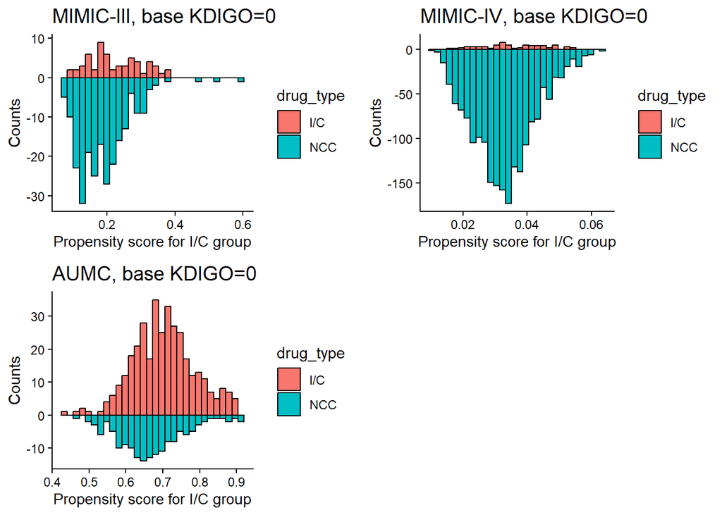

```r
#histogram
gridExtra::grid.arrange(
HISTO(readRDS("wgt_man_Ovlp_MIMIC3_base0.rds"), "MIMIC-III, base KDIGO=0"),
HISTO(readRDS("wgt_man_Ovlp_MIMIC4_base0.rds"), "MIMIC-IV, base KDIGO=0"),
HISTO(readRDS("wgt_man_Ovlp_AUMC_base0.rds"), "AUMC, base KDIGO=0"), nrow=2)
```

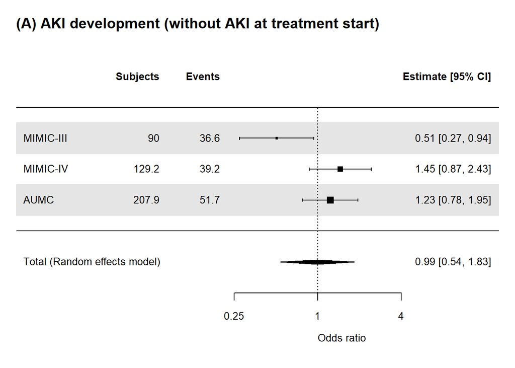

```r
#Forrestplot
FP2("wgt_man_Ovlp_MIMIC3_base0.rds", FORMULA_ovl2)
FP2("wgt_man_Ovlp_MIMIC4_base0.rds", FORMULA_ovl2)
FP2("wgt_man_Ovlp_AUMC_base0.rds", FORMULA_ovl2)



#
base0_METADF0 <- rbind(
  readRDS("ORRES_wgt_man_Ovlp_MIMIC3_base0.rds") %>% mutate("dataset"="MIMIC-III"),
  readRDS("ORRES_wgt_man_Ovlp_MIMIC4_base0.rds") %>% mutate("dataset"="MIMIC-IV"),
  readRDS("ORRES_wgt_man_Ovlp_AUMC_base0.rds") %>% mutate("dataset"="AUMC"))
base0_METADF_AKID <- base0_METADF0 %>% subset(outcome=="outcome_KDIGO_inc_or_death")
base0_METADF_AKI <- base0_METADF0 %>% subset(outcome=="outcome_KDIGO_inc")
base0_METADF_HD <- base0_METADF0 %>% subset(outcome=="outcome_new_dial")
base0_METADF_D <- base0_METADF0 %>% subset(outcome=="death_in_7d")
base0_METADF_HDD <- base0_METADF0 %>% subset(outcome=="outcome_HDD_in7d")
base0_METARES_AKID <- rma(yi = Estimate, sei = Std.Error, method = "REML", data = base0_METADF_AKID)
base0_METARES_AKI<-rma(yi = Estimate, sei = Std.Error, method = "REML", data = base0_METADF_AKI)
base0_METARES_HD<-rma(yi = Estimate, sei = Std.Error, method = "REML", data = base0_METADF_HD)
base0_METARES_D<-rma(yi = Estimate, sei = Std.Error, method = "REML", data = base0_METADF_D)
base0_METARES_HDD<-rma(yi = Estimate, sei = Std.Error, method = "REML", data = base0_METADF_HDD)

METAF(base0_METARES_AKI, SCALEA1, SCALEB1, SCALEC1, "(A) AKI development (without AKI at treatment start)")
```

```r
base0_METARES_AKI
```

```
##
## Random-Effects Model (k = 3; tau^2 estimator: REML)
##
## tau^2 (estimated amount of total heterogeneity): 0.2201 (SE = 0.2931)
## tau (square root of estimated tau^2 value):      0.4691
## I^2 (total heterogeneity / total variability):   75.45%
## H^2 (total variability / sampling variability):  4.07
##
## Test for Heterogeneity:
## Q(df = 2) = 7.3956, p-val = 0.0248
##
## Model Results:
##
## estimate      se     zval    pval    ci.lb   ci.ub
##  -0.0065  0.3124  -0.0208  0.9834  -0.6189  0.6059
##
## ---
## Signif. codes:  0 '***' 0.001 '**' 0.01 '*' 0.05 '.' 0.1 ' ' 1
```

```r
base0_METADF_AKI %>% dplyr::select(dataset, OR, LCI, UCI, 'Pr(>|z|)') %>% remove_rownames()
```

```
##     dataset        OR       LCI       UCI   Pr(>|z|)
## 1 MIMIC-III 0.5073909 0.2743903 0.9382459 0.03052592
## 2  MIMIC-IV 1.4541479 0.8691194 2.4329752 0.15392719
## 3      AUMC 1.2347319 0.7819866 1.9496022 0.36559571
```

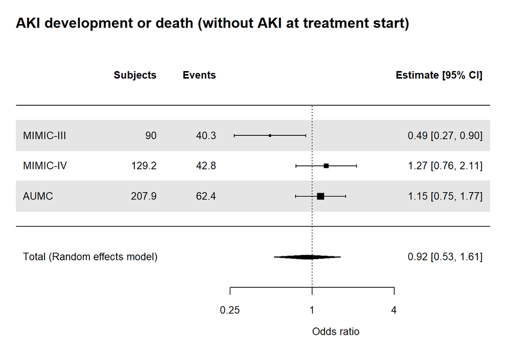

```r
METAF(base0_METARES_AKID, SCALEA1, SCALEB1, SCALEC1, "AKI development or death (without AKI at treatment start)")
```

```r
base0_METARES_AKID
```

```
##
## Random-Effects Model (k = 3; tau^2 estimator: REML)
##
## tau^2 (estimated amount of total heterogeneity): 0.1764 (SE = 0.2450)
## tau (square root of estimated tau^2 value):      0.4200
## I^2 (total heterogeneity / total variability):   72.46%
## H^2 (total variability / sampling variability):  3.63
##
## Test for Heterogeneity:
## Q(df = 2) = 6.6160, p-val = 0.0366
##
## Model Results:
##
## estimate      se     zval    pval    ci.lb   ci.ub
##  -0.0824  0.2855  -0.2887  0.7728  -0.6421  0.4772
##
## ---
## Signif. codes:  0 '***' 0.001 '**' 0.01 '*' 0.05 '.' 0.1 ' ' 1
```

```r
base0_METADF_AKID %>% dplyr::select(dataset, OR, LCI, UCI, 'Pr(>|z|)') %>% remove_rownames()
```

```
##     dataset        OR       LCI       UCI  Pr(>|z|)
## 1 MIMIC-III 0.4902962 0.2681534 0.8964656 0.0206158
## 2  MIMIC-IV 1.2688380 0.7626127 2.1110976 0.3593281
## 3      AUMC 1.1540028 0.7543196 1.7654618 0.5090689
```

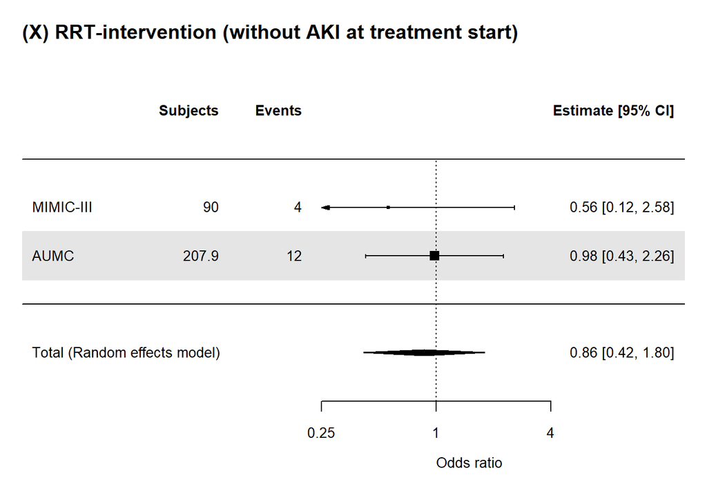

```r
METAF(base0_METARES_HD, SCALEA1, SCALEB1, SCALEC1, "(X) RRT-intervention (without AKI at treatment start)")
```

```r
base0_METARES_HD
```

```
##
## Random-Effects Model (k = 2; tau^2 estimator: REML)
##
## tau^2 (estimated amount of total heterogeneity): 0 (SE = 0.5566)
## tau (square root of estimated tau^2 value):      0
## I^2 (total heterogeneity / total variability):   0.00%
## H^2 (total variability / sampling variability):  1.00
##
## Test for Heterogeneity:
## Q(df = 1) = 0.3987, p-val = 0.5278
##
## Model Results:
##
## estimate      se     zval    pval    ci.lb   ci.ub
##  -0.1461  0.3733  -0.3915  0.6955  -0.8778  0.5855
##
## ---
## Signif. codes:  0 '***' 0.001 '**' 0.01 '*' 0.05 '.' 0.1 ' ' 1
```

```r
base0_METADF_HD %>% dplyr::select(dataset, OR, LCI, UCI, 'Pr(>|z|)') %>% remove_rownames()
```

```
##     dataset        OR       LCI      UCI  Pr(>|z|)
## 1 MIMIC-III 0.5612730 0.1220274 2.581611 0.4582026
## 2  MIMIC-IV 0.0000000       NaN      NaN       NaN
## 3      AUMC 0.9827992 0.4269675 2.262220 0.9674635
```

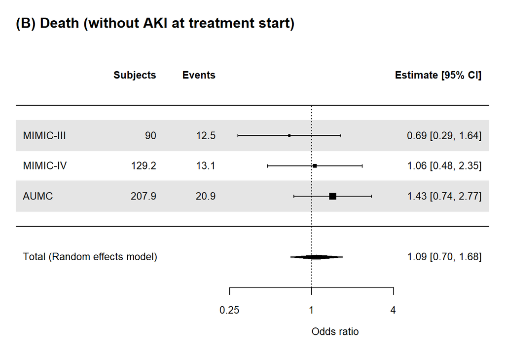

```r
METAF(base0_METARES_D, SCALEA1, SCALEB1, SCALEC1, "(B) Death (without AKI at treatment start)")
```

```r
base0_METARES_D
```

```
##
## Random-Effects Model (k = 3; tau^2 estimator: REML)
##
## tau^2 (estimated amount of total heterogeneity): 0 (SE = 0.1530)
## tau (square root of estimated tau^2 value):      0
## I^2 (total heterogeneity / total variability):   0.00%
## H^2 (total variability / sampling variability):  1.00
##
## Test for Heterogeneity:
## Q(df = 2) = 1.7424, p-val = 0.4184
##
## Model Results:
##
## estimate      se    zval    pval    ci.lb   ci.ub
##   0.0819  0.2239  0.3660  0.7143  -0.3568  0.5207
##
## ---
## Signif. codes:  0 '***' 0.001 '**' 0.01 '*' 0.05 '.' 0.1 ' ' 1
```

```r
base0_METADF_D %>% dplyr::select(dataset, OR, LCI, UCI, 'Pr(>|z|)') %>% remove_rownames()
```

```
##     dataset        OR       LCI      UCI  Pr(>|z|)
## 1 MIMIC-III 0.6875959 0.2878298 1.642596 0.3992278
## 2  MIMIC-IV 1.0591647 0.4768467 2.352601 0.8877352
## 3      AUMC 1.4328550 0.7416450 2.768270 0.2844240
```

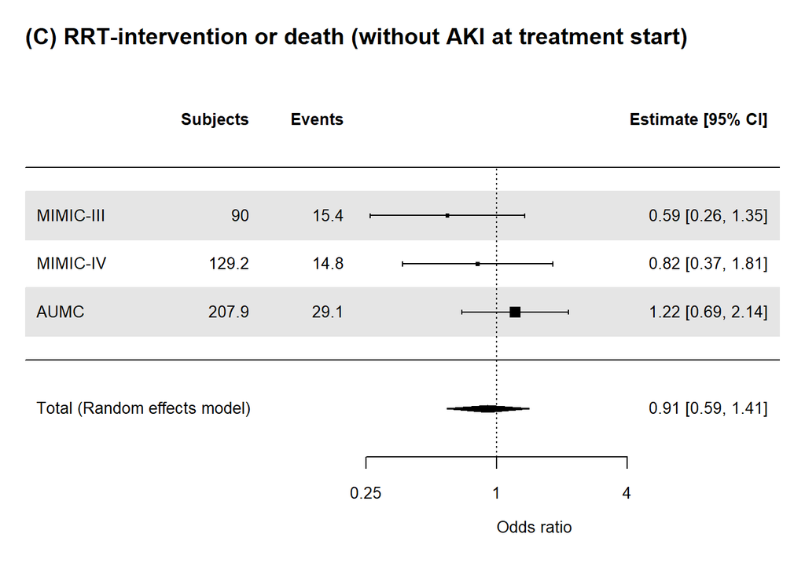

```r
METAF(base0_METARES_HDD, SCALEA1, SCALEB1, SCALEC1, "(C) RRT-intervention or death (without AKI at treatment start)")
```

```r
base0_METARES_HDD
```

```
##
## Random-Effects Model (k = 3; tau^2 estimator: REML)
##
## tau^2 (estimated amount of total heterogeneity): 0.0211 (SE = 0.1540)
## tau (square root of estimated tau^2 value):      0.1452
## I^2 (total heterogeneity / total variability):   13.54%
## H^2 (total variability / sampling variability):  1.16
##
## Test for Heterogeneity:
## Q(df = 2) = 2.1117, p-val = 0.3479
##
## Model Results:
##
## estimate      se     zval    pval    ci.lb   ci.ub
##  -0.0926  0.2229  -0.4155  0.6778  -0.5295  0.3443
##
## ---
## Signif. codes:  0 '***' 0.001 '**' 0.01 '*' 0.05 '.' 0.1 ' ' 1
```

```r
base0_METADF_HDD %>% dplyr::select(dataset, OR, LCI, UCI, 'Pr(>|z|)') %>% remove_rownames()
```

```
##     dataset        OR       LCI      UCI  Pr(>|z|)
## 1 MIMIC-III 0.5947958 0.2625683 1.347391 0.2130289
## 2  MIMIC-IV 0.8184505 0.3695917 1.812436 0.6213711
## 3      AUMC 1.2157598 0.6913008 2.138102 0.4976008
```

__

#### 4d. Backgrounds, outcomes, matching quality, and forest plot among those **with AKI** at treatment start.

```r
#1. overlap-PSM using MIMIC3, base KDIGO=0
OVLP(comb_DF2ovl %>% subset(dataset=="MIMIC3"&base_KDIGO>0.1&base_KDIGO<3), FORMULA_ovl2, "Ovlp_MIMIC3_base12", "**Ovlp, MIMIC-III, base_KDIGO 1,2**")
```

| **Characteristic** | **Ovlp, MIMIC-III, base_KDIGO 1,2** **I/C** N=14.4<sup>1</sup> | **Ovlp, MIMIC-III, base_KDIGO 1,2** **NCC** N=14.4<sup>1</sup> | **p-value**<sup>2</sup> |  |
| --- | --- | --- | --- | --- |
| dataset |  |  |  |  |
| MIMIC3 | 14.4 (100.0%) | 14.4 (100.0%) |  |  |
| age_group |  |  | >0.99 |  |
| 18-39 | 0.8 (5.8%) | 0.6 (4.2%) |  |  |
| 40-49 | 0.8 (5.7%) | 1.4 (10.0%) |  |  |
| 50-59 | 2.3 (16.3%) | 2.3 (15.7%) |  |  |
| 60-69 | 3.8 (26.4%) | 3.2 (22.3%) |  |  |
| 70-79 | 4.3 (29.7%) | 4.5 (31.0%) |  |  |
| 80+ | 2.3 (16.1%) | 2.4 (16.7%) |  |  |
| sex |  |  | >0.99 |  |
| Female | 8.0 (55.1%) | 8.0 (55.1%) |  |  |
| Male | 6.5 (44.9%) | 6.5 (44.9%) |  |  |
| bmi | 26.0 (25.4, 29.2) | 27.8 (25.3, 35.7) | 0.36 |  |
| Unknown | 7 | 9 |  |  |
| ICU type |  |  | >0.99 |  |
| Non-surgery | 11.9 (82.7%) | 11.9 (82.7%) |  |  |
| Surgery | 2.5 (17.3%) | 2.5 (17.3%) |  |  |
| drug_name |  |  |  |  |
| Imipenem/cilastatin | 14.4 (100.0%) | 0.0 (0.0%) |  |  |
| Imipenem/cilastatin/relebactam | 0.0 (0.0%) | 0.0 (0.0%) |  |  |
| Meropenem | 0.0 (0.0%) | 14.4 (100.0%) |  |  |
| Doripenem | 0.0 (0.0%) | 0.0 (0.0%) |  |  |
| Ertapenem | 0.0 (0.0%) | 0.0 (0.0%) |  |  |
| sofa | 6.0 (4.0, 8.0) | 5.0 (3.0, 7.0) | 0.23 |  |
| qsofa | 1.0 (0.0, 1.0) | 1.0 (0.0, 1.0) | 0.44 |  |
| Unknown | 0 | 1 |  |  |
| sirs | 2.0 (2.0, 2.0) | 2.0 (1.0, 3.0) | 0.69 |  |
| pre_blood_culture | 12.0 (83.2%) | 12.0 (83.2%) | >0.99 |  |
| pre vancomycin use | 4.1 (28.6%) | 4.1 (28.6%) | >0.99 |  |
| pre vasopressor use | 5.3 (36.8%) | 5.3 (36.8%) | >0.99 |  |
| pre ventilation | 9.8 (67.6%) | 9.3 (64.5%) | 0.81 |  |
| Baseline sCr | 0.8 (0.5, 1.4) | 1.0 (0.6, 1.5) | 0.80 |  |
| sCr at treatment start | 1.3 (1.0, 1.9) | 1.5 (1.1, 2.2) | 0.75 |  |
| AKI stage at treatment start |  |  | >0.99 |  |
| 1 | 12.8 (88.9%) | 12.8 (88.9%) |  |  |
| 2 | 1.6 (11.1%) | 1.6 (11.1%) |  |  |
| observation time | 168.0 (153.8, 168.0) | 168.0 (168.0, 168.0) | 0.61 |  |
| Cencsored with drug change | 0.8 (5.7%) | 0.0 (0.0%) | 0.30 |  |
| RRT at treatment start | 0.0 (0.0%) | 0.0 (0.0%) |  |  |
| O, AKI develop/progress | 0.0 (0.0%) | 2.1 (14.2%) | 0.001 |  |
| O, Death | 2.0 (13.6%) | 1.5 (10.5%) | 0.69 |  |
| O, AKI d/p or death | 2.0 (13.6%) | 3.0 (20.9%) | 0.47 |  |
| O, RRT-intervention | 0.0 (0.0%) | 0.5 (3.3%) | 0.13 |  |
| O, Death or RRT-intervention | 2.0 (13.6%) | 1.8 (12.5%) | 0.89 |  |

<sup>1</sup> n (%); Median (Q1, Q3)  
<sup>2</sup> NA; Pearson’s X^2: Rao & Scott adjustment; Design-based KruskalWallis test

```r
#2. overlap-PSM using MIMIC4, base KDIGO=0
OVLP(comb_DF2ovl %>% subset(dataset=="miiv"&base_KDIGO>0.1&base_KDIGO<3), FORMULA_ovl2, "Ovlp_MIMIC4_base12", "**Ovlp, MIMIC-IV, base_KDIGO 1,2**")
```

| **Characteristic** | **Ovlp, MIMIC-IV, base_KDIGO 1,2** **I/C** N=20.2<sup>1</sup> | **Ovlp, MIMIC-IV, base_KDIGO 1,2** **NCC** N=20.2<sup>1</sup> | **p-value**<sup>2</sup> |  |
| --- | --- | --- | --- | --- |
| dataset |  |  |  |  |
| miiv | 20.2 (100.0%) | 20.2 (100.0%) |  |  |
| age_group |  |  | 0.35 |  |
| 18-39 | 0.0 (0.0%) | 0.5 (2.4%) |  |  |
| 40-49 | 2.0 (9.8%) | 1.0 (5.0%) |  |  |
| 50-59 | 1.0 (4.8%) | 2.8 (14.1%) |  |  |
| 60-69 | 6.8 (33.6%) | 5.2 (25.8%) |  |  |
| 70-79 | 6.7 (33.2%) | 5.4 (26.8%) |  |  |
| 80+ | 3.8 (18.6%) | 5.2 (25.8%) |  |  |
| sex |  |  | >0.99 |  |
| Female | 7.8 (38.4%) | 7.8 (38.4%) |  |  |
| Male | 12.5 (61.6%) | 12.5 (61.6%) |  |  |
| bmi | 29.9 (25.4, 33.6) | 28.0 (23.9, 33.0) | 0.36 |  |
| Unknown | 11 | 6 |  |  |
| ICU type |  |  | >0.99 |  |
| Non-surgery | 15.4 (76.4%) | 15.4 (76.4%) |  |  |
| Surgery | 4.8 (23.6%) | 4.8 (23.6%) |  |  |
| drug_name |  |  |  |  |
| Imipenem/cilastatin | 20.2 (100.0%) | 0.0 (0.0%) |  |  |
| Imipenem/cilastatin/relebactam | 0.0 (0.0%) | 0.0 (0.0%) |  |  |
| Meropenem | 0.0 (0.0%) | 20.2 (99.9%) |  |  |
| Doripenem | 0.0 (0.0%) | 0.0 (0.1%) |  |  |
| Ertapenem | 0.0 (0.0%) | 0.0 (0.0%) |  |  |
| sofa | 6.0 (4.0, 9.0) | 8.0 (5.0, 11.0) | 0.25 |  |
| qsofa | 1.0 (0.0, 1.0) | 1.0 (0.0, 1.0) | 0.70 |  |
| Unknown | 0 | 0 |  |  |
| sirs | 2.0 (1.0, 3.0) | 2.0 (1.0, 3.0) | 0.94 |  |
| pre_blood_culture | 16.5 (81.5%) | 16.5 (81.5%) | >0.99 |  |
| pre vancomycin use | 13.5 (66.7%) | 13.5 (66.7%) | >0.99 |  |
| pre vasopressor use | 3.9 (19.4%) | 3.9 (19.4%) | >0.99 |  |
| pre ventilation | 4.9 (24.2%) | 3.8 (18.6%) | 0.53 |  |
| Baseline sCr | 1.3 (0.9, 1.7) | 1.2 (0.8, 1.7) | 0.87 |  |
| sCr at treatment start | 2.3 (1.5, 2.7) | 1.9 (1.4, 2.7) | 0.75 |  |
| AKI stage at treatment start |  |  | >0.99 |  |
| 1 | 15.4 (76.2%) | 15.4 (76.2%) |  |  |
| 2 | 4.8 (23.8%) | 4.8 (23.8%) |  |  |
| observation time | 168.0 (98.7, 168.0) | 168.0 (168.0, 168.0) | 0.78 |  |
| Unknown | 2 | 2 |  |  |
| Cencsored with drug change | 0.0 (0.0%) | 0.0 (0.0%) |  |  |
| RRT at treatment start | 0.0 (0.0%) | 0.0 (0.0%) |  |  |
| O, AKI develop/progress | 8.7 (43.1%) | 8.7 (42.9%) | 0.99 |  |
| O, Death | 6.8 (33.7%) | 6.1 (30.2%) | 0.73 |  |
| O, AKI d/p or death | 9.7 (47.8%) | 11.7 (57.7%) | 0.37 |  |
| O, RRT-intervention | 2.9 (14.4%) | 3.0 (14.6%) | 0.98 |  |
| O, Death or RRT-intervention | 7.8 (38.5%) | 7.8 (38.7%) | 0.99 |  |

<sup>1</sup> n (%); Median (Q1, Q3)  
<sup>2</sup> NA; Pearson’s X^2: Rao & Scott adjustment; Design-based KruskalWallis test

```r
#3. overlap-PSM using AUMC, base KDIGO=0
OVLP(comb_DF2ovl %>% subset(dataset=="AUMC"&base_KDIGO>0.1&base_KDIGO<3), FORMULA_ovl2, "Ovlp_AUMC_base12", "**Ovlp, AUMC, base_KDIGO 1,2**")
```

| **Characteristic** | **Ovlp, AUMC, base_KDIGO 1,2** **I/C** N=35.9<sup>1</sup> | **Ovlp, AUMC, base_KDIGO 1,2** **NCC** N=35.9<sup>1</sup> | **p-value**<sup>2</sup> |  |
| --- | --- | --- | --- | --- |
| dataset |  |  |  |  |
| AUMC | 35.9 (100.0%) | 35.9 (100.0%) |  |  |
| age_group |  |  | 0.70 |  |
| 18-39 | 3.6 (10.1%) | 4.0 (11.2%) |  |  |
| 40-49 | 2.1 (5.9%) | 2.3 (6.4%) |  |  |
| 50-59 | 7.0 (19.4%) | 5.1 (14.2%) |  |  |
| 60-69 | 11.5 (32.0%) | 11.4 (31.6%) |  |  |
| 70-79 | 9.3 (26.0%) | 12.3 (34.4%) |  |  |
| 80+ | 2.3 (6.5%) | 0.8 (2.2%) |  |  |
| sex |  |  | >0.99 |  |
| Female | 12.9 (35.9%) | 12.9 (35.9%) |  |  |
| Male | 23.0 (64.1%) | 23.0 (64.1%) |  |  |
| bmi | 24.5 (21.9, 27.8) | 24.8 (23.9, 27.8) | 0.13 |  |
| Unknown | 2 | 0 |  |  |
| ICU type |  |  | >0.99 |  |
| Non-surgery | 20.3 (56.6%) | 20.3 (56.6%) |  |  |
| Surgery | 15.6 (43.4%) | 15.6 (43.4%) |  |  |
| drug_name |  |  |  |  |
| Imipenem/cilastatin | 35.9 (100.0%) | 0.0 (0.0%) |  |  |
| Imipenem/cilastatin/relebactam | 0.0 (0.0%) | 0.0 (0.0%) |  |  |
| Meropenem | 0.0 (0.0%) | 35.9 (100.0%) |  |  |
| Doripenem | 0.0 (0.0%) | 0.0 (0.0%) |  |  |
| Ertapenem | 0.0 (0.0%) | 0.0 (0.0%) |  |  |
| sofa | 8.0 (5.0, 10.0) | 9.0 (7.0, 11.0) | 0.29 |  |
| Unknown | 5 | 6 |  |  |
| qsofa | 1.0 (0.0, 1.0) | 1.0 (0.0, 1.0) | 0.90 |  |
| sirs | 2.0 (2.0, 3.0) | 2.0 (2.0, 3.0) | 0.81 |  |
| pre_blood_culture | 4.4 (12.2%) | 4.4 (12.2%) | >0.99 |  |
| pre vancomycin use | 18.3 (51.0%) | 18.3 (51.0%) | >0.99 |  |
| pre vasopressor use | 24.9 (69.5%) | 24.9 (69.5%) | >0.99 |  |
| pre ventilation | 23.7 (66.1%) | 20.5 (57.1%) | 0.27 |  |
| Baseline sCr | 1.0 (0.7, 1.3) | 1.0 (0.7, 1.3) | 0.99 |  |
| sCr at treatment start | 1.6 (1.2, 2.3) | 1.6 (1.2, 2.3) | 0.99 |  |
| AKI stage at treatment start |  |  | >0.99 |  |
| 1 | 28.0 (77.9%) | 28.0 (77.9%) |  |  |
| 2 | 7.9 (22.1%) | 7.9 (22.1%) |  |  |
| observation time | 168.0 (67.7, 168.0) | 133.6 (54.8, 168.0) | 0.39 |  |
| Cencsored with drug change | 1.5 (4.3%) | 0.0 (0.0%) | 0.037 |  |
| RRT at treatment start | 0.0 (0.0%) | 0.0 (0.0%) |  |  |
| O, AKI develop/progress | 13.0 (36.1%) | 16.1 (44.8%) | 0.29 |  |
| O, Death | 6.4 (17.9%) | 9.2 (25.7%) | 0.25 |  |
| O, AKI d/p or death | 15.0 (41.7%) | 19.0 (53.0%) | 0.18 |  |
| O, RRT-intervention | 7.2 (20.0%) | 9.3 (26.0%) | 0.40 |  |
| O, Death or RRT-intervention | 10.9 (30.2%) | 13.4 (37.2%) | 0.38 |  |

<sup>1</sup> n (%); Median (Q1, Q3)  
<sup>2</sup> NA; Pearson’s X^2: Rao & Scott adjustment; Design-based KruskalWallis test

```r
#ROC
roc(readRDS("wgt_man_Ovlp_MIMIC3_base12.rds")$treat, readRDS("wgt_man_Ovlp_MIMIC3_base12.rds")$ps_for_IMI)%>%auc()%>%round(.,digits = 2)%>%paste0("ovlp_AUC base 1,2 (MIMIC3) = ", .)
```

```
## [1] "ovlp_AUC base 1,2 (MIMIC3) = 0.73"
```

```r
roc(readRDS("wgt_man_Ovlp_MIMIC4_base12.rds")$treat, readRDS("wgt_man_Ovlp_MIMIC4_base12.rds")$ps_for_IMI)%>%auc()%>%round(.,digits = 2)%>%paste0("ovlp_AUC base 1,2 (MIMIC4) = ", .)
```

```
## [1] "ovlp_AUC base 1,2 (MIMIC4) = 0.51"
```

```r
roc(readRDS("wgt_man_Ovlp_AUMC_base12.rds")$treat, readRDS("wgt_man_Ovlp_AUMC_base12.rds")$ps_for_IMI) %>%auc()%>%round(., digits = 2)%>%paste0("ovlp_AUC base 1,2 (AUMC) = ", .)
```

```
## [1] "ovlp_AUC base 1,2 (AUMC) = 0.69"
```

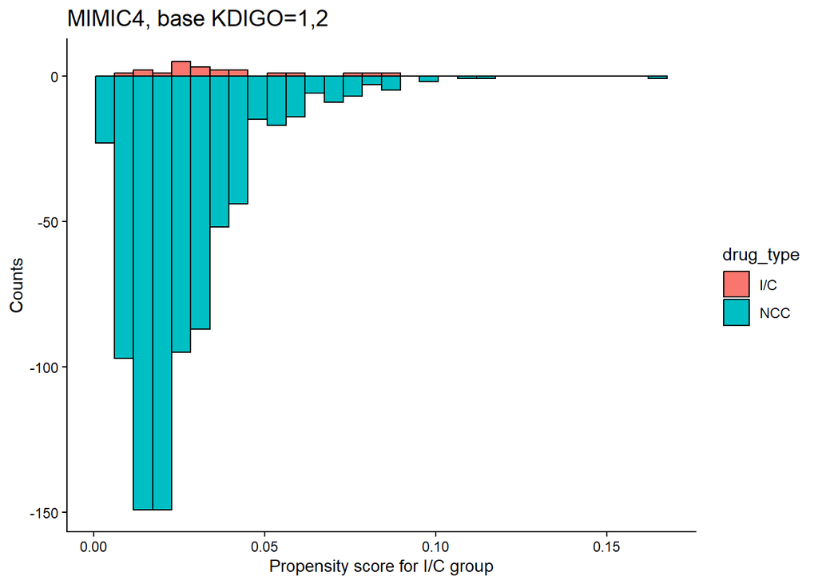

```r
#histogram
HISTO(readRDS("wgt_man_Ovlp_MIMIC4_base12.rds"), "MIMIC4, base KDIGO=1,2")
```

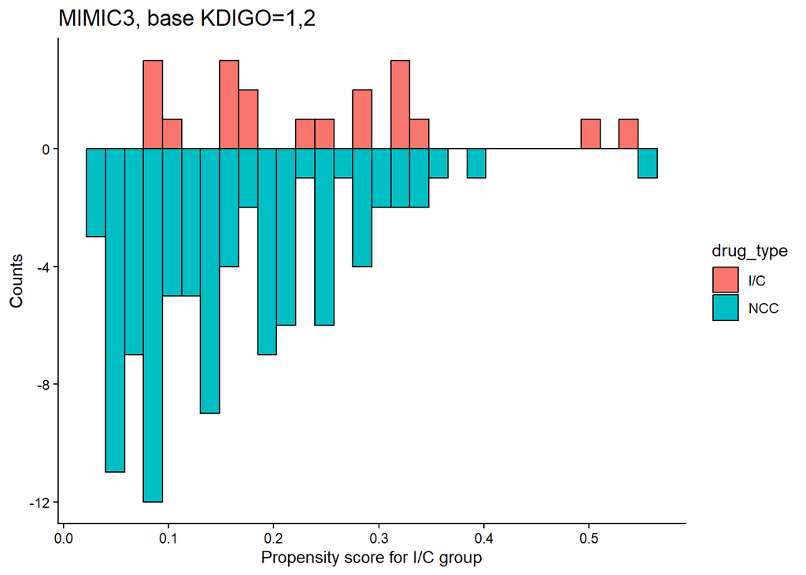

```r
HISTO(readRDS("wgt_man_Ovlp_MIMIC3_base12.rds"), "MIMIC3, base KDIGO=1,2")
```

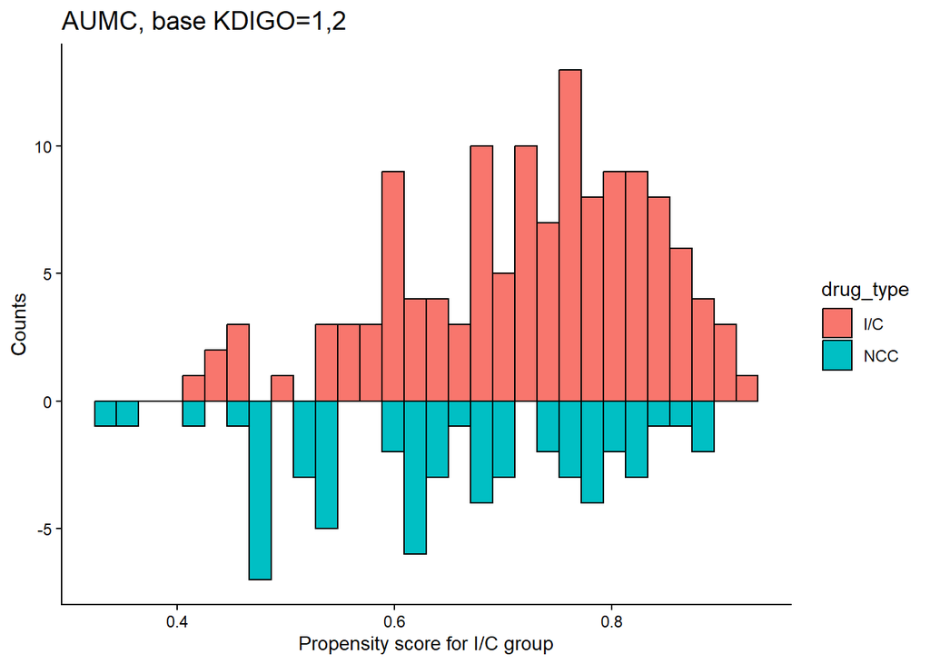

```r
HISTO(readRDS("wgt_man_Ovlp_AUMC_base12.rds"), "AUMC, base KDIGO=1,2")
```

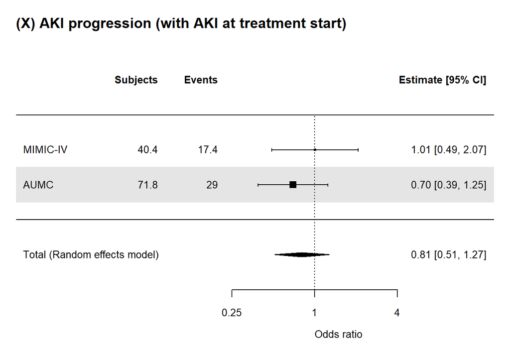

```r
FP2("wgt_man_Ovlp_MIMIC4_base12.rds", FORMULA_ovl2)
FP2("wgt_man_Ovlp_MIMIC3_base12.rds", FORMULA_ovl2)
FP2("wgt_man_Ovlp_AUMC_base12.rds", FORMULA_ovl2)

base12_METADF0 <- rbind(
  readRDS("ORRES_wgt_man_Ovlp_MIMIC3_base12.rds") %>% mutate("dataset"="MIMIC-III"),
  readRDS("ORRES_wgt_man_Ovlp_MIMIC4_base12.rds") %>% mutate("dataset"="MIMIC-IV"),
  readRDS("ORRES_wgt_man_Ovlp_AUMC_base12.rds") %>% mutate("dataset"="AUMC"))
base12_METADF_AKID <- base12_METADF0 %>% subset(outcome=="outcome_KDIGO_inc_or_death")
base12_METADF_AKI <- base12_METADF0 %>% subset(outcome=="outcome_KDIGO_inc")
base12_METADF_HD <- base12_METADF0 %>% subset(outcome=="outcome_new_dial")
base12_METADF_D <- base12_METADF0 %>% subset(outcome=="death_in_7d")
base12_METADF_HDD <- base12_METADF0 %>% subset(outcome=="outcome_HDD_in7d")

base12_METARES_AKID <- rma(yi = Estimate, sei = Std.Error, method = "REML", data = base12_METADF_AKID)
base12_METARES_AKI <-rma(yi = Estimate, sei = Std.Error, method = "REML", data = base12_METADF_AKI)
base12_METARES_HD <- rma(yi = Estimate, sei = Std.Error, method = "REML", data = base12_METADF_HD)
base12_METARES_D <- rma(yi = Estimate, sei = Std.Error, method = "REML", data = base12_METADF_D)
base12_METARES_HDD <- rma(yi = Estimate, sei = Std.Error, method = "REML", data = base12_METADF_HDD)

METAF(base12_METARES_AKI, SCALEA1, SCALEB1, SCALEC1, "(X) AKI progression (with AKI at treatment start)")
```

```r
base12_METARES_AKI
```

```
##
## Random-Effects Model (k = 2; tau^2 estimator: REML)
##
## tau^2 (estimated amount of total heterogeneity): 0 (SE = 0.1588)
## tau (square root of estimated tau^2 value):      0
## I^2 (total heterogeneity / total variability):   0.00%
## H^2 (total variability / sampling variability):  1.00
##
## Test for Heterogeneity:
## Q(df = 1) = 0.6037, p-val = 0.4372
##
## Model Results:
##
## estimate      se     zval    pval    ci.lb   ci.ub
##  -0.2152  0.2319  -0.9283  0.3532  -0.6697  0.2392
##
## ---
## Signif. codes:  0 '***' 0.001 '**' 0.01 '*' 0.05 '.' 0.1 ' ' 1
```

```r
base12_METADF_AKI %>% dplyr::select(dataset, OR, LCI, UCI, 'Pr(>|z|)') %>% remove_rownames()
```

```
##     dataset        OR       LCI      UCI  Pr(>|z|)
## 1 MIMIC-III 0.0000000       NaN      NaN       NaN
## 2  MIMIC-IV 1.0068511 0.4894405 2.071241 0.9851983
## 3      AUMC 0.6967048 0.3880709 1.250796 0.2261100
```

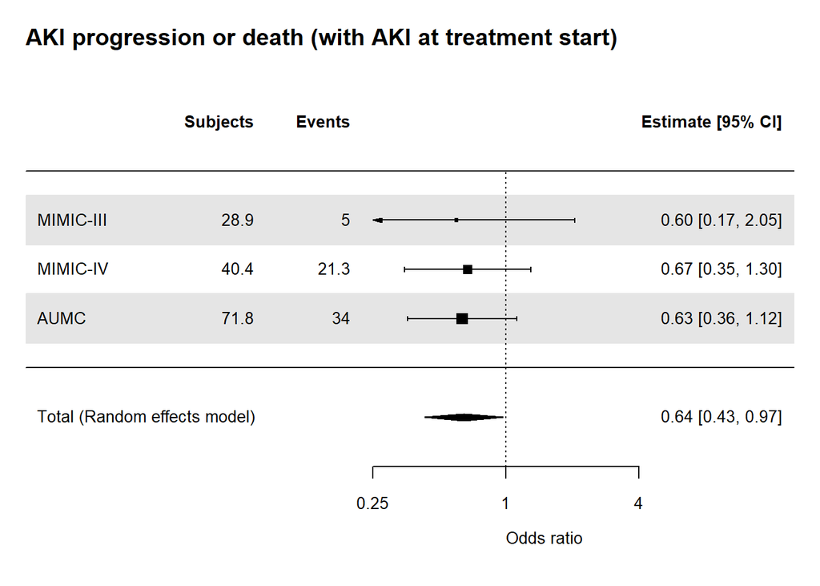

```r
METAF(base12_METARES_AKID, SCALEA1, SCALEB1, SCALEC1, "AKI progression or death (with AKI at treatment start)")
```

```r
base12_METARES_AKID
```

```
##
## Random-Effects Model (k = 3; tau^2 estimator: REML)
##
## tau^2 (estimated amount of total heterogeneity): 0 (SE = 0.1316)
## tau (square root of estimated tau^2 value):      0
## I^2 (total heterogeneity / total variability):   0.00%
## H^2 (total variability / sampling variability):  1.00
##
## Test for Heterogeneity:
## Q(df = 2) = 0.0334, p-val = 0.9834
##
## Model Results:
##
## estimate      se     zval    pval    ci.lb    ci.ub
##  -0.4388  0.2071  -2.1192  0.0341  -0.8447  -0.0330  *
##
## ---
## Signif. codes:  0 '***' 0.001 '**' 0.01 '*' 0.05 '.' 0.1 ' ' 1
```

```r
base12_METADF_AKID %>% dplyr::select(dataset, OR, LCI, UCI, 'Pr(>|z|)') %>% remove_rownames()
```

```
##     dataset        OR       LCI      UCI  Pr(>|z|)
## 1 MIMIC-III 0.5979216 0.1744354 2.049528 0.4132169
## 2  MIMIC-IV 0.6728783 0.3481069 1.300650 0.2387040
## 3      AUMC 0.6348032 0.3600302 1.119282 0.1162935
```

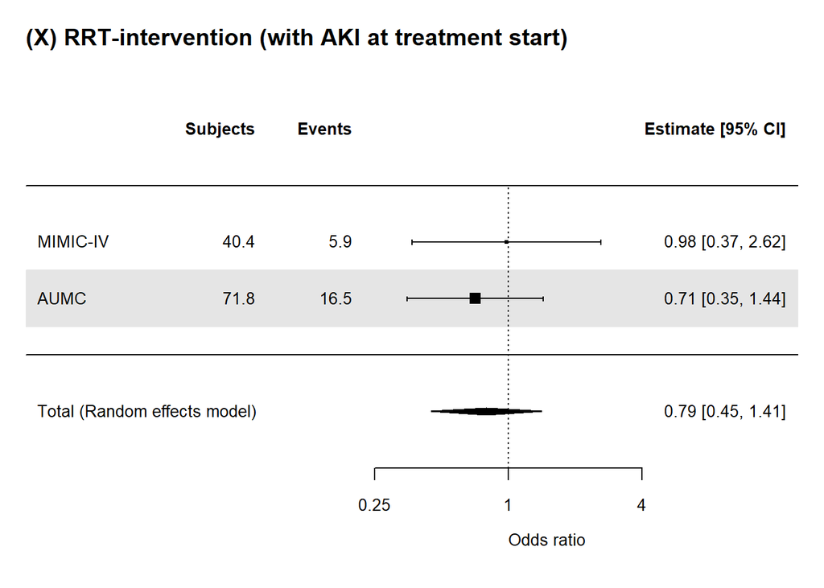

```r
METAF(base12_METARES_HD, SCALEA1, SCALEB1, SCALEC1, "(X) RRT-intervention (with AKI at treatment start)")
```

```r
base12_METARES_HD
```

```
##
## Random-Effects Model (k = 2; tau^2 estimator: REML)
##
## tau^2 (estimated amount of total heterogeneity): 0 (SE = 0.2682)
## tau (square root of estimated tau^2 value):      0
## I^2 (total heterogeneity / total variability):   0.00%
## H^2 (total variability / sampling variability):  1.00
##
## Test for Heterogeneity:
## Q(df = 1) = 0.2743, p-val = 0.6005
##
## Model Results:
##
## estimate      se     zval    pval    ci.lb   ci.ub
##  -0.2305  0.2921  -0.7892  0.4300  -0.8030  0.3419
##
## ---
## Signif. codes:  0 '***' 0.001 '**' 0.01 '*' 0.05 '.' 0.1 ' ' 1
```

```r
base12_METADF_HD %>% dplyr::select(dataset, OR, LCI, UCI, 'Pr(>|z|)') %>% remove_rownames()
```

```
##     dataset        OR       LCI      UCI  Pr(>|z|)
## 1 MIMIC-III 0.0000000       NaN      NaN       NaN
## 2  MIMIC-IV 0.9820338 0.3687649 2.615190 0.9710605
## 3      AUMC 0.7112747 0.3512726 1.440225 0.3438929
```

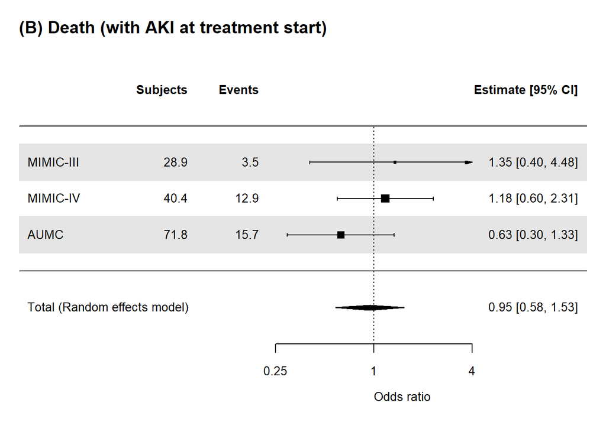

```r
METAF(base12_METARES_D, SCALEA1, SCALEB1, SCALEC1, "(B) Death (with AKI at treatment start)")
```

```r
base12_METARES_D
```

```
##
## Random-Effects Model (k = 3; tau^2 estimator: REML)
##
## tau^2 (estimated amount of total heterogeneity): 0.0123 (SE = 0.1852)
## tau (square root of estimated tau^2 value):      0.1110
## I^2 (total heterogeneity / total variability):   6.31%
## H^2 (total variability / sampling variability):  1.07
##
## Test for Heterogeneity:
## Q(df = 2) = 1.8661, p-val = 0.3934
##
## Model Results:
##
## estimate      se     zval    pval    ci.lb   ci.ub
##  -0.0546  0.2463  -0.2216  0.8246  -0.5372  0.4281
##
## ---
## Signif. codes:  0 '***' 0.001 '**' 0.01 '*' 0.05 '.' 0.1 ' ' 1
```

```r
base12_METADF_D %>% dplyr::select(dataset, OR, LCI, UCI, 'Pr(>|z|)') %>% remove_rownames()
```

```
##     dataset        OR       LCI      UCI  Pr(>|z|)
## 1 MIMIC-III 1.3467012 0.4048601 4.479582 0.6273864
## 2  MIMIC-IV 1.1761248 0.5992317 2.308405 0.6372757
## 3      AUMC 0.6285969 0.2962251 1.333898 0.2264958
```

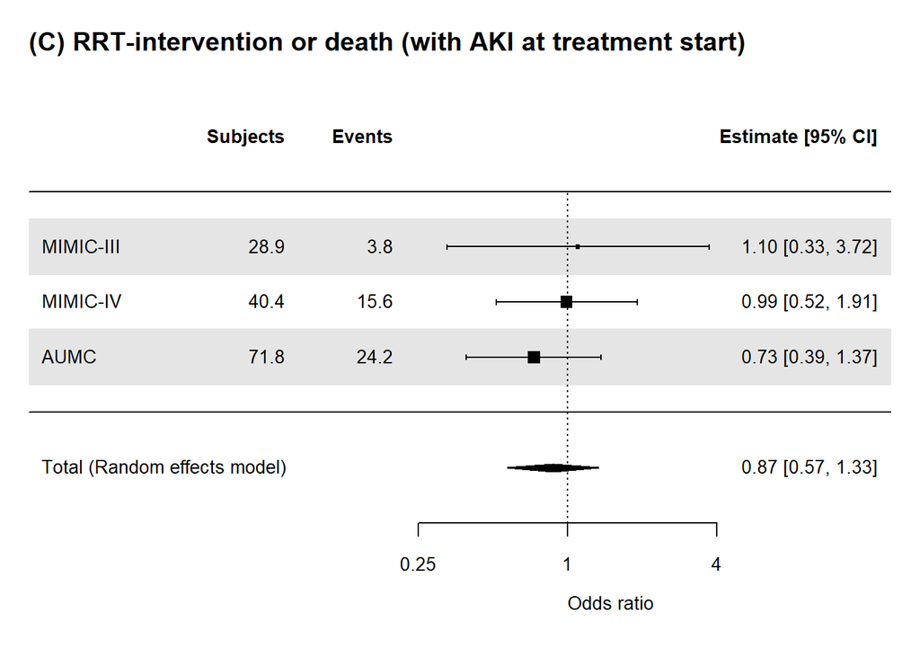

```r
METAF(base12_METARES_HDD, SCALEA1, SCALEB1, SCALEC1, "(C) RRT-intervention or death (with AKI at treatment start)")
```

```r
base12_METARES_HDD
```

```
##
## Random-Effects Model (k = 3; tau^2 estimator: REML)
##
## tau^2 (estimated amount of total heterogeneity): 0 (SE = 0.1412)
## tau (square root of estimated tau^2 value):      0
## I^2 (total heterogeneity / total variability):   0.00%
## H^2 (total variability / sampling variability):  1.00
##
## Test for Heterogeneity:
## Q(df = 2) = 0.5964, p-val = 0.7422
##
## Model Results:
##
## estimate      se     zval    pval    ci.lb   ci.ub
##  -0.1355  0.2159  -0.6276  0.5303  -0.5587  0.2877
##
## ---
## Signif. codes:  0 '***' 0.001 '**' 0.01 '*' 0.05 '.' 0.1 ' ' 1
```

```r
base12_METADF_HDD %>% dplyr::select(dataset, OR, LCI, UCI, 'Pr(>|z|)') %>% remove_rownames()
```

```
##     dataset        OR       LCI      UCI  Pr(>|z|)
## 1 MIMIC-III 1.1019186 0.3268158 3.715318 0.8756336
## 2  MIMIC-IV 0.9917817 0.5158778 1.906713 0.9802583
## 3      AUMC 0.7313675 0.3918166 1.365175 0.3258900
```

__

#### 5c. Backgrounds, outcomes, matching quality, and forrest plot among those **males** at treatment start.

```r
FORMULA_ovl2_sex <- drug01 ~  age_cat + dep_type2 + sirs + pre_blood_culture + treat_van + vasopressor + base_crea + near_crea +  base_KDIGO

#1. overlap-PSM using MIMIC3, "Male"
OVLP(comb_DF2ovl %>% subset(dataset=="MIMIC3"&sex=="Male"), FORMULA_ovl2_sex, "Ovlp_MIMIC3_Male", "**Ovlp, MIMIC-III, Male**")
```

| **Characteristic** | **Ovlp, MIMIC-III, Male** **I/C** N=31.0<sup>1</sup> | **Ovlp, MIMIC-III, Male** **NCC** N=31.0<sup>1</sup> | **p-value**<sup>2</sup> |  |
| --- | --- | --- | --- | --- |
| dataset |  |  |  |  |
| MIMIC3 | 31.0 (100.0%) | 31.0 (100.0%) |  |  |
| age_group |  |  | 0.76 |  |
| 18-39 | 2.5 (8.0%) | 2.5 (8.2%) |  |  |
| 40-49 | 4.4 (14.2%) | 3.4 (11.0%) |  |  |
| 50-59 | 6.7 (21.6%) | 6.6 (21.2%) |  |  |
| 60-69 | 5.6 (18.0%) | 6.2 (19.9%) |  |  |
| 70-79 | 5.4 (17.3%) | 8.2 (26.4%) |  |  |
| 80+ | 6.5 (21.0%) | 4.1 (13.3%) |  |  |
| sex |  |  |  |  |
| Male | 31.0 (100.0%) | 31.0 (100.0%) |  |  |
| bmi | 27.6 (24.9, 29.2) | 28.3 (23.7, 32.0) | 0.67 |  |
| Unknown | 11 | 14 |  |  |
| ICU type |  |  | >0.99 |  |
| Non-surgery | 16.5 (53.2%) | 16.5 (53.2%) |  |  |
| Surgery | 14.5 (46.8%) | 14.5 (46.8%) |  |  |
| drug_name |  |  |  |  |
| Imipenem/cilastatin | 31.0 (100.0%) | 0.0 (0.0%) |  |  |
| Imipenem/cilastatin/relebactam | 0.0 (0.0%) | 0.0 (0.0%) |  |  |
| Meropenem | 0.0 (0.0%) | 31.0 (100.0%) |  |  |
| Doripenem | 0.0 (0.0%) | 0.0 (0.0%) |  |  |
| Ertapenem | 0.0 (0.0%) | 0.0 (0.0%) |  |  |
| sofa | 5.0 (3.0, 8.0) | 4.0 (2.0, 7.0) | 0.43 |  |
| qsofa | 1.0 (0.0, 1.0) | 1.0 (0.0, 1.0) | 0.42 |  |
| Unknown | 0 | 1 |  |  |
| sirs | 2.0 (1.0, 3.0) | 2.0 (1.0, 3.0) | 0.89 |  |
| pre_blood_culture | 23.8 (76.7%) | 23.8 (76.7%) | >0.99 |  |
| pre vancomycin use | 10.2 (32.9%) | 10.2 (32.9%) | >0.99 |  |
| pre vasopressor use | 12.3 (39.6%) | 12.3 (39.6%) | >0.99 |  |
| pre ventilation | 23.8 (76.8%) | 21.3 (68.8%) | 0.33 |  |
| Baseline sCr | 0.9 (0.7, 1.4) | 0.9 (0.6, 1.5) | 0.92 |  |
| sCr at treatment start | 1.1 (0.8, 1.7) | 1.1 (0.7, 1.7) | 0.89 |  |
| AKI stage at treatment start |  |  | 0.34 |  |
| 0 | 24.4 (78.6%) | 24.9 (80.4%) |  |  |
| 1 | 6.6 (21.4%) | 5.5 (17.9%) |  |  |
| 2 | 0.0 (0.0%) | 0.5 (1.7%) |  |  |
| observation time | 168.0 (168.0, 168.0) | 168.0 (168.0, 168.0) | 0.73 |  |
| Cencsored with drug change | 1.5 (4.7%) | 0.2 (0.7%) | 0.068 |  |
| RRT at treatment start | 0.0 (0.0%) | 0.0 (0.0%) |  |  |
| O, AKI develop/progress | 8.5 (27.4%) | 12.6 (40.5%) | 0.13 |  |
| O, Death | 3.0 (9.8%) | 5.2 (16.6%) | 0.29 |  |
| O, AKI d/p or death | 10.0 (32.3%) | 14.3 (46.2%) | 0.12 |  |
| O, RRT-intervention | 1.4 (4.6%) | 1.9 (6.1%) | 0.71 |  |
| O, Death or RRT-intervention | 3.8 (12.3%) | 6.6 (21.3%) | 0.20 |  |

<sup>1</sup> n (%); Median (Q1, Q3)  
<sup>2</sup> NA; Pearson’s X^2: Rao & Scott adjustment; Design-based KruskalWallis test

```r
#2. overlap-PSM using MIMIC4, "Male"
OVLP(comb_DF2ovl %>% subset(dataset=="miiv"&sex=="Male"), FORMULA_ovl2_sex, "Ovlp_MIMIC4_Male", "**Ovlp, MIMIC-IV, Male**")
```

| **Characteristic** | **Ovlp, MIMIC-IV, Male** **I/C** N=48.4<sup>1</sup> | **Ovlp, MIMIC-IV, Male** **NCC** N=48.4<sup>1</sup> | **p-value**<sup>2</sup> |  |
| --- | --- | --- | --- | --- |
| dataset |  |  |  |  |
| miiv | 48.4 (100.0%) | 48.4 (100.0%) |  |  |
| age_group |  |  | 0.94 |  |
| 18-39 | 4.8 (10.0%) | 4.6 (9.5%) |  |  |
| 40-49 | 4.8 (10.0%) | 4.6 (9.5%) |  |  |
| 50-59 | 8.7 (18.0%) | 10.9 (22.5%) |  |  |
| 60-69 | 15.5 (32.0%) | 12.7 (26.4%) |  |  |
| 70-79 | 7.8 (16.0%) | 9.0 (18.7%) |  |  |
| 80+ | 6.7 (14.0%) | 6.5 (13.5%) |  |  |
| sex |  |  |  |  |
| Male | 48.4 (100.0%) | 48.4 (100.0%) |  |  |
| bmi | 27.1 (25.1, 31.1) | 27.2 (23.5, 32.3) | 0.48 |  |
| Unknown | 22 | 18 |  |  |
| ICU type |  |  | >0.99 |  |
| Non-surgery | 37.7 (77.9%) | 37.7 (77.9%) |  |  |
| Surgery | 10.7 (22.1%) | 10.7 (22.1%) |  |  |
| drug_name |  |  | <0.001 |  |
| Imipenem/cilastatin | 47.4 (98.0%) | 0.0 (0.0%) |  |  |
| Imipenem/cilastatin/relebactam | 1.0 (2.0%) | 0.0 (0.0%) |  |  |
| Meropenem | 0.0 (0.0%) | 48.0 (99.2%) |  |  |
| Doripenem | 0.0 (0.0%) | 0.1 (0.2%) |  |  |
| Ertapenem | 0.0 (0.0%) | 0.3 (0.6%) |  |  |
| sofa | 5.0 (3.0, 7.0) | 5.0 (3.0, 8.0) | 0.13 |  |
| qsofa | 1.0 (0.0, 1.0) | 1.0 (0.0, 1.0) | 0.39 |  |
| Unknown | 0 | 0 |  |  |
| sirs | 2.0 (1.0, 2.0) | 2.0 (1.0, 3.0) | 0.96 |  |
| pre_blood_culture | 35.9 (74.2%) | 35.9 (74.2%) | >0.99 |  |
| pre vancomycin use | 32.0 (66.1%) | 32.0 (66.1%) | >0.99 |  |
| pre vasopressor use | 3.9 (8.0%) | 3.9 (8.0%) | >0.99 |  |
| pre ventilation | 7.7 (16.0%) | 3.9 (8.0%) | 0.047 |  |
| Baseline sCr | 1.0 (0.7, 1.6) | 1.0 (0.7, 1.5) | 0.77 |  |
| sCr at treatment start | 1.1 (0.8, 1.9) | 1.2 (0.8, 1.8) | 0.85 |  |
| AKI stage at treatment start |  |  | >0.99 |  |
| 0 | 35.8 (73.9%) | 35.7 (73.8%) |  |  |
| 1 | 9.7 (20.0%) | 9.8 (20.2%) |  |  |
| 2 | 2.9 (6.0%) | 2.9 (5.9%) |  |  |
| observation time | 168.0 (109.5, 168.0) | 168.0 (152.7, 168.0) | 0.20 |  |
| Unknown | 8 | 5 |  |  |
| Cencsored with drug change | 1.9 (4.0%) | 0.0 (0.0%) | 0.15 |  |
| RRT at treatment start | 0.0 (0.0%) | 0.0 (0.0%) |  |  |
| O, AKI develop/progress | 21.3 (44.0%) | 15.4 (31.8%) | 0.071 |  |
| O, Death | 8.7 (18.0%) | 6.5 (13.4%) | 0.35 |  |
| O, AKI d/p or death | 22.3 (46.0%) | 18.2 (37.7%) | 0.23 |  |
| O, RRT-intervention | 1.0 (2.0%) | 3.2 (6.7%) | 0.19 |  |
| O, Death or RRT-intervention | 9.7 (20.0%) | 8.7 (18.1%) | 0.73 |  |

<sup>1</sup> n (%); Median (Q1, Q3)  
<sup>2</sup> NA; Pearson’s X^2: Rao & Scott adjustment; Design-based KruskalWallis test

```r
#3. overlap-PSM using AUMC, "Male"
OVLP(comb_DF2ovl %>% subset(dataset=="AUMC"&sex=="Male"), FORMULA_ovl2_sex, "Ovlp_AUMC_Male", paste0("**Ovlp, AUMC", ", Male**"))
```

| **Characteristic** | **Ovlp, AUMC, Male** **I/C** N=91.1<sup>1</sup> | **Ovlp, AUMC, Male** **NCC** N=91.1<sup>1</sup> | **p-value**<sup>2</sup> |  |
| --- | --- | --- | --- | --- |
| dataset |  |  |  |  |
| AUMC | 91.1 (100.0%) | 91.1 (100.0%) |  |  |
| age_group |  |  | 0.37 |  |
| 18-39 | 7.7 (8.4%) | 10.9 (12.0%) |  |  |
| 40-49 | 8.3 (9.2%) | 9.3 (10.2%) |  |  |
| 50-59 | 20.0 (22.0%) | 14.2 (15.6%) |  |  |
| 60-69 | 30.1 (33.1%) | 26.3 (28.9%) |  |  |
| 70-79 | 21.3 (23.4%) | 24.5 (26.9%) |  |  |
| 80+ | 3.7 (4.0%) | 5.8 (6.4%) |  |  |
| sex |  |  |  |  |
| Male | 91.1 (100.0%) | 91.1 (100.0%) |  |  |
| bmi | 24.5 (21.9, 27.8) | 24.8 (21.9, 27.8) | 0.70 |  |
| Unknown | 5 | 0 |  |  |
| ICU type |  |  | >0.99 |  |
| Non-surgery | 52.9 (58.1%) | 52.9 (58.1%) |  |  |
| Surgery | 38.1 (41.9%) | 38.1 (41.9%) |  |  |
| drug_name |  |  |  |  |
| Imipenem/cilastatin | 91.1 (100.0%) | 0.0 (0.0%) |  |  |
| Imipenem/cilastatin/relebactam | 0.0 (0.0%) | 0.0 (0.0%) |  |  |
| Meropenem | 0.0 (0.0%) | 91.1 (100.0%) |  |  |
| Doripenem | 0.0 (0.0%) | 0.0 (0.0%) |  |  |
| Ertapenem | 0.0 (0.0%) | 0.0 (0.0%) |  |  |
| sofa | 7.0 (4.0, 9.0) | 8.0 (4.0, 10.0) | 0.90 |  |
| Unknown | 14 | 14 |  |  |
| qsofa | 1.0 (0.0, 1.0) | 1.0 (0.0, 1.0) | 0.63 |  |
| Unknown | 0 | 0 |  |  |
| sirs | 2.0 (1.0, 3.0) | 2.0 (1.0, 3.0) | 0.97 |  |
| pre_blood_culture | 12.3 (13.5%) | 12.3 (13.5%) | >0.99 |  |
| pre vancomycin use | 48.8 (53.6%) | 48.8 (53.6%) | >0.99 |  |
| pre vasopressor use | 61.2 (67.2%) | 61.2 (67.2%) | >0.99 |  |
| pre ventilation | 61.3 (67.4%) | 58.0 (63.7%) | 0.46 |  |
| Baseline sCr | 0.9 (0.7, 1.3) | 0.8 (0.6, 1.2) | 0.32 |  |
| sCr at treatment start | 1.1 (0.8, 1.6) | 1.0 (0.7, 1.6) | 0.32 |  |
| AKI stage at treatment start |  |  | 0.77 |  |
| 0 | 66.3 (72.8%) | 67.4 (74.0%) |  |  |
| 1 | 19.9 (21.9%) | 17.7 (19.4%) |  |  |
| 2 | 4.8 (5.3%) | 6.0 (6.5%) |  |  |
| observation time | 168.0 (68.8, 168.0) | 146.0 (56.4, 168.0) | 0.15 |  |
| Cencsored with drug change | 3.3 (3.6%) | 0.8 (0.8%) | 0.12 |  |
| RRT at treatment start | 0.0 (0.0%) | 0.0 (0.0%) |  |  |
| O, AKI develop/progress | 25.9 (28.5%) | 28.6 (31.4%) | 0.54 |  |
| O, Death | 13.5 (14.8%) | 13.5 (14.8%) | 0.99 |  |
| O, AKI d/p or death | 32.1 (35.3%) | 34.7 (38.2%) | 0.57 |  |
| O, RRT-intervention | 8.4 (9.3%) | 12.2 (13.4%) | 0.20 |  |
| O, Death or RRT-intervention | 19.2 (21.1%) | 19.8 (21.7%) | 0.88 |  |

<sup>1</sup> n (%); Median (Q1, Q3)  
<sup>2</sup> NA; Pearson’s X^2: Rao & Scott adjustment; Design-based KruskalWallis test

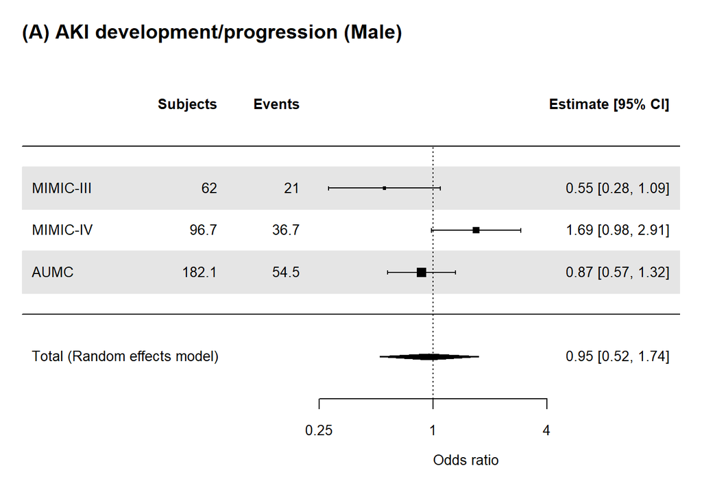

```r
#Forrestplot
FP2("wgt_man_Ovlp_MIMIC3_Male.rds", FORMULA_ovl2_sex)
FP2("wgt_man_Ovlp_MIMIC4_Male.rds", FORMULA_ovl2_sex)
FP2("wgt_man_Ovlp_AUMC_Male.rds", FORMULA_ovl2_sex)

Male_METADF0 <- rbind(
  readRDS("ORRES_wgt_man_Ovlp_MIMIC3_Male.rds") %>% mutate("dataset"="MIMIC-III"),
  readRDS("ORRES_wgt_man_Ovlp_MIMIC4_Male.rds") %>% mutate("dataset"="MIMIC-IV"),
  readRDS("ORRES_wgt_man_Ovlp_AUMC_Male.rds") %>% mutate("dataset"="AUMC"))
Male_METADF_AKID <- Male_METADF0 %>% subset(outcome=="outcome_KDIGO_inc_or_death")
Male_METADF_AKI <- Male_METADF0 %>% subset(outcome=="outcome_KDIGO_inc")
Male_METADF_HD <- Male_METADF0 %>% subset(outcome=="outcome_new_dial")
Male_METADF_D <- Male_METADF0 %>% subset(outcome=="death_in_7d")
Male_METADF_HDD <- Male_METADF0 %>% subset(outcome=="outcome_HDD_in7d")
Male_METARES_AKID <- rma(yi = Estimate, sei = Std.Error, method = "REML", data = Male_METADF_AKID)
Male_METARES_AKI<-rma(yi = Estimate, sei = Std.Error, method = "REML", data = Male_METADF_AKI)
Male_METARES_HD<-rma(yi = Estimate, sei = Std.Error, method = "REML", data = Male_METADF_HD)
Male_METARES_D<-rma(yi = Estimate, sei = Std.Error, method = "REML", data = Male_METADF_D)
Male_METARES_HDD<-rma(yi = Estimate, sei = Std.Error, method = "REML", data = Male_METADF_HDD)

METAF(Male_METARES_AKI, SCALEA1, SCALEB1, SCALEC1, "(A) AKI development/progression (Male)")
```

```r
Male_METARES_AKI
```

```
##
## Random-Effects Model (k = 3; tau^2 estimator: REML)
##
## tau^2 (estimated amount of total heterogeneity): 0.2044 (SE = 0.2826)
## tau (square root of estimated tau^2 value):      0.4521
## I^2 (total heterogeneity / total variability):   73.22%
## H^2 (total variability / sampling variability):  3.73
##
## Test for Heterogeneity:
## Q(df = 2) = 6.8641, p-val = 0.0323
##
## Model Results:
##
## estimate      se     zval    pval    ci.lb   ci.ub
##  -0.0487  0.3065  -0.1588  0.8738  -0.6494  0.5520
##
## ---
## Signif. codes:  0 '***' 0.001 '**' 0.01 '*' 0.05 '.' 0.1 ' ' 1
```

```r
Male_METADF_AKI %>% dplyr::select(dataset, OR, LCI, UCI, 'Pr(>|z|)') %>% remove_rownames()
```

```
##     dataset        OR       LCI      UCI   Pr(>|z|)
## 1 MIMIC-III 0.5539513 0.2808100 1.092775 0.08837736
## 2  MIMIC-IV 1.6881253 0.9800223 2.907860 0.05912925
## 3      AUMC 0.8699111 0.5743371 1.317598 0.51059386
```

__

#### 5d. Backgrounds, outcomes, matching quality, and forest plot among those **Female**

```r
#1. overlap-PSM using MIMIC3, Female
OVLP(comb_DF2ovl %>% subset(dataset=="MIMIC3"&sex=="Female"), FORMULA_ovl2_sex, "Ovlp_MIMIC3_Female", "**Ovlp, MIMIC-III, Female**")
```

| **Characteristic** | **Ovlp, MIMIC-III, Female** **I/C** N=28.9<sup>1</sup> | **Ovlp, MIMIC-III, Female** **NCC** N=28.9<sup>1</sup> | **p-value**<sup>2</sup> |  |
| --- | --- | --- | --- | --- |
| dataset |  |  |  |  |
| MIMIC3 | 28.9 (100.0%) | 28.9 (100.0%) |  |  |
| age_group |  |  | 0.92 |  |
| 18-39 | 0.8 (2.8%) | 1.8 (6.1%) |  |  |
| 40-49 | 1.8 (6.1%) | 1.8 (6.3%) |  |  |
| 50-59 | 4.0 (13.9%) | 2.9 (10.0%) |  |  |
| 60-69 | 7.8 (27.1%) | 6.6 (22.9%) |  |  |
| 70-79 | 8.3 (28.8%) | 8.7 (30.2%) |  |  |
| 80+ | 6.1 (21.2%) | 7.1 (24.5%) |  |  |
| sex |  |  |  |  |
| Female | 28.9 (100.0%) | 28.9 (100.0%) |  |  |
| bmi | 26.3 (23.6, 34.6) | 26.4 (22.8, 33.9) | 0.45 |  |
| Unknown | 17 | 17 |  |  |
| ICU type |  |  | >0.99 |  |
| Non-surgery | 19.6 (67.9%) | 19.6 (67.9%) |  |  |
| Surgery | 9.3 (32.1%) | 9.3 (32.1%) |  |  |
| drug_name |  |  |  |  |
| Imipenem/cilastatin | 28.9 (100.0%) | 0.0 (0.0%) |  |  |
| Imipenem/cilastatin/relebactam | 0.0 (0.0%) | 0.0 (0.0%) |  |  |
| Meropenem | 0.0 (0.0%) | 28.9 (100.0%) |  |  |
| Doripenem | 0.0 (0.0%) | 0.0 (0.0%) |  |  |
| Ertapenem | 0.0 (0.0%) | 0.0 (0.0%) |  |  |
| sofa | 5.0 (3.0, 8.0) | 4.0 (2.0, 7.0) | 0.45 |  |
| qsofa | 1.0 (0.0, 1.0) | 1.0 (0.0, 1.0) | 0.28 |  |
| Unknown | 0 | 1 |  |  |
| sirs | 2.0 (1.0, 3.0) | 2.0 (1.0, 3.0) | 0.87 |  |
| pre_blood_culture | 24.0 (83.1%) | 24.0 (83.1%) | >0.99 |  |
| pre vancomycin use | 9.2 (31.8%) | 9.2 (31.8%) | >0.99 |  |
| pre vasopressor use | 12.5 (43.3%) | 12.5 (43.3%) | >0.99 |  |
| pre ventilation | 16.5 (57.1%) | 19.3 (66.9%) | 0.27 |  |
| Baseline sCr | 1.0 (0.5, 1.4) | 0.8 (0.6, 1.4) | 0.98 |  |
| sCr at treatment start | 1.1 (0.7, 1.7) | 1.0 (0.7, 1.7) | 0.76 |  |
| AKI stage at treatment start |  |  | 0.90 |  |
| 0 | 20.5 (71.1%) | 20.2 (69.8%) |  |  |
| 1 | 6.9 (24.0%) | 7.7 (26.5%) |  |  |
| 2 | 1.4 (4.9%) | 1.1 (3.7%) |  |  |
| observation time | 168.0 (166.5, 168.0) | 168.0 (168.0, 168.0) | 0.59 |  |
| Cencsored with drug change | 0.8 (2.8%) | 0.0 (0.0%) | 0.31 |  |
| RRT at treatment start | 0.0 (0.0%) | 0.0 (0.0%) |  |  |
| O, AKI develop/progress | 6.4 (22.1%) | 11.2 (38.7%) | 0.069 |  |
| O, Death | 4.4 (15.1%) | 4.1 (14.2%) | 0.88 |  |
| O, AKI d/p or death | 8.5 (29.5%) | 12.6 (43.5%) | 0.13 |  |
| O, RRT-intervention | 0.0 (0.0%) | 1.2 (4.0%) | 0.024 |  |
| O, Death or RRT-intervention | 4.4 (15.1%) | 5.0 (17.5%) | 0.73 |  |

<sup>1</sup> n (%); Median (Q1, Q3)  
<sup>2</sup> NA; Pearson’s X^2: Rao & Scott adjustment; Design-based KruskalWallis test

```r
#2. overlap-PSM using MIMIC4, Female
OVLP(comb_DF2ovl %>% subset(dataset=="miiv"&sex=="Female"), FORMULA_ovl2_sex, "Ovlp_MIMIC4_Female", "**Ovlp, MIMIC-IV, Female**")
```

| **Characteristic** | **Ovlp, MIMIC-IV, Female** **I/C** N=36.6<sup>1</sup> | **Ovlp, MIMIC-IV, Female** **NCC** N=36.6<sup>1</sup> | **p-value**<sup>2</sup> |  |
| --- | --- | --- | --- | --- |
| dataset |  |  |  |  |
| miiv | 36.6 (100.0%) | 36.6 (100.0%) |  |  |
| age_group |  |  | 0.39 |  |
| 18-39 | 2.9 (8.0%) | 2.4 (6.7%) |  |  |
| 40-49 | 4.9 (13.4%) | 3.1 (8.5%) |  |  |
| 50-59 | 1.9 (5.3%) | 5.8 (15.8%) |  |  |
| 60-69 | 8.6 (23.5%) | 9.0 (24.5%) |  |  |
| 70-79 | 10.5 (28.8%) | 8.2 (22.6%) |  |  |
| 80+ | 7.6 (20.9%) | 8.0 (21.9%) |  |  |
| sex |  |  |  |  |
| Female | 36.6 (100.0%) | 36.6 (100.0%) |  |  |
| bmi | 30.0 (25.1, 36.1) | 28.0 (23.5, 34.2) | 0.67 |  |
| Unknown | 20 | 13 |  |  |
| ICU type |  |  | >0.99 |  |
| Non-surgery | 32.6 (89.2%) | 32.6 (89.2%) |  |  |
| Surgery | 3.9 (10.8%) | 3.9 (10.8%) |  |  |
| drug_name |  |  |  |  |
| Imipenem/cilastatin | 36.6 (100.0%) | 0.0 (0.0%) |  |  |
| Imipenem/cilastatin/relebactam | 0.0 (0.0%) | 0.0 (0.0%) |  |  |
| Meropenem | 0.0 (0.0%) | 36.3 (99.4%) |  |  |
| Doripenem | 0.0 (0.0%) | 0.1 (0.3%) |  |  |
| Ertapenem | 0.0 (0.0%) | 0.1 (0.3%) |  |  |
| sofa | 4.0 (3.0, 9.0) | 5.0 (3.0, 8.0) | 0.83 |  |
| qsofa | 1.0 (0.0, 1.0) | 1.0 (0.0, 1.0) | 0.80 |  |
| Unknown | 0 | 0 |  |  |
| sirs | 2.0 (1.0, 3.0) | 2.0 (1.0, 3.0) | 0.91 |  |
| pre_blood_culture | 29.7 (81.3%) | 29.7 (81.3%) | >0.99 |  |
| pre vancomycin use | 20.4 (55.7%) | 20.4 (55.7%) | >0.99 |  |
| pre vasopressor use | 3.8 (10.5%) | 3.8 (10.5%) | >0.99 |  |
| pre ventilation | 3.8 (10.5%) | 3.4 (9.3%) | 0.81 |  |
| Baseline sCr | 1.0 (0.5, 1.5) | 0.9 (0.6, 1.4) | 0.76 |  |
| sCr at treatment start | 1.0 (0.6, 2.0) | 1.0 (0.6, 1.7) | 0.69 |  |
| AKI stage at treatment start |  |  | 0.95 |  |
| 0 | 28.8 (78.8%) | 28.5 (78.0%) |  |  |
| 1 | 5.8 (16.0%) | 6.4 (17.5%) |  |  |
| 2 | 1.9 (5.3%) | 1.6 (4.5%) |  |  |
| observation time | 168.0 (116.3, 168.0) | 168.0 (130.7, 168.0) | 0.88 |  |
| Unknown | 1 | 3 |  |  |
| Cencsored with drug change | 1.9 (5.2%) | 0.0 (0.0%) | 0.15 |  |
| RRT at treatment start | 0.0 (0.0%) | 0.0 (0.0%) |  |  |
| O, AKI develop/progress | 9.6 (26.2%) | 11.3 (31.1%) | 0.53 |  |
| O, Death | 4.8 (13.2%) | 5.9 (16.0%) | 0.64 |  |
| O, AKI d/p or death | 10.6 (28.9%) | 13.7 (37.6%) | 0.28 |  |
| O, RRT-intervention | 1.9 (5.3%) | 2.3 (6.3%) | 0.79 |  |
| O, Death or RRT-intervention | 4.8 (13.2%) | 7.3 (20.0%) | 0.30 |  |

<sup>1</sup> n (%); Median (Q1, Q3)  
<sup>2</sup> NA; Pearson’s X^2: Rao & Scott adjustment; Design-based KruskalWallis test

```r
#3. overlap-PSM using AUMC, Female
OVLP(comb_DF2ovl %>% subset(dataset=="AUMC"&sex=="Female"), FORMULA_ovl2_sex, "Ovlp_AUMC_Female", "**Ovlp, AUMC, Female**")
```

| **Characteristic** | **Ovlp, AUMC, Female** **I/C** N=50.9<sup>1</sup> | **Ovlp, AUMC, Female** **NCC** N=50.9<sup>1</sup> | **p-value**<sup>2</sup> |  |
| --- | --- | --- | --- | --- |
| dataset |  |  |  |  |
| AUMC | 50.9 (100.0%) | 50.9 (100.0%) |  |  |
| age_group |  |  | 0.70 |  |
| 18-39 | 7.6 (15.0%) | 8.9 (17.5%) |  |  |
| 40-49 | 6.6 (13.0%) | 5.5 (10.7%) |  |  |
| 50-59 | 12.5 (24.6%) | 11.0 (21.7%) |  |  |
| 60-69 | 14.8 (29.0%) | 14.3 (28.0%) |  |  |
| 70-79 | 7.4 (14.5%) | 10.6 (20.8%) |  |  |
| 80+ | 2.0 (3.9%) | 0.7 (1.3%) |  |  |
| sex |  |  |  |  |
| Female | 50.9 (100.0%) | 50.9 (100.0%) |  |  |
| bmi | 23.9 (21.2, 27.8) | 24.5 (21.9, 31.0) | 0.32 |  |
| Unknown | 3 | 3 |  |  |
| ICU type |  |  | >0.99 |  |
| Non-surgery | 31.3 (61.6%) | 31.3 (61.6%) |  |  |
| Surgery | 19.5 (38.4%) | 19.5 (38.4%) |  |  |
| drug_name |  |  |  |  |
| Imipenem/cilastatin | 50.9 (100.0%) | 0.0 (0.0%) |  |  |
| Imipenem/cilastatin/relebactam | 0.0 (0.0%) | 0.0 (0.0%) |  |  |
| Meropenem | 0.0 (0.0%) | 50.9 (100.0%) |  |  |
| Doripenem | 0.0 (0.0%) | 0.0 (0.0%) |  |  |
| Ertapenem | 0.0 (0.0%) | 0.0 (0.0%) |  |  |
| sofa | 7.0 (5.0, 9.0) | 6.0 (4.0, 9.0) | 0.40 |  |
| Unknown | 6 | 11 |  |  |
| qsofa | 1.0 (0.0, 1.0) | 1.0 (0.0, 1.0) | 0.60 |  |
| sirs | 2.0 (2.0, 3.0) | 2.0 (2.0, 3.0) | 0.95 |  |
| pre_blood_culture | 9.0 (17.7%) | 9.0 (17.7%) | >0.99 |  |
| pre vancomycin use | 22.5 (44.2%) | 22.5 (44.2%) | >0.99 |  |
| pre vasopressor use | 28.8 (56.7%) | 28.8 (56.7%) | >0.99 |  |
| pre ventilation | 32.7 (64.2%) | 27.0 (53.0%) | 0.11 |  |
| Baseline sCr | 0.7 (0.5, 1.0) | 0.7 (0.5, 1.0) | 0.49 |  |
| sCr at treatment start | 0.9 (0.6, 1.3) | 0.8 (0.5, 1.5) | 0.49 |  |
| AKI stage at treatment start |  |  | 0.87 |  |
| 0 | 37.8 (74.4%) | 37.2 (73.2%) |  |  |
| 1 | 9.4 (18.5%) | 10.6 (20.9%) |  |  |
| 2 | 3.6 (7.1%) | 3.0 (5.9%) |  |  |
| observation time | 155.8 (40.3, 168.0) | 168.0 (67.0, 168.0) | 0.31 |  |
| Cencsored with drug change | 0.9 (1.7%) | 0.7 (1.3%) | 0.80 |  |
| RRT at treatment start | 0.0 (0.0%) | 0.0 (0.0%) |  |  |
| O, AKI develop/progress | 17.0 (33.4%) | 12.1 (23.7%) | 0.13 |  |
| O, Death | 5.8 (11.4%) | 5.1 (9.9%) | 0.73 |  |
| O, AKI d/p or death | 17.6 (34.6%) | 14.9 (29.3%) | 0.41 |  |
| O, RRT-intervention | 5.7 (11.3%) | 3.9 (7.7%) | 0.41 |  |
| O, Death or RRT-intervention | 9.0 (17.7%) | 7.8 (15.4%) | 0.65 |  |

<sup>1</sup> n (%); Median (Q1, Q3)  
<sup>2</sup> NA; Pearson’s X^2: Rao & Scott adjustment; Design-based KruskalWallis test

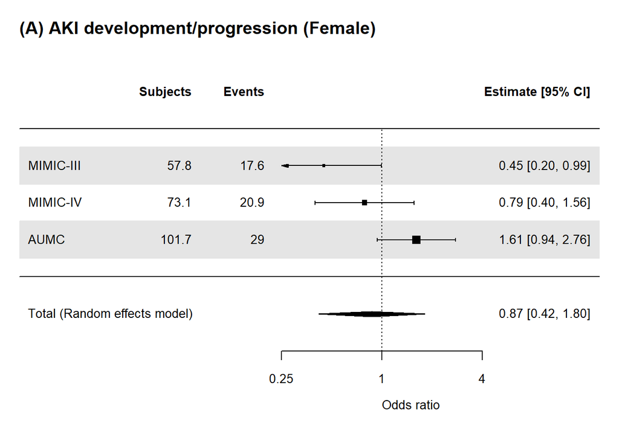

```r
FP2("wgt_man_Ovlp_MIMIC4_Female.rds", FORMULA_ovl2_sex)
FP2("wgt_man_Ovlp_MIMIC3_Female.rds", FORMULA_ovl2_sex)
FP2("wgt_man_Ovlp_AUMC_Female.rds", FORMULA_ovl2_sex)

Female_METADF0 <- rbind(
  readRDS("ORRES_wgt_man_Ovlp_MIMIC3_Female.rds") %>% mutate("dataset"="MIMIC-III"),
  readRDS("ORRES_wgt_man_Ovlp_MIMIC4_Female.rds") %>% mutate("dataset"="MIMIC-IV"),
  readRDS("ORRES_wgt_man_Ovlp_AUMC_Female.rds") %>% mutate("dataset"="AUMC"))
Female_METADF_AKID <- Female_METADF0 %>% subset(outcome=="outcome_KDIGO_inc_or_death")
Female_METADF_AKI <- Female_METADF0 %>% subset(outcome=="outcome_KDIGO_inc")
Female_METADF_HD <- Female_METADF0 %>% subset(outcome=="outcome_new_dial")
Female_METADF_D <- Female_METADF0 %>% subset(outcome=="death_in_7d")
Female_METADF_HDD <- Female_METADF0 %>% subset(outcome=="outcome_HDD_in7d")

Female_METARES_AKID <- rma(yi = Estimate, sei = Std.Error, method = "REML", data = Female_METADF_AKID)
Female_METARES_AKI <-rma(yi = Estimate, sei = Std.Error, method = "REML", data = Female_METADF_AKI)
Female_METARES_HD <- rma(yi = Estimate, sei = Std.Error, method = "REML", data = Female_METADF_HD)
Female_METARES_D <- rma(yi = Estimate, sei = Std.Error, method = "REML", data = Female_METADF_D)
Female_METARES_HDD <- rma(yi = Estimate, sei = Std.Error, method = "REML", data = Female_METADF_HDD)

METAF(Female_METARES_AKI, SCALEA1, SCALEB1, SCALEC1, "(A) AKI development/progression (Female)")
```

```r
Female_METARES_AKI
```

```
##
## Random-Effects Model (k = 3; tau^2 estimator: REML)
##
## tau^2 (estimated amount of total heterogeneity): 0.2996 (SE = 0.4171)
## tau (square root of estimated tau^2 value):      0.5474
## I^2 (total heterogeneity / total variability):   72.34%
## H^2 (total variability / sampling variability):  3.62
##
## Test for Heterogeneity:
## Q(df = 2) = 7.3806, p-val = 0.0250
##
## Model Results:
##
## estimate      se     zval    pval    ci.lb   ci.ub
##  -0.1419  0.3725  -0.3810  0.7032  -0.8721  0.5882
##
## ---
## Signif. codes:  0 '***' 0.001 '**' 0.01 '*' 0.05 '.' 0.1 ' ' 1
```

```r
Female_METADF_AKI %>% dplyr::select(dataset, OR, LCI, UCI, 'Pr(>|z|)') %>% remove_rownames()
```

```
##     dataset        OR       LCI      UCI   Pr(>|z|)
## 1 MIMIC-III 0.4499287 0.2042828 0.990959 0.04742237
## 2  MIMIC-IV 0.7890831 0.3984538 1.562671 0.49682614
## 3      AUMC 1.6096282 0.9393049 2.758320 0.08325301
```

__

#### 6c. Backgrounds, outcomes, matching quality, and forrest plot among those **younger** at treatment start.

```r
FORMULA_ovl2_age <- drug01 ~  sex + dep_type2 + sirs + pre_blood_culture + treat_van + vasopressor + base_crea + near_crea +  base_KDIGO
comb_DF2ovl %>%dplyr::select(age_cat, age_group) %>% unique()
```

```
##    age_cat age_group
## 1       30     18-39
## 2       75     70-79
## 3       85       80+
## 6       45     40-49
## 13      55     50-59
## 38      65     60-69
```

```r
#1. overlap-PSM using MIMIC3, "Young"
OVLP(comb_DF2ovl %>% subset(dataset=="MIMIC3"&age_cat<59), FORMULA_ovl2_age, "Ovlp_MIMIC3_Young", "**Ovlp, MIMIC-III, Young**")
```

| **Characteristic** | **Ovlp, MIMIC-III, Young** **I/C** N=19.8<sup>1</sup> | **Ovlp, MIMIC-III, Young** **NCC** N=19.8<sup>1</sup> | **p-value**<sup>2</sup> |  |
| --- | --- | --- | --- | --- |
| dataset |  |  |  |  |
| MIMIC3 | 19.8 (100.0%) | 19.8 (100.0%) |  |  |
| age_group |  |  | 0.75 |  |
| 18-39 | 3.1 (15.6%) | 4.4 (22.3%) |  |  |
| 40-49 | 6.0 (30.4%) | 5.5 (27.6%) |  |  |
| 50-59 | 10.7 (54.0%) | 9.9 (50.1%) |  |  |
| sex |  |  | >0.99 |  |
| Female | 6.6 (33.2%) | 6.6 (33.2%) |  |  |
| Male | 13.2 (66.8%) | 13.2 (66.8%) |  |  |
| bmi | 28.7 (24.3, 31.6) | 28.3 (22.8, 35.7) | 0.88 |  |
| Unknown | 6 | 9 |  |  |
| ICU type |  |  | >0.99 |  |
| Non-surgery | 12.3 (62.2%) | 12.3 (62.2%) |  |  |
| Surgery | 7.5 (37.8%) | 7.5 (37.8%) |  |  |
| drug_name |  |  |  |  |
| Imipenem/cilastatin | 19.8 (100.0%) | 0.0 (0.0%) |  |  |
| Imipenem/cilastatin/relebactam | 0.0 (0.0%) | 0.0 (0.0%) |  |  |
| Meropenem | 0.0 (0.0%) | 19.8 (100.0%) |  |  |
| Doripenem | 0.0 (0.0%) | 0.0 (0.0%) |  |  |
| Ertapenem | 0.0 (0.0%) | 0.0 (0.0%) |  |  |
| sofa | 5.0 (3.0, 9.0) | 5.0 (2.0, 8.0) | 0.39 |  |
| qsofa | 1.0 (0.0, 1.0) | 1.0 (0.0, 1.0) | 0.61 |  |
| Unknown | 0 | 0 |  |  |
| sirs | 2.0 (1.0, 3.0) | 2.0 (1.0, 3.0) | 0.96 |  |
| pre_blood_culture | 17.0 (85.8%) | 17.0 (85.8%) | >0.99 |  |
| pre vancomycin use | 6.8 (34.4%) | 6.8 (34.4%) | >0.99 |  |
| pre vasopressor use | 6.9 (34.7%) | 6.9 (34.7%) | >0.99 |  |
| pre ventilation | 13.2 (66.7%) | 13.6 (68.7%) | 0.85 |  |
| Baseline sCr | 0.8 (0.5, 1.1) | 0.7 (0.5, 1.5) | 0.85 |  |
| sCr at treatment start | 0.9 (0.7, 1.4) | 0.9 (0.6, 1.7) | 0.86 |  |
| AKI stage at treatment start |  |  | 0.26 |  |
| 0 | 15.5 (78.4%) | 16.1 (81.2%) |  |  |
| 1 | 4.3 (21.6%) | 3.2 (15.9%) |  |  |
| 2 | 0.0 (0.0%) | 0.6 (2.8%) |  |  |
| observation time | 168.0 (168.0, 168.0) | 168.0 (168.0, 168.0) | >0.99 |  |
| Cencsored with drug change | 1.3 (6.8%) | 0.0 (0.0%) | 0.16 |  |
| RRT at treatment start | 0.0 (0.0%) | 0.0 (0.0%) |  |  |
| O, AKI develop/progress | 5.8 (29.3%) | 10.3 (51.9%) | 0.046 |  |
| O, Death | 1.2 (5.9%) | 2.5 (12.7%) | 0.30 |  |
| O, AKI d/p or death | 5.8 (29.3%) | 10.6 (53.6%) | 0.032 |  |
| O, RRT-intervention | 1.0 (5.1%) | 1.6 (8.2%) | 0.54 |  |
| O, Death or RRT-intervention | 1.7 (8.8%) | 3.9 (19.9%) | 0.16 |  |

<sup>1</sup> n (%); Median (Q1, Q3)  
<sup>2</sup> NA; Pearson’s X^2: Rao & Scott adjustment; Design-based KruskalWallis test

```r
#2. overlap-PSM using MIMIC4, "Young"
OVLP(comb_DF2ovl %>% subset(dataset=="miiv"&age_cat<59), FORMULA_ovl2_age, "Ovlp_MIMIC4_Young", "**Ovlp, MIMIC-IV, Young**")
```

| **Characteristic** | **Ovlp, MIMIC-IV, Young** **I/C** N=28.0<sup>1</sup> | **Ovlp, MIMIC-IV, Young** **NCC** N=28.0<sup>1</sup> | **p-value**<sup>2</sup> |  |
| --- | --- | --- | --- | --- |
| dataset |  |  |  |  |
| miiv | 28.0 (100.0%) | 28.0 (100.0%) |  |  |
| age_group |  |  | 0.31 |  |
| 18-39 | 7.7 (27.6%) | 7.2 (25.6%) |  |  |
| 40-49 | 9.7 (34.6%) | 6.6 (23.6%) |  |  |
| 50-59 | 10.6 (37.8%) | 14.2 (50.8%) |  |  |
| sex |  |  | >0.99 |  |
| Female | 9.7 (34.6%) | 9.7 (34.6%) |  |  |
| Male | 18.3 (65.4%) | 18.3 (65.4%) |  |  |
| bmi | 28.2 (25.1, 31.1) | 27.8 (23.9, 33.6) | 0.79 |  |
| Unknown | 15 | 11 |  |  |
| ICU type |  |  | >0.99 |  |
| Non-surgery | 21.3 (75.9%) | 21.3 (75.9%) |  |  |
| Surgery | 6.8 (24.1%) | 6.8 (24.1%) |  |  |
| drug_name |  |  |  |  |
| Imipenem/cilastatin | 28.0 (100.0%) | 0.0 (0.0%) |  |  |
| Imipenem/cilastatin/relebactam | 0.0 (0.0%) | 0.0 (0.0%) |  |  |
| Meropenem | 0.0 (0.0%) | 27.8 (99.3%) |  |  |
| Doripenem | 0.0 (0.0%) | 0.1 (0.3%) |  |  |
| Ertapenem | 0.0 (0.0%) | 0.1 (0.5%) |  |  |
| sofa | 4.0 (3.0, 5.0) | 5.0 (3.0, 7.0) | 0.18 |  |
| qsofa | 1.0 (0.0, 1.0) | 1.0 (0.0, 1.0) | 0.40 |  |
| Unknown | 0 | 0 |  |  |
| sirs | 2.0 (1.0, 2.0) | 2.0 (1.0, 3.0) | 0.93 |  |
| pre_blood_culture | 18.5 (66.1%) | 18.5 (66.1%) | >0.99 |  |
| pre vancomycin use | 18.4 (65.6%) | 18.4 (65.6%) | >0.99 |  |
| pre vasopressor use | 1.0 (3.5%) | 1.0 (3.5%) | >0.99 |  |
| pre ventilation | 3.9 (14.0%) | 1.1 (4.0%) | 0.010 |  |
| Baseline sCr | 0.8 (0.5, 1.1) | 0.8 (0.5, 1.2) | 0.63 |  |
| sCr at treatment start | 0.8 (0.5, 1.5) | 0.9 (0.6, 1.3) | 0.63 |  |
| AKI stage at treatment start |  |  | 0.78 |  |
| 0 | 25.1 (89.5%) | 24.7 (88.1%) |  |  |
| 1 | 2.0 (7.1%) | 2.8 (9.8%) |  |  |
| 2 | 1.0 (3.5%) | 0.6 (2.1%) |  |  |
| observation time | 168.0 (109.5, 168.0) | 168.0 (146.9, 168.0) | 0.12 |  |
| Unknown | 5 | 3 |  |  |
| Cencsored with drug change | 0.0 (0.0%) | 0.0 (0.0%) |  |  |
| RRT at treatment start | 0.0 (0.0%) | 0.0 (0.0%) |  |  |
| O, AKI develop/progress | 7.8 (27.8%) | 8.0 (28.7%) | 0.91 |  |
| O, Death | 3.9 (14.0%) | 2.0 (7.2%) | 0.17 |  |
| O, AKI d/p or death | 7.8 (27.8%) | 8.8 (31.4%) | 0.68 |  |
| O, RRT-intervention | 0.0 (0.0%) | 1.3 (4.7%) | <0.001 |  |
| O, Death or RRT-intervention | 3.9 (14.0%) | 3.0 (10.7%) | 0.57 |  |

<sup>1</sup> n (%); Median (Q1, Q3)  
<sup>2</sup> NA; Pearson’s X^2: Rao & Scott adjustment; Design-based KruskalWallis test

```r
#3. overlap-PSM using AUMC, "Young"
OVLP(comb_DF2ovl %>% subset(dataset=="AUMC"&age_cat<59), FORMULA_ovl2_age, "Ovlp_AUMC_Young", paste0("**Ovlp, AUMC, Young**"))
```

| **Characteristic** | **Ovlp, AUMC, Young** **I/C** N=60.2<sup>1</sup> | **Ovlp, AUMC, Young** **NCC** N=60.2<sup>1</sup> | **p-value**<sup>2</sup> |  |
| --- | --- | --- | --- | --- |
| dataset |  |  |  |  |
| AUMC | 60.2 (100.0%) | 60.2 (100.0%) |  |  |
| age_group |  |  | 0.28 |  |
| 18-39 | 14.8 (24.5%) | 19.8 (32.9%) |  |  |
| 40-49 | 14.9 (24.7%) | 15.2 (25.2%) |  |  |
| 50-59 | 30.6 (50.8%) | 25.2 (41.8%) |  |  |
| sex |  |  | >0.99 |  |
| Female | 26.1 (43.3%) | 26.1 (43.3%) |  |  |
| Male | 34.1 (56.7%) | 34.1 (56.7%) |  |  |
| bmi | 24.5 (21.9, 27.8) | 24.5 (21.9, 27.8) | 0.46 |  |
| Unknown | 4 | 2 |  |  |
| ICU type |  |  | >0.99 |  |
| Non-surgery | 38.4 (63.7%) | 38.4 (63.7%) |  |  |
| Surgery | 21.8 (36.3%) | 21.8 (36.3%) |  |  |
| drug_name |  |  |  |  |
| Imipenem/cilastatin | 60.2 (100.0%) | 0.0 (0.0%) |  |  |
| Imipenem/cilastatin/relebactam | 0.0 (0.0%) | 0.0 (0.0%) |  |  |
| Meropenem | 0.0 (0.0%) | 60.2 (100.0%) |  |  |
| Doripenem | 0.0 (0.0%) | 0.0 (0.0%) |  |  |
| Ertapenem | 0.0 (0.0%) | 0.0 (0.0%) |  |  |
| sofa | 7.0 (4.0, 9.0) | 6.0 (4.0, 9.0) | 0.33 |  |
| Unknown | 7 | 10 |  |  |
| qsofa | 1.0 (0.0, 1.0) | 1.0 (0.0, 1.0) | 0.53 |  |
| sirs | 2.0 (2.0, 3.0) | 2.0 (1.0, 3.0) | 0.98 |  |
| pre_blood_culture | 9.0 (14.9%) | 9.0 (14.9%) | >0.99 |  |
| pre vancomycin use | 30.8 (51.1%) | 30.8 (51.1%) | >0.99 |  |
| pre vasopressor use | 34.5 (57.3%) | 34.5 (57.3%) | >0.99 |  |
| pre ventilation | 39.2 (65.0%) | 36.4 (60.5%) | 0.46 |  |
| Baseline sCr | 0.7 (0.5, 1.0) | 0.7 (0.5, 1.1) | 0.69 |  |
| sCr at treatment start | 0.9 (0.6, 1.3) | 0.8 (0.6, 1.3) | 0.62 |  |
| AKI stage at treatment start |  |  | 0.79 |  |
| 0 | 48.0 (79.7%) | 47.2 (78.4%) |  |  |
| 1 | 9.1 (15.1%) | 10.6 (17.7%) |  |  |
| 2 | 3.2 (5.3%) | 2.4 (4.0%) |  |  |
| observation time | 168.0 (67.9, 168.0) | 162.0 (56.4, 168.0) | 0.44 |  |
| Cencsored with drug change | 1.1 (1.9%) | 0.6 (1.1%) | 0.61 |  |
| RRT at treatment start | 0.0 (0.0%) | 0.0 (0.0%) |  |  |
| O, AKI develop/progress | 16.8 (28.0%) | 13.1 (21.7%) | 0.28 |  |
| O, Death | 5.4 (8.9%) | 8.0 (13.3%) | 0.25 |  |
| O, AKI d/p or death | 19.3 (32.0%) | 18.2 (30.2%) | 0.77 |  |
| O, RRT-intervention | 5.7 (9.4%) | 4.5 (7.5%) | 0.61 |  |
| O, Death or RRT-intervention | 9.2 (15.3%) | 11.0 (18.3%) | 0.52 |  |

<sup>1</sup> n (%); Median (Q1, Q3)  
<sup>2</sup> NA; Pearson’s X^2: Rao & Scott adjustment; Design-based KruskalWallis test

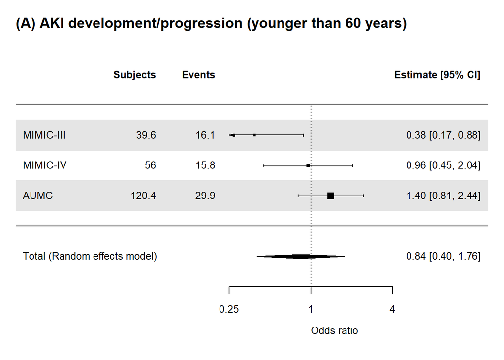

```r
#Forrestplot
FP2("wgt_man_Ovlp_MIMIC3_Young.rds", FORMULA_ovl2_age)
FP2("wgt_man_Ovlp_MIMIC4_Young.rds", FORMULA_ovl2_age)
FP2("wgt_man_Ovlp_AUMC_Young.rds", FORMULA_ovl2_age)

Young_METADF0 <- rbind(
  readRDS("ORRES_wgt_man_Ovlp_MIMIC3_Young.rds") %>% mutate("dataset"="MIMIC-III"),
  readRDS("ORRES_wgt_man_Ovlp_MIMIC4_Young.rds") %>% mutate("dataset"="MIMIC-IV"),
  readRDS("ORRES_wgt_man_Ovlp_AUMC_Young.rds") %>% mutate("dataset"="AUMC"))
Young_METADF_AKID <- Young_METADF0 %>% subset(outcome=="outcome_KDIGO_inc_or_death")
Young_METADF_AKI <- Young_METADF0 %>% subset(outcome=="outcome_KDIGO_inc")
Young_METADF_HD <- Young_METADF0 %>% subset(outcome=="outcome_new_dial")
Young_METADF_D <- Young_METADF0 %>% subset(outcome=="death_in_7d")
Young_METADF_HDD <- Young_METADF0 %>% subset(outcome=="outcome_HDD_in7d")
Young_METARES_AKID <- rma(yi = Estimate, sei = Std.Error, method = "REML", data = Young_METADF_AKID)
Young_METARES_AKI<-rma(yi = Estimate, sei = Std.Error, method = "REML", data = Young_METADF_AKI)
Young_METARES_HD<-rma(yi = Estimate, sei = Std.Error, method = "REML", data = Young_METADF_HD)
Young_METARES_D<-rma(yi = Estimate, sei = Std.Error, method = "REML", data = Young_METADF_D)
Young_METARES_HDD<-rma(yi = Estimate, sei = Std.Error, method = "REML", data = Young_METADF_HDD)

METAF(Young_METARES_AKI, SCALEA1, SCALEB1, SCALEC1, "(A) AKI development/progression (younger than 60 years)")
```

```r
Young_METARES_AKI
```

```
##
## Random-Effects Model (k = 3; tau^2 estimator: REML)
##
## tau^2 (estimated amount of total heterogeneity): 0.2959 (SE = 0.4289)
## tau (square root of estimated tau^2 value):      0.5440
## I^2 (total heterogeneity / total variability):   69.54%
## H^2 (total variability / sampling variability):  3.28
##
## Test for Heterogeneity:
## Q(df = 2) = 6.4832, p-val = 0.0391
##
## Model Results:
##
## estimate      se     zval    pval    ci.lb   ci.ub
##  -0.1733  0.3776  -0.4591  0.6462  -0.9134  0.5667
##
## ---
## Signif. codes:  0 '***' 0.001 '**' 0.01 '*' 0.05 '.' 0.1 ' ' 1
```

```r
Young_METADF_AKI %>% dplyr::select(dataset, OR, LCI, UCI, 'Pr(>|z|)') %>% remove_rownames()
```

```
##     dataset        OR       LCI      UCI   Pr(>|z|)
## 1 MIMIC-III 0.3848842 0.1682941 0.880220 0.02368204
## 2  MIMIC-IV 0.9559179 0.4473386 2.042701 0.90736432
## 3      AUMC 1.4017728 0.8063248 2.436942 0.23130293
```

__

__

#### 6d. Backgrounds, outcomes, matching quality, and forest plot among those **Older**

```r
#1. overlap-PSM using MIMIC3, Older
OVLP(comb_DF2ovl %>% subset(dataset=="MIMIC3"&age_cat>58), FORMULA_ovl2_age, "Ovlp_MIMIC3_Old", "**Ovlp, MIMIC-III, Old**")
```

| **Characteristic** | **Ovlp, MIMIC-III, Old** **I/C** N=40.0<sup>1</sup> | **Ovlp, MIMIC-III, Old** **NCC** N=40.0<sup>1</sup> | **p-value**<sup>2</sup> |  |
| --- | --- | --- | --- | --- |
| dataset |  |  |  |  |
| MIMIC3 | 40.0 (100.0%) | 40.0 (100.0%) |  |  |
| age_group |  |  | 0.52 |  |
| 60-69 | 13.3 (33.4%) | 13.0 (32.4%) |  |  |
| 70-79 | 13.6 (34.1%) | 16.8 (41.9%) |  |  |
| 80+ | 13.0 (32.6%) | 10.3 (25.7%) |  |  |
| sex |  |  | >0.99 |  |
| Female | 22.3 (55.8%) | 22.3 (55.8%) |  |  |
| Male | 17.7 (44.2%) | 17.7 (44.2%) |  |  |
| bmi | 26.2 (24.9, 29.7) | 27.4 (23.4, 33.2) | 0.88 |  |
| Unknown | 21 | 22 |  |  |
| ICU type |  |  | >0.99 |  |
| Non-surgery | 23.7 (59.4%) | 23.7 (59.4%) |  |  |
| Surgery | 16.3 (40.6%) | 16.3 (40.6%) |  |  |
| drug_name |  |  |  |  |
| Imipenem/cilastatin | 40.0 (100.0%) | 0.0 (0.0%) |  |  |
| Imipenem/cilastatin/relebactam | 0.0 (0.0%) | 0.0 (0.0%) |  |  |
| Meropenem | 0.0 (0.0%) | 40.0 (100.0%) |  |  |
| Doripenem | 0.0 (0.0%) | 0.0 (0.0%) |  |  |
| Ertapenem | 0.0 (0.0%) | 0.0 (0.0%) |  |  |
| sofa | 4.0 (3.0, 7.0) | 4.0 (2.0, 7.0) | 0.63 |  |
| qsofa | 1.0 (0.0, 1.0) | 1.0 (0.0, 1.0) | 0.77 |  |
| Unknown | 0 | 1 |  |  |
| sirs | 2.0 (1.0, 3.0) | 2.0 (1.0, 2.0) | 0.85 |  |
| pre_blood_culture | 30.9 (77.4%) | 30.9 (77.4%) | >0.99 |  |
| pre vancomycin use | 12.9 (32.1%) | 12.9 (32.1%) | >0.99 |  |
| pre vasopressor use | 17.6 (43.9%) | 17.6 (43.9%) | >0.99 |  |
| pre ventilation | 27.2 (67.9%) | 27.2 (68.1%) | 0.98 |  |
| Baseline sCr | 1.0 (0.6, 1.4) | 0.9 (0.6, 1.4) | 0.84 |  |
| sCr at treatment start | 1.2 (0.9, 1.8) | 1.1 (0.8, 1.7) | 0.70 |  |
| AKI stage at treatment start |  |  | 0.83 |  |
| 0 | 29.2 (72.9%) | 28.7 (71.6%) |  |  |
| 1 | 9.3 (23.4%) | 10.4 (26.0%) |  |  |
| 2 | 1.5 (3.7%) | 1.0 (2.4%) |  |  |
| observation time | 168.0 (153.8, 168.0) | 168.0 (168.0, 168.0) | 0.46 |  |
| Cencsored with drug change | 0.8 (2.1%) | 0.2 (0.4%) | 0.23 |  |
| RRT at treatment start | 0.0 (0.0%) | 0.0 (0.0%) |  |  |
| O, AKI develop/progress | 8.6 (21.4%) | 12.9 (32.3%) | 0.14 |  |
| O, Death | 6.1 (15.3%) | 6.4 (16.1%) | 0.89 |  |
| O, AKI d/p or death | 12.4 (31.1%) | 15.7 (39.3%) | 0.29 |  |
| O, RRT-intervention | 0.0 (0.0%) | 1.4 (3.4%) | 0.007 |  |
| O, Death or RRT-intervention | 6.1 (15.3%) | 7.4 (18.6%) | 0.58 |  |

<sup>1</sup> n (%); Median (Q1, Q3)  
<sup>2</sup> NA; Pearson’s X^2: Rao & Scott adjustment; Design-based KruskalWallis test

```r
#2. overlap-PSM using MIMIC4, Older
OVLP(comb_DF2ovl %>% subset(dataset=="miiv"&age_cat>58), FORMULA_ovl2_age, "Ovlp_MIMIC4_Old", "**Ovlp, MIMIC-IV, Old**")
```

| **Characteristic** | **Ovlp, MIMIC-IV, Old** **I/C** N=56.6<sup>1</sup> | **Ovlp, MIMIC-IV, Old** **NCC** N=56.6<sup>1</sup> | **p-value**<sup>2</sup> |  |
| --- | --- | --- | --- | --- |
| dataset |  |  |  |  |
| miiv | 56.6 (100.0%) | 56.6 (100.0%) |  |  |
| age_group |  |  | 0.93 |  |
| 60-69 | 24.0 (42.3%) | 25.1 (44.4%) |  |  |
| 70-79 | 18.2 (32.2%) | 18.2 (32.1%) |  |  |
| 80+ | 14.4 (25.5%) | 13.3 (23.5%) |  |  |
| sex |  |  | >0.99 |  |
| Female | 26.8 (47.2%) | 26.8 (47.2%) |  |  |
| Male | 29.9 (52.8%) | 29.9 (52.8%) |  |  |
| bmi | 27.2 (25.1, 33.6) | 27.3 (23.5, 32.7) | 0.44 |  |
| Unknown | 27 | 21 |  |  |
| ICU type |  |  | >0.99 |  |
| Non-surgery | 48.8 (86.1%) | 48.8 (86.1%) |  |  |
| Surgery | 7.9 (13.9%) | 7.9 (13.9%) |  |  |
| drug_name |  |  | <0.001 |  |
| Imipenem/cilastatin | 55.6 (98.3%) | 0.0 (0.0%) |  |  |
| Imipenem/cilastatin/relebactam | 1.0 (1.7%) | 0.0 (0.0%) |  |  |
| Meropenem | 0.0 (0.0%) | 56.3 (99.4%) |  |  |
| Doripenem | 0.0 (0.0%) | 0.1 (0.2%) |  |  |
| Ertapenem | 0.0 (0.0%) | 0.2 (0.4%) |  |  |
| sofa | 5.0 (4.0, 9.0) | 6.0 (3.0, 9.0) | 0.72 |  |
| qsofa | 1.0 (0.0, 1.0) | 1.0 (0.0, 1.0) | 0.96 |  |
| Unknown | 0 | 0 |  |  |
| sirs | 2.0 (1.0, 3.0) | 2.0 (1.0, 3.0) | 0.96 |  |
| pre_blood_culture | 46.9 (82.8%) | 46.9 (82.8%) | >0.99 |  |
| pre vancomycin use | 33.8 (59.7%) | 33.8 (59.7%) | >0.99 |  |
| pre vasopressor use | 6.6 (11.7%) | 6.6 (11.7%) | >0.99 |  |
| pre ventilation | 7.6 (13.4%) | 6.0 (10.6%) | 0.49 |  |
| Baseline sCr | 1.0 (0.7, 1.6) | 1.1 (0.7, 1.6) | 0.76 |  |
| sCr at treatment start | 1.3 (0.8, 2.3) | 1.2 (0.8, 2.0) | 0.84 |  |
| AKI stage at treatment start |  |  | >0.99 |  |
| 0 | 39.3 (69.4%) | 39.4 (69.7%) |  |  |
| 1 | 13.5 (23.8%) | 13.2 (23.4%) |  |  |
| 2 | 3.8 (6.7%) | 3.9 (6.9%) |  |  |
| observation time | 168.0 (101.0, 168.0) | 168.0 (141.5, 168.0) | 0.90 |  |
| Unknown | 4 | 5 |  |  |
| Cencsored with drug change | 3.9 (6.8%) | 0.0 (0.0%) | 0.038 |  |
| RRT at treatment start | 0.0 (0.0%) | 0.0 (0.0%) |  |  |
| O, AKI develop/progress | 22.9 (40.5%) | 18.5 (32.7%) | 0.21 |  |
| O, Death | 9.5 (16.8%) | 10.5 (18.6%) | 0.74 |  |
| O, AKI d/p or death | 24.9 (43.9%) | 23.2 (40.9%) | 0.65 |  |
| O, RRT-intervention | 2.8 (5.0%) | 4.0 (7.0%) | 0.54 |  |
| O, Death or RRT-intervention | 10.5 (18.5%) | 12.9 (22.7%) | 0.45 |  |

<sup>1</sup> n (%); Median (Q1, Q3)  
<sup>2</sup> NA; Pearson’s X^2: Rao & Scott adjustment; Design-based KruskalWallis test

```r
#3. overlap-PSM using AUMC, Older
OVLP(comb_DF2ovl %>% subset(dataset=="AUMC"&age_cat>58), FORMULA_ovl2_age, "Ovlp_AUMC_Old", "**Ovlp, AUMC, Old**")
```

| **Characteristic** | **Ovlp, AUMC, Old** **I/C** N=82.1<sup>1</sup> | **Ovlp, AUMC, Old** **NCC** N=82.1<sup>1</sup> | **p-value**<sup>2</sup> |  |
| --- | --- | --- | --- | --- |
| dataset |  |  |  |  |
| AUMC | 82.1 (100.0%) | 82.1 (100.0%) |  |  |
| age_group |  |  | 0.45 |  |
| 60-69 | 46.0 (56.0%) | 40.4 (49.2%) |  |  |
| 70-79 | 30.2 (36.8%) | 35.3 (43.0%) |  |  |
| 80+ | 5.9 (7.1%) | 6.4 (7.8%) |  |  |
| sex |  |  | >0.99 |  |
| Female | 26.1 (31.8%) | 26.1 (31.8%) |  |  |
| Male | 56.0 (68.2%) | 56.0 (68.2%) |  |  |
| bmi | 24.5 (21.9, 27.8) | 24.5 (21.3, 27.8) | 0.57 |  |
| Unknown | 4 | 1 |  |  |
| ICU type |  |  | >0.99 |  |
| Non-surgery | 46.6 (56.8%) | 46.6 (56.8%) |  |  |
| Surgery | 35.4 (43.2%) | 35.4 (43.2%) |  |  |
| drug_name |  |  |  |  |
| Imipenem/cilastatin | 82.1 (100.0%) | 0.0 (0.0%) |  |  |
| Imipenem/cilastatin/relebactam | 0.0 (0.0%) | 0.0 (0.0%) |  |  |
| Meropenem | 0.0 (0.0%) | 82.1 (100.0%) |  |  |
| Doripenem | 0.0 (0.0%) | 0.0 (0.0%) |  |  |
| Ertapenem | 0.0 (0.0%) | 0.0 (0.0%) |  |  |
| sofa | 8.0 (5.0, 9.0) | 8.0 (5.0, 10.0) | 0.62 |  |
| Unknown | 13 | 15 |  |  |
| qsofa | 1.0 (0.0, 1.0) | 1.0 (0.0, 1.0) | 0.54 |  |
| Unknown | 0 | 0 |  |  |
| sirs | 2.0 (1.0, 3.0) | 2.0 (1.0, 3.0) | 0.92 |  |
| pre_blood_culture | 12.1 (14.8%) | 12.1 (14.8%) | >0.99 |  |
| pre vancomycin use | 40.3 (49.1%) | 40.3 (49.1%) | >0.99 |  |
| pre vasopressor use | 56.0 (68.2%) | 56.0 (68.2%) | >0.99 |  |
| pre ventilation | 56.5 (68.9%) | 47.9 (58.3%) | 0.045 |  |
| Baseline sCr | 0.9 (0.7, 1.3) | 0.8 (0.6, 1.2) | 0.32 |  |
| sCr at treatment start | 1.1 (0.8, 1.6) | 1.0 (0.7, 1.7) | 0.46 |  |
| AKI stage at treatment start |  |  | 0.52 |  |
| 0 | 55.8 (68.0%) | 57.6 (70.2%) |  |  |
| 1 | 21.8 (26.5%) | 18.1 (22.1%) |  |  |
| 2 | 4.5 (5.5%) | 6.3 (7.7%) |  |  |
| observation time | 168.0 (64.0, 168.0) | 162.0 (63.3, 168.0) | 0.86 |  |
| Cencsored with drug change | 3.3 (4.0%) | 0.8 (0.9%) | 0.13 |  |
| RRT at treatment start | 0.0 (0.0%) | 0.0 (0.0%) |  |  |
| O, AKI develop/progress | 26.3 (32.1%) | 28.0 (34.2%) | 0.69 |  |
| O, Death | 13.8 (16.9%) | 10.6 (12.9%) | 0.33 |  |
| O, AKI d/p or death | 30.6 (37.3%) | 31.9 (38.8%) | 0.78 |  |
| O, RRT-intervention | 8.5 (10.3%) | 11.3 (13.8%) | 0.34 |  |
| O, Death or RRT-intervention | 19.2 (23.4%) | 16.5 (20.1%) | 0.48 |  |

<sup>1</sup> n (%); Median (Q1, Q3)  
<sup>2</sup> NA; Pearson’s X^2: Rao & Scott adjustment; Design-based KruskalWallis test

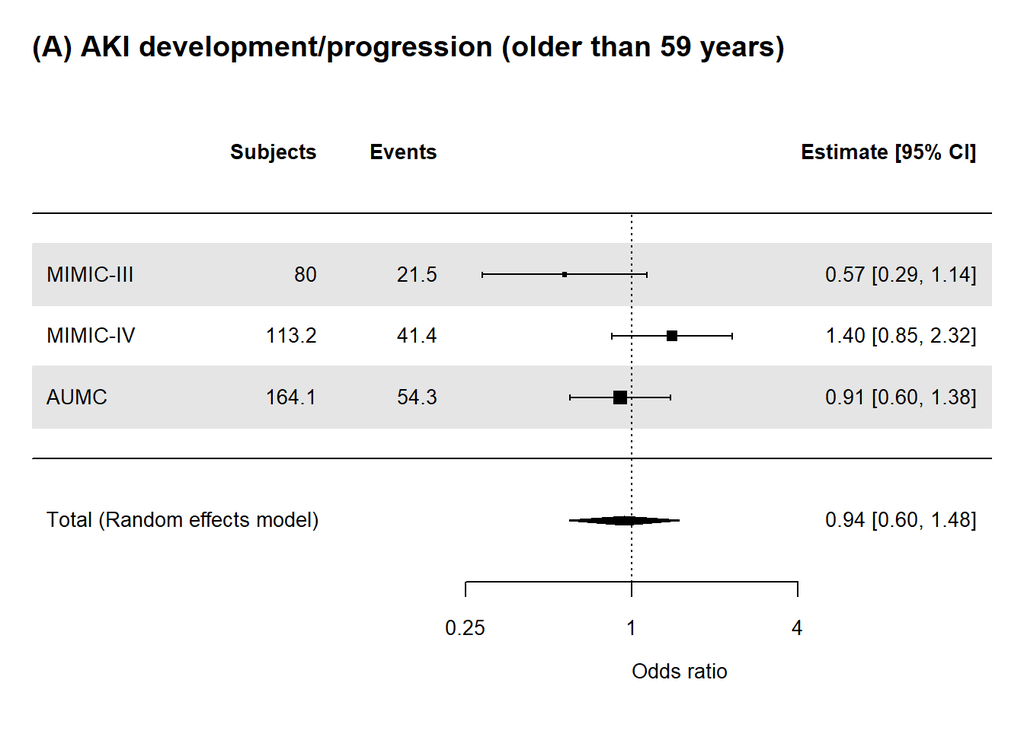

```r
FP2("wgt_man_Ovlp_MIMIC4_Old.rds", FORMULA_ovl2_age)
FP2("wgt_man_Ovlp_MIMIC3_Old.rds", FORMULA_ovl2_age)
FP2("wgt_man_Ovlp_AUMC_Old.rds", FORMULA_ovl2_age)

Old_METADF0 <- rbind(
  readRDS("ORRES_wgt_man_Ovlp_MIMIC3_Old.rds") %>% mutate("dataset"="MIMIC-III"),
  readRDS("ORRES_wgt_man_Ovlp_MIMIC4_Old.rds") %>% mutate("dataset"="MIMIC-IV"),
  readRDS("ORRES_wgt_man_Ovlp_AUMC_Old.rds") %>% mutate("dataset"="AUMC"))
Old_METADF_AKID <- Old_METADF0 %>% subset(outcome=="outcome_KDIGO_inc_or_death")
Old_METADF_AKI <- Old_METADF0 %>% subset(outcome=="outcome_KDIGO_inc")
Old_METADF_HD <- Old_METADF0 %>% subset(outcome=="outcome_new_dial")
Old_METADF_D <- Old_METADF0 %>% subset(outcome=="death_in_7d")
Old_METADF_HDD <- Old_METADF0 %>% subset(outcome=="outcome_HDD_in7d")

Old_METARES_AKID <- rma(yi = Estimate, sei = Std.Error, method = "REML", data = Old_METADF_AKID)
Old_METARES_AKI <-rma(yi = Estimate, sei = Std.Error, method = "REML", data = Old_METADF_AKI)
Old_METARES_HD <- rma(yi = Estimate, sei = Std.Error, method = "REML", data = Old_METADF_HD)
Old_METARES_D <- rma(yi = Estimate, sei = Std.Error, method = "REML", data = Old_METADF_D)
Old_METARES_HDD <- rma(yi = Estimate, sei = Std.Error, method = "REML", data = Old_METADF_HDD)

METAF(Old_METARES_AKI, SCALEA1, SCALEB1, SCALEC1, "(A) AKI development/progression (older than 59 years)")
```

```r
Old_METARES_AKI
```

```
##
## Random-Effects Model (k = 3; tau^2 estimator: REML)
##
## tau^2 (estimated amount of total heterogeneity): 0.0897 (SE = 0.1633)
## tau (square root of estimated tau^2 value):      0.2996
## I^2 (total heterogeneity / total variability):   55.67%
## H^2 (total variability / sampling variability):  2.26
##
## Test for Heterogeneity:
## Q(df = 2) = 4.4246, p-val = 0.1094
##
## Model Results:
##
## estimate      se     zval    pval    ci.lb   ci.ub
##  -0.0619  0.2325  -0.2663  0.7900  -0.5177  0.3938
##
## ---
## Signif. codes:  0 '***' 0.001 '**' 0.01 '*' 0.05 '.' 0.1 ' ' 1
```

```r
Old_METADF_AKI %>% dplyr::select(dataset, OR, LCI, UCI, 'Pr(>|z|)') %>% remove_rownames()
```

```
##     dataset        OR       LCI      UCI  Pr(>|z|)
## 1 MIMIC-III 0.5717926 0.2872114 1.138349 0.1115824
## 2  MIMIC-IV 1.4033314 0.8486000 2.320692 0.1867353
## 3      AUMC 0.9094051 0.5978664 1.383282 0.6572095
```

__

#### 7c. Backgrounds, outcomes, matching quality, and forrest plot among those **vancomycin** at treatment start.

```r
FORMULA_ovl2_vc <- drug01 ~  age_cat + sex + dep_type2 + sirs + pre_blood_culture + vasopressor + base_crea + near_crea +  base_KDIGO

#1. overlap-PSM using MIMIC3, "Young"
OVLP(comb_DF2ovl %>% subset(dataset=="MIMIC3"&treat_van==T), FORMULA_ovl2_vc, "Ovlp_MIMIC3_vc", "**Ovlp, MIMIC-III, Vancomycin_treated**")
```

| **Characteristic** | **Ovlp, MIMIC-III, Vancomycin_treated** **I/C** N=18.6<sup>1</sup> | **Ovlp, MIMIC-III, Vancomycin_treated** **NCC** N=18.6<sup>1</sup> | **p-value**<sup>2</sup> |  |
| --- | --- | --- | --- | --- |
| dataset |  |  |  |  |
| MIMIC3 | 18.6 (100.0%) | 18.6 (100.0%) |  |  |
| age_group |  |  | 0.32 |  |
| 18-39 | 0.9 (4.8%) | 1.2 (6.2%) |  |  |
| 40-49 | 1.6 (8.3%) | 1.4 (7.2%) |  |  |
| 50-59 | 4.4 (23.7%) | 2.7 (14.4%) |  |  |
| 60-69 | 4.3 (22.9%) | 4.8 (25.8%) |  |  |
| 70-79 | 1.9 (10.1%) | 5.4 (28.9%) |  |  |
| 80+ | 5.6 (30.2%) | 3.3 (17.5%) |  |  |
| sex |  |  | >0.99 |  |
| Female | 8.5 (45.7%) | 8.5 (45.7%) |  |  |
| Male | 10.1 (54.3%) | 10.1 (54.3%) |  |  |
| bmi | 27.5 (26.0, 29.0) | 27.3 (21.9, 31.7) | 0.56 |  |
| Unknown | 10 | 10 |  |  |
| ICU type |  |  | >0.99 |  |
| Non-surgery | 12.3 (66.2%) | 12.3 (66.2%) |  |  |
| Surgery | 6.3 (33.8%) | 6.3 (33.8%) |  |  |
| drug_name |  |  |  |  |
| Imipenem/cilastatin | 18.6 (100.0%) | 0.0 (0.0%) |  |  |
| Imipenem/cilastatin/relebactam | 0.0 (0.0%) | 0.0 (0.0%) |  |  |
| Meropenem | 0.0 (0.0%) | 18.6 (100.0%) |  |  |
| Doripenem | 0.0 (0.0%) | 0.0 (0.0%) |  |  |
| Ertapenem | 0.0 (0.0%) | 0.0 (0.0%) |  |  |
| sofa | 7.0 (3.0, 9.0) | 5.0 (3.0, 8.0) | 0.31 |  |
| qsofa | 1.0 (0.0, 1.0) | 1.0 (0.0, 1.0) | 0.58 |  |
| Unknown | 0 | 0 |  |  |
| sirs | 2.0 (1.0, 3.0) | 2.0 (1.0, 3.0) | 0.86 |  |
| pre_blood_culture | 15.7 (84.1%) | 15.7 (84.1%) | >0.99 |  |
| pre vancomycin use | 18.6 (100.0%) | 18.6 (100.0%) |  |  |
| pre vasopressor use | 9.9 (53.2%) | 9.9 (53.2%) | >0.99 |  |
| pre ventilation | 12.2 (65.6%) | 12.5 (67.3%) | 0.88 |  |
| Baseline sCr | 1.1 (0.8, 1.6) | 0.9 (0.6, 1.7) | 0.43 |  |
| sCr at treatment start | 1.2 (1.0, 1.7) | 1.1 (0.7, 2.0) | 0.48 |  |
| AKI stage at treatment start |  |  | 0.46 |  |
| 0 | 14.8 (79.2%) | 15.1 (81.1%) |  |  |
| 1 | 3.9 (20.8%) | 3.2 (17.0%) |  |  |
| 2 | 0.0 (0.0%) | 0.4 (1.9%) |  |  |
| observation time | 168.0 (168.0, 168.0) | 168.0 (168.0, 168.0) | 0.58 |  |
| Cencsored with drug change | 0.9 (4.6%) | 0.0 (0.0%) | 0.31 |  |
| RRT at treatment start | 0.0 (0.0%) | 0.0 (0.0%) |  |  |
| O, AKI develop/progress | 4.7 (25.0%) | 7.9 (42.3%) | 0.13 |  |
| O, Death | 1.4 (7.4%) | 3.7 (19.9%) | 0.14 |  |
| O, AKI d/p or death | 5.2 (28.1%) | 8.9 (47.6%) | 0.089 |  |
| O, RRT-intervention | 0.0 (0.0%) | 1.8 (9.7%) | 0.006 |  |
| O, Death or RRT-intervention | 1.4 (7.4%) | 4.8 (25.7%) | 0.051 |  |

<sup>1</sup> n (%); Median (Q1, Q3)  
<sup>2</sup> NA; Pearson’s X^2: Rao & Scott adjustment; Design-based KruskalWallis test

```r
#2. overlap-PSM using MIMIC4, "Young"
OVLP(comb_DF2ovl %>% subset(dataset=="miiv"&treat_van==T), FORMULA_ovl2_vc, "Ovlp_MIMIC4_vc", "**Ovlp, MIMIC-IV, Vancomycin_treated**")
```

| **Characteristic** | **Ovlp, MIMIC-IV, Vancomycin_treated** **I/C** N=52.4<sup>1</sup> | **Ovlp, MIMIC-IV, Vancomycin_treated** **NCC** N=52.4<sup>1</sup> | **p-value**<sup>2</sup> |  |
| --- | --- | --- | --- | --- |
| dataset |  |  |  |  |
| miiv | 52.4 (100.0%) | 52.4 (100.0%) |  |  |
| age_group |  |  | 0.74 |  |
| 18-39 | 5.8 (11.1%) | 4.3 (8.1%) |  |  |
| 40-49 | 4.9 (9.3%) | 5.4 (10.3%) |  |  |
| 50-59 | 7.7 (14.8%) | 11.4 (21.7%) |  |  |
| 60-69 | 14.5 (27.8%) | 13.7 (26.2%) |  |  |
| 70-79 | 12.6 (24.1%) | 9.9 (19.0%) |  |  |
| 80+ | 6.8 (13.0%) | 7.7 (14.8%) |  |  |
| sex |  |  | >0.99 |  |
| Female | 20.4 (39.0%) | 20.4 (39.0%) |  |  |
| Male | 32.0 (61.0%) | 32.0 (61.0%) |  |  |
| bmi | 28.1 (25.1, 36.1) | 27.5 (23.8, 33.5) | 0.46 |  |
| Unknown | 29 | 20 |  |  |
| ICU type |  |  | >0.99 |  |
| Non-surgery | 42.6 (81.4%) | 42.6 (81.4%) |  |  |
| Surgery | 9.8 (18.6%) | 9.8 (18.6%) |  |  |
| drug_name |  |  | <0.001 |  |
| Imipenem/cilastatin | 51.4 (98.1%) | 0.0 (0.0%) |  |  |
| Imipenem/cilastatin/relebactam | 1.0 (1.9%) | 0.0 (0.0%) |  |  |
| Meropenem | 0.0 (0.0%) | 52.1 (99.5%) |  |  |
| Doripenem | 0.0 (0.0%) | 0.1 (0.2%) |  |  |
| Ertapenem | 0.0 (0.0%) | 0.2 (0.3%) |  |  |
| sofa | 5.0 (4.0, 8.0) | 6.0 (3.0, 9.0) | 0.21 |  |
| qsofa | 1.0 (0.0, 1.0) | 1.0 (0.0, 1.0) | 0.42 |  |
| Unknown | 0 | 0 |  |  |
| sirs | 2.0 (1.0, 3.0) | 2.0 (1.0, 3.0) | 0.95 |  |
| pre_blood_culture | 40.8 (77.9%) | 40.8 (77.9%) | >0.99 |  |
| pre vancomycin use | 52.4 (100.0%) | 52.4 (100.0%) |  |  |
| pre vasopressor use | 4.9 (9.3%) | 4.9 (9.3%) | >0.99 |  |
| pre ventilation | 7.8 (14.8%) | 4.4 (8.5%) | 0.10 |  |
| Baseline sCr | 1.0 (0.7, 1.6) | 1.0 (0.7, 1.6) | 0.85 |  |
| sCr at treatment start | 1.1 (0.7, 2.3) | 1.2 (0.8, 1.9) | 0.90 |  |
| AKI stage at treatment start |  |  | 0.79 |  |
| 0 | 38.8 (74.0%) | 39.5 (75.5%) |  |  |
| 1 | 11.7 (22.3%) | 10.1 (19.3%) |  |  |
| 2 | 1.9 (3.7%) | 2.7 (5.2%) |  |  |
| observation time | 168.0 (84.5, 168.0) | 168.0 (148.5, 168.0) | 0.076 |  |
| Unknown | 7 | 4 |  |  |
| Cencsored with drug change | 2.9 (5.5%) | 0.0 (0.0%) | 0.074 |  |
| RRT at treatment start | 0.0 (0.0%) | 0.0 (0.0%) |  |  |
| O, AKI develop/progress | 20.3 (38.8%) | 18.1 (34.5%) | 0.52 |  |
| O, Death | 9.7 (18.5%) | 8.1 (15.4%) | 0.53 |  |
| O, AKI d/p or death | 22.3 (42.5%) | 21.3 (40.6%) | 0.78 |  |
| O, RRT-intervention | 1.9 (3.7%) | 4.5 (8.5%) | 0.21 |  |
| O, Death or RRT-intervention | 10.7 (20.4%) | 11.0 (21.0%) | 0.92 |  |

<sup>1</sup> n (%); Median (Q1, Q3)  
<sup>2</sup> NA; Pearson’s X^2: Rao & Scott adjustment; Design-based KruskalWallis test

```r
#3. overlap-PSM using AUMC, "Young"
OVLP(comb_DF2ovl %>% subset(dataset=="AUMC"&treat_van==T), FORMULA_ovl2_vc, "Ovlp_AUMC_vc", paste0("**Ovlp, AUMC, Vancomycin_treated**"))
```

| **Characteristic** | **Ovlp, AUMC, Vancomycin_treated** **I/C** N=69.2<sup>1</sup> | **Ovlp, AUMC, Vancomycin_treated** **NCC** N=69.2<sup>1</sup> | **p-value**<sup>2</sup> |  |
| --- | --- | --- | --- | --- |
| dataset |  |  |  |  |
| AUMC | 69.2 (100.0%) | 69.2 (100.0%) |  |  |
| age_group |  |  | 0.82 |  |
| 18-39 | 6.1 (8.8%) | 8.7 (12.5%) |  |  |
| 40-49 | 9.7 (14.0%) | 7.6 (10.9%) |  |  |
| 50-59 | 15.9 (23.0%) | 13.6 (19.6%) |  |  |
| 60-69 | 21.6 (31.2%) | 21.3 (30.8%) |  |  |
| 70-79 | 14.7 (21.2%) | 16.1 (23.3%) |  |  |
| 80+ | 1.3 (1.9%) | 1.9 (2.7%) |  |  |
| sex |  |  | >0.99 |  |
| Female | 22.0 (31.9%) | 22.0 (31.9%) |  |  |
| Male | 47.1 (68.1%) | 47.1 (68.1%) |  |  |
| bmi | 24.8 (21.9, 27.8) | 24.8 (21.3, 27.8) | 0.67 |  |
| Unknown | 2 | 1 |  |  |
| ICU type |  |  | >0.99 |  |
| Non-surgery | 37.8 (54.6%) | 37.8 (54.6%) |  |  |
| Surgery | 31.4 (45.4%) | 31.4 (45.4%) |  |  |
| drug_name |  |  |  |  |
| Imipenem/cilastatin | 69.2 (100.0%) | 0.0 (0.0%) |  |  |
| Imipenem/cilastatin/relebactam | 0.0 (0.0%) | 0.0 (0.0%) |  |  |
| Meropenem | 0.0 (0.0%) | 69.2 (100.0%) |  |  |
| Doripenem | 0.0 (0.0%) | 0.0 (0.0%) |  |  |
| Ertapenem | 0.0 (0.0%) | 0.0 (0.0%) |  |  |
| sofa | 8.0 (5.0, 10.0) | 7.0 (4.0, 9.0) | 0.41 |  |
| Unknown | 8 | 13 |  |  |
| qsofa | 1.0 (0.0, 1.0) | 1.0 (0.0, 1.0) | 0.53 |  |
| sirs | 2.0 (1.0, 3.0) | 2.0 (1.0, 3.0) | >0.99 |  |
| pre_blood_culture | 10.2 (14.8%) | 10.2 (14.8%) | >0.99 |  |
| pre vancomycin use | 69.2 (100.0%) | 69.2 (100.0%) |  |  |
| pre vasopressor use | 45.7 (66.1%) | 45.7 (66.1%) | >0.99 |  |
| pre ventilation | 50.0 (72.3%) | 41.6 (60.1%) | 0.030 |  |
| Baseline sCr | 0.8 (0.6, 1.1) | 0.7 (0.6, 1.1) | 0.58 |  |
| sCr at treatment start | 0.9 (0.7, 1.3) | 0.9 (0.6, 1.4) | 0.46 |  |
| AKI stage at treatment start |  |  | 0.93 |  |
| 0 | 51.1 (73.8%) | 50.6 (73.1%) |  |  |
| 1 | 13.2 (19.0%) | 14.2 (20.5%) |  |  |
| 2 | 4.9 (7.1%) | 4.4 (6.4%) |  |  |
| observation time | 168.0 (117.3, 168.0) | 168.0 (84.0, 168.0) | 0.30 |  |
| Cencsored with drug change | 1.8 (2.7%) | 0.0 (0.0%) | 0.009 |  |
| RRT at treatment start | 0.0 (0.0%) | 0.0 (0.0%) |  |  |
| O, AKI develop/progress | 24.6 (35.6%) | 19.3 (28.0%) | 0.19 |  |
| O, Death | 8.8 (12.8%) | 7.3 (10.6%) | 0.58 |  |
| O, AKI d/p or death | 27.5 (39.8%) | 22.2 (32.2%) | 0.19 |  |
| O, RRT-intervention | 7.2 (10.4%) | 7.7 (11.2%) | 0.85 |  |
| O, Death or RRT-intervention | 14.2 (20.5%) | 10.6 (15.4%) | 0.27 |  |

<sup>1</sup> n (%); Median (Q1, Q3)  
<sup>2</sup> NA; Pearson’s X^2: Rao & Scott adjustment; Design-based KruskalWallis test

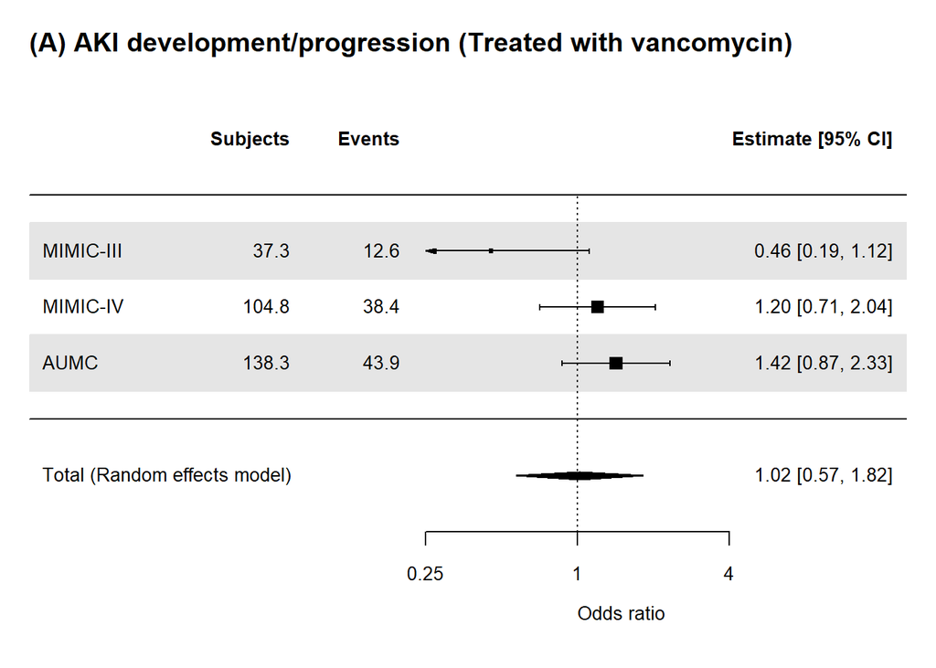

```r
#Forrestplot
FP2("wgt_man_Ovlp_MIMIC3_vc.rds", FORMULA_ovl2_vc)
FP2("wgt_man_Ovlp_MIMIC4_vc.rds", FORMULA_ovl2_vc)
FP2("wgt_man_Ovlp_AUMC_vc.rds", FORMULA_ovl2_vc)

vc_METADF0 <- rbind(
  readRDS("ORRES_wgt_man_Ovlp_MIMIC3_vc.rds") %>% mutate("dataset"="MIMIC-III"),
  readRDS("ORRES_wgt_man_Ovlp_MIMIC4_vc.rds") %>% mutate("dataset"="MIMIC-IV"),
  readRDS("ORRES_wgt_man_Ovlp_AUMC_vc.rds") %>% mutate("dataset"="AUMC"))
vc_METADF_AKID <- vc_METADF0 %>% subset(outcome=="outcome_KDIGO_inc_or_death")
vc_METADF_AKI <- vc_METADF0 %>% subset(outcome=="outcome_KDIGO_inc")
vc_METADF_HD <- vc_METADF0 %>% subset(outcome=="outcome_new_dial")
vc_METADF_D <- vc_METADF0 %>% subset(outcome=="death_in_7d")
vc_METADF_HDD <- vc_METADF0 %>% subset(outcome=="outcome_HDD_in7d")
vc_METARES_AKID <- rma(yi = Estimate, sei = Std.Error, method = "REML", data = vc_METADF_AKID)
vc_METARES_AKI<-rma(yi = Estimate, sei = Std.Error, method = "REML", data = vc_METADF_AKI)
vc_METARES_HD<-rma(yi = Estimate, sei = Std.Error, method = "REML", data = vc_METADF_HD)
vc_METARES_D<-rma(yi = Estimate, sei = Std.Error, method = "REML", data = vc_METADF_D)
vc_METARES_HDD<-rma(yi = Estimate, sei = Std.Error, method = "REML", data = vc_METADF_HDD)

METAF(vc_METARES_AKI, SCALEA1, SCALEB1, SCALEC1, "(A) AKI development/progression (Treated with vancomycin)")
```

```r
vc_METARES_AKI
```

```
##
## Random-Effects Model (k = 3; tau^2 estimator: REML)
##
## tau^2 (estimated amount of total heterogeneity): 0.1596 (SE = 0.2628)
## tau (square root of estimated tau^2 value):      0.3994
## I^2 (total heterogeneity / total variability):   62.47%
## H^2 (total variability / sampling variability):  2.66
##
## Test for Heterogeneity:
## Q(df = 2) = 4.8372, p-val = 0.0890
##
## Model Results:
##
## estimate      se    zval    pval    ci.lb   ci.ub
##   0.0205  0.2949  0.0696  0.9445  -0.5574  0.5985
##
## ---
## Signif. codes:  0 '***' 0.001 '**' 0.01 '*' 0.05 '.' 0.1 ' ' 1
```

```r
vc_METADF_AKI %>% dplyr::select(dataset, OR, LCI, UCI, 'Pr(>|z|)') %>% remove_rownames()
```

```
##     dataset        OR       LCI      UCI   Pr(>|z|)
## 1 MIMIC-III 0.4551234 0.1856772 1.115578 0.08527535
## 2  MIMIC-IV 1.2019783 0.7083342 2.039647 0.49532846
## 3      AUMC 1.4218543 0.8681332 2.328755 0.16205306
```

__

__

#### 7d. Backgrounds, outcomes, matching quality, and forest plot among those **no_vancomycin**

```r
#1. overlap-PSM using MIMIC3, Older
OVLP(comb_DF2ovl %>% subset(dataset=="MIMIC3"&treat_van==F), FORMULA_ovl2_vc, "Ovlp_MIMIC3_novc", "**Ovlp, MIMIC-III, No_vancomycin**")
```

| **Characteristic** | **Ovlp, MIMIC-III, No_vancomycin** **I/C** N=40.1<sup>1</sup> | **Ovlp, MIMIC-III, No_vancomycin** **NCC** N=40.1<sup>1</sup> | **p-value**<sup>2</sup> |  |
| --- | --- | --- | --- | --- |
| dataset |  |  |  |  |
| MIMIC3 | 40.1 (100.0%) | 40.1 (100.0%) |  |  |
| age_group |  |  | 0.97 |  |
| 18-39 | 2.4 (6.0%) | 3.3 (8.3%) |  |  |
| 40-49 | 4.6 (11.5%) | 3.7 (9.2%) |  |  |
| 50-59 | 6.2 (15.4%) | 6.7 (16.6%) |  |  |
| 60-69 | 9.2 (23.1%) | 7.8 (19.3%) |  |  |
| 70-79 | 11.3 (28.2%) | 11.4 (28.5%) |  |  |
| 80+ | 6.4 (15.9%) | 7.3 (18.1%) |  |  |
| sex |  |  | >0.99 |  |
| Female | 19.3 (48.2%) | 19.3 (48.2%) |  |  |
| Male | 20.8 (51.8%) | 20.8 (51.8%) |  |  |
| bmi | 26.3 (24.5, 31.6) | 27.8 (23.6, 35.3) | 0.91 |  |
| Unknown | 16 | 21 |  |  |
| ICU type |  |  | >0.99 |  |
| Non-surgery | 23.1 (57.6%) | 23.1 (57.6%) |  |  |
| Surgery | 17.0 (42.4%) | 17.0 (42.4%) |  |  |
| drug_name |  |  |  |  |
| Imipenem/cilastatin | 40.1 (100.0%) | 0.0 (0.0%) |  |  |
| Imipenem/cilastatin/relebactam | 0.0 (0.0%) | 0.0 (0.0%) |  |  |
| Meropenem | 0.0 (0.0%) | 40.1 (100.0%) |  |  |
| Doripenem | 0.0 (0.0%) | 0.0 (0.0%) |  |  |
| Ertapenem | 0.0 (0.0%) | 0.0 (0.0%) |  |  |
| sofa | 4.0 (3.0, 6.0) | 4.0 (2.0, 7.0) | 0.57 |  |
| qsofa | 1.0 (0.0, 1.0) | 1.0 (0.0, 1.0) | 0.81 |  |
| Unknown | 0 | 1 |  |  |
| sirs | 2.0 (1.0, 3.0) | 2.0 (1.0, 3.0) | 0.93 |  |
| pre_blood_culture | 31.2 (77.8%) | 31.2 (77.8%) | >0.99 |  |
| pre vancomycin use | 0.0 (0.0%) | 0.0 (0.0%) |  |  |
| pre vasopressor use | 14.4 (35.9%) | 14.4 (35.9%) | >0.99 |  |
| pre ventilation | 27.6 (68.8%) | 27.0 (67.4%) | 0.85 |  |
| Baseline sCr | 0.8 (0.5, 1.4) | 0.9 (0.6, 1.3) | 0.74 |  |
| sCr at treatment start | 1.1 (0.7, 1.7) | 1.0 (0.7, 1.5) | 0.98 |  |
| AKI stage at treatment start |  |  | 0.87 |  |
| 0 | 29.8 (74.3%) | 29.3 (73.2%) |  |  |
| 1 | 8.9 (22.3%) | 9.8 (24.5%) |  |  |
| 2 | 1.4 (3.5%) | 1.0 (2.4%) |  |  |
| observation time | 168.0 (166.5, 168.0) | 168.0 (168.0, 168.0) | 0.52 |  |
| Cencsored with drug change | 1.6 (3.9%) | 0.2 (0.4%) | 0.025 |  |
| RRT at treatment start | 0.0 (0.0%) | 0.0 (0.0%) |  |  |
| O, AKI develop/progress | 9.9 (24.7%) | 15.8 (39.3%) | 0.057 |  |
| O, Death | 5.8 (14.6%) | 5.1 (12.8%) | 0.73 |  |
| O, AKI d/p or death | 12.8 (32.0%) | 17.7 (44.1%) | 0.12 |  |
| O, RRT-intervention | 1.6 (3.9%) | 1.6 (4.0%) | 0.98 |  |
| O, Death or RRT-intervention | 6.7 (16.7%) | 6.7 (16.7%) | >0.99 |  |

<sup>1</sup> n (%); Median (Q1, Q3)  
<sup>2</sup> NA; Pearson’s X^2: Rao & Scott adjustment; Design-based KruskalWallis test

```r
#2. overlap-PSM using MIMIC4, Older
OVLP(comb_DF2ovl %>% subset(dataset=="miiv"&treat_van==F), FORMULA_ovl2_vc, "Ovlp_MIMIC4_novc", "**Ovlp, MIMIC-IV, No_vancomycin**")
```

| **Characteristic** | **Ovlp, MIMIC-IV, No_vancomycin** **I/C** N=32.6<sup>1</sup> | **Ovlp, MIMIC-IV, No_vancomycin** **NCC** N=32.6<sup>1</sup> | **p-value**<sup>2</sup> |  |
| --- | --- | --- | --- | --- |
| dataset |  |  |  |  |
| miiv | 32.6 (100.0%) | 32.6 (100.0%) |  |  |
| age_group |  |  | 0.57 |  |
| 18-39 | 1.9 (6.0%) | 2.4 (7.3%) |  |  |
| 40-49 | 4.8 (14.9%) | 2.5 (7.7%) |  |  |
| 50-59 | 2.9 (8.9%) | 5.5 (16.7%) |  |  |
| 60-69 | 9.6 (29.4%) | 8.5 (26.0%) |  |  |
| 70-79 | 5.7 (17.4%) | 7.3 (22.5%) |  |  |
| 80+ | 7.6 (23.4%) | 6.5 (19.9%) |  |  |
| sex |  |  | >0.99 |  |
| Female | 16.2 (49.7%) | 16.2 (49.7%) |  |  |
| Male | 16.4 (50.3%) | 16.4 (50.3%) |  |  |
| bmi | 28.6 (25.3, 30.0) | 27.3 (23.0, 32.5) | 0.60 |  |
| Unknown | 13 | 12 |  |  |
| ICU type |  |  | >0.99 |  |
| Non-surgery | 27.7 (85.0%) | 27.7 (85.0%) |  |  |
| Surgery | 4.9 (15.0%) | 4.9 (15.0%) |  |  |
| drug_name |  |  |  |  |
| Imipenem/cilastatin | 32.6 (100.0%) | 0.0 (0.0%) |  |  |
| Imipenem/cilastatin/relebactam | 0.0 (0.0%) | 0.0 (0.0%) |  |  |
| Meropenem | 0.0 (0.0%) | 32.2 (99.0%) |  |  |
| Doripenem | 0.0 (0.0%) | 0.1 (0.3%) |  |  |
| Ertapenem | 0.0 (0.0%) | 0.2 (0.7%) |  |  |
| sofa | 4.0 (2.0, 8.0) | 5.0 (3.0, 7.0) | 0.56 |  |
| qsofa | 1.0 (0.0, 1.0) | 1.0 (0.0, 1.0) | 0.67 |  |
| Unknown | 0 | 0 |  |  |
| sirs | 2.0 (1.0, 3.0) | 2.0 (1.0, 3.0) | 0.96 |  |
| pre_blood_culture | 24.8 (76.3%) | 24.8 (76.3%) | >0.99 |  |
| pre vancomycin use | 0.0 (0.0%) | 0.0 (0.0%) |  |  |
| pre vasopressor use | 2.8 (8.7%) | 2.8 (8.7%) | >0.99 |  |
| pre ventilation | 3.8 (11.7%) | 3.1 (9.4%) | 0.66 |  |
| Baseline sCr | 1.0 (0.5, 1.4) | 0.8 (0.6, 1.2) | 0.86 |  |
| sCr at treatment start | 1.0 (0.6, 1.6) | 1.0 (0.6, 1.5) | 0.99 |  |
| AKI stage at treatment start |  |  | 0.42 |  |
| 0 | 25.8 (79.1%) | 24.6 (75.5%) |  |  |
| 1 | 3.9 (11.9%) | 6.2 (19.1%) |  |  |
| 2 | 2.9 (9.0%) | 1.8 (5.4%) |  |  |
| observation time | 168.0 (147.0, 168.0) | 168.0 (131.8, 168.0) | 0.44 |  |
| Unknown | 2 | 3 |  |  |
| Cencsored with drug change | 0.9 (2.9%) | 0.0 (0.0%) | 0.31 |  |
| RRT at treatment start | 0.0 (0.0%) | 0.0 (0.0%) |  |  |
| O, AKI develop/progress | 10.4 (32.1%) | 8.9 (27.2%) | 0.53 |  |
| O, Death | 3.8 (11.7%) | 4.4 (13.4%) | 0.77 |  |
| O, AKI d/p or death | 10.4 (32.1%) | 11.0 (33.8%) | 0.83 |  |
| O, RRT-intervention | 1.0 (3.0%) | 1.3 (3.9%) | 0.78 |  |
| O, Death or RRT-intervention | 3.8 (11.7%) | 5.3 (16.3%) | 0.47 |  |

<sup>1</sup> n (%); Median (Q1, Q3)  
<sup>2</sup> NA; Pearson’s X^2: Rao & Scott adjustment; Design-based KruskalWallis test

```r
#3. overlap-PSM using AUMC, Older
OVLP(comb_DF2ovl %>% subset(dataset=="AUMC"&treat_van==F), FORMULA_ovl2_vc, "Ovlp_AUMC_novc", "**Ovlp, AUMC, No_vancomycin**")
```

| **Characteristic** | **Ovlp, AUMC, No_vancomycin** **I/C** N=71.4<sup>1</sup> | **Ovlp, AUMC, No_vancomycin** **NCC** N=71.4<sup>1</sup> | **p-value**<sup>2</sup> |  |
| --- | --- | --- | --- | --- |
| dataset |  |  |  |  |
| AUMC | 71.4 (100.0%) | 71.4 (100.0%) |  |  |
| age_group |  |  | 0.36 |  |
| 18-39 | 9.5 (13.3%) | 11.6 (16.2%) |  |  |
| 40-49 | 5.4 (7.5%) | 7.2 (10.1%) |  |  |
| 50-59 | 15.9 (22.3%) | 10.6 (14.9%) |  |  |
| 60-69 | 23.0 (32.2%) | 19.0 (26.5%) |  |  |
| 70-79 | 13.6 (19.0%) | 18.6 (26.1%) |  |  |
| 80+ | 4.1 (5.8%) | 4.5 (6.2%) |  |  |
| sex |  |  | >0.99 |  |
| Female | 29.1 (40.7%) | 29.1 (40.7%) |  |  |
| Male | 42.4 (59.3%) | 42.4 (59.3%) |  |  |
| bmi | 24.5 (21.3, 27.5) | 24.5 (21.9, 27.8) | 0.14 |  |
| Unknown | 5 | 2 |  |  |
| ICU type |  |  | >0.99 |  |
| Non-surgery | 46.1 (64.5%) | 46.1 (64.5%) |  |  |
| Surgery | 25.4 (35.5%) | 25.4 (35.5%) |  |  |
| drug_name |  |  |  |  |
| Imipenem/cilastatin | 71.4 (100.0%) | 0.0 (0.0%) |  |  |
| Imipenem/cilastatin/relebactam | 0.0 (0.0%) | 0.0 (0.0%) |  |  |
| Meropenem | 0.0 (0.0%) | 71.4 (100.0%) |  |  |
| Doripenem | 0.0 (0.0%) | 0.0 (0.0%) |  |  |
| Ertapenem | 0.0 (0.0%) | 0.0 (0.0%) |  |  |
| sofa | 7.0 (5.0, 9.0) | 7.0 (4.0, 10.0) | 0.93 |  |
| Unknown | 11 | 12 |  |  |
| qsofa | 1.0 (0.0, 1.0) | 1.0 (0.0, 1.0) | 0.49 |  |
| Unknown | 0 | 0 |  |  |
| sirs | 2.0 (2.0, 3.0) | 2.0 (1.0, 3.0) | 0.91 |  |
| pre_blood_culture | 10.7 (15.0%) | 10.7 (15.0%) | >0.99 |  |
| pre vancomycin use | 0.0 (0.0%) | 0.0 (0.0%) |  |  |
| pre vasopressor use | 44.1 (61.7%) | 44.1 (61.7%) | >0.99 |  |
| pre ventilation | 44.1 (61.7%) | 42.0 (58.7%) | 0.61 |  |
| Baseline sCr | 0.9 (0.6, 1.3) | 0.8 (0.6, 1.2) | 0.35 |  |
| sCr at treatment start | 1.1 (0.7, 1.6) | 1.0 (0.7, 1.7) | 0.48 |  |
| AKI stage at treatment start |  |  | 0.62 |  |
| 0 | 51.8 (72.6%) | 53.1 (74.4%) |  |  |
| 1 | 16.6 (23.3%) | 14.0 (19.6%) |  |  |
| 2 | 3.0 (4.2%) | 4.3 (6.0%) |  |  |
| observation time | 101.9 (39.8, 168.0) | 133.2 (45.5, 168.0) | 0.54 |  |
| Cencsored with drug change | 1.9 (2.7%) | 1.4 (1.9%) | 0.68 |  |
| RRT at treatment start | 0.0 (0.0%) | 0.0 (0.0%) |  |  |
| O, AKI develop/progress | 18.3 (25.7%) | 21.1 (29.6%) | 0.46 |  |
| O, Death | 11.2 (15.7%) | 11.3 (15.9%) | 0.96 |  |
| O, AKI d/p or death | 22.1 (31.0%) | 27.2 (38.1%) | 0.20 |  |
| O, RRT-intervention | 5.9 (8.3%) | 8.0 (11.1%) | 0.41 |  |
| O, Death or RRT-intervention | 13.9 (19.4%) | 16.6 (23.3%) | 0.42 |  |

<sup>1</sup> n (%); Median (Q1, Q3)  
<sup>2</sup> NA; Pearson’s X^2: Rao & Scott adjustment; Design-based KruskalWallis test

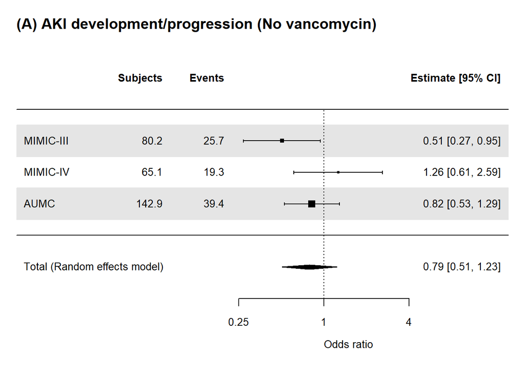

```r
FP2("wgt_man_Ovlp_MIMIC4_novc.rds", FORMULA_ovl2_vc)
FP2("wgt_man_Ovlp_MIMIC3_novc.rds", FORMULA_ovl2_vc)
FP2("wgt_man_Ovlp_AUMC_novc.rds", FORMULA_ovl2_vc)

novc_METADF0 <- rbind(
  readRDS("ORRES_wgt_man_Ovlp_MIMIC3_novc.rds") %>% mutate("dataset"="MIMIC-III"),
  readRDS("ORRES_wgt_man_Ovlp_MIMIC4_novc.rds") %>% mutate("dataset"="MIMIC-IV"),
  readRDS("ORRES_wgt_man_Ovlp_AUMC_novc.rds") %>% mutate("dataset"="AUMC"))
novc_METADF_AKID <- novc_METADF0 %>% subset(outcome=="outcome_KDIGO_inc_or_death")
novc_METADF_AKI <- novc_METADF0 %>% subset(outcome=="outcome_KDIGO_inc")
novc_METADF_HD <- novc_METADF0 %>% subset(outcome=="outcome_new_dial")
novc_METADF_D <- novc_METADF0 %>% subset(outcome=="death_in_7d")
novc_METADF_HDD <- novc_METADF0 %>% subset(outcome=="outcome_HDD_in7d")

novc_METARES_AKID <- rma(yi = Estimate, sei = Std.Error, method = "REML", data = novc_METADF_AKID)
novc_METARES_AKI <-rma(yi = Estimate, sei = Std.Error, method = "REML", data = novc_METADF_AKI)
novc_METARES_HD <- rma(yi = Estimate, sei = Std.Error, method = "REML", data = novc_METADF_HD)
novc_METARES_D <- rma(yi = Estimate, sei = Std.Error, method = "REML", data = novc_METADF_D)
novc_METARES_HDD <- rma(yi = Estimate, sei = Std.Error, method = "REML", data = novc_METADF_HDD)

METAF(novc_METARES_AKI, SCALEA1, SCALEB1, SCALEC1, "(A) AKI development/progression (No vancomycin)")
```

```r
novc_METARES_AKI
```

```
##
## Random-Effects Model (k = 3; tau^2 estimator: REML)
##
## tau^2 (estimated amount of total heterogeneity): 0.0662 (SE = 0.1573)
## tau (square root of estimated tau^2 value):      0.2573
## I^2 (total heterogeneity / total variability):   42.30%
## H^2 (total variability / sampling variability):  1.73
##
## Test for Heterogeneity:
## Q(df = 2) = 3.6078, p-val = 0.1647
##
## Model Results:
##
## estimate      se     zval    pval    ci.lb   ci.ub
##  -0.2344  0.2273  -1.0314  0.3023  -0.6799  0.2110
##
## ---
## Signif. codes:  0 '***' 0.001 '**' 0.01 '*' 0.05 '.' 0.1 ' ' 1
```

```r
novc_METADF_AKI %>% dplyr::select(dataset, OR, LCI, UCI, 'Pr(>|z|)') %>% remove_rownames()
```

```
##     dataset        OR       LCI       UCI   Pr(>|z|)
## 1 MIMIC-III 0.5064143 0.2711181 0.9459178 0.03281195
## 2  MIMIC-IV 1.2626754 0.6147847 2.5933459 0.52533030
## 3      AUMC 0.8227345 0.5252681 1.2886600 0.39406795
```

__